# Preliminary Analysis

```r
dropbox_dir <- "~/Dropbox/"
```

# Preprocess for Analysis RCT ——————–

## Read data and merge

```r
car <- read.csv(paste(dropbox_dir, "/Mistakes/Code/Python/Cartillas/data/2022/carreras_v2.csv", sep=''), header=TRUE, sep=";")

dm_int <- read.csv(file = paste(dropbox_dir, "Mistakes/Code/Python/Cartillas/outputs/2022/preprocessing_rct_interim.csv", sep=""), header=TRUE, sep=";")
dm_fin <- read.csv(file = paste(dropbox_dir, "Mistakes/Code/Python/Cartillas/outputs/2022/preprocessing_rct_finales.csv", sep=""), header=TRUE, sep=";")
scores <- read.csv(file = paste(dropbox_dir, "Mistakes/Code/Python/Cartillas/data/2022/puntajes_consolidado_v3.csv", sep=""), header=TRUE, sep=",")

colnames(dm_int)[2:length(colnames(dm_int))] <- paste(colnames(dm_int)[2:length(colnames(dm_int))], '_int', sep='')
colnames(dm_fin)[2:length(colnames(dm_fin))] <- paste(colnames(dm_fin)[2:length(colnames(dm_int))], '_fin', sep='')
```

```r
dm <- merge(dm_int, dm_fin, by="mrun")
```

```r
dm %<>% mutate(apps_before = (codigo_carrera_1_int > 0) + (codigo_carrera_2_int > 0) +
                             (codigo_carrera_3_int > 0) + (codigo_carrera_4_int > 0) +
                             (codigo_carrera_5_int > 0) + (codigo_carrera_6_int > 0) +
                             (codigo_carrera_7_int > 0) + (codigo_carrera_8_int > 0) +
                             (codigo_carrera_9_int > 0) + (codigo_carrera_10_int > 0),
              valid_apps_before = (marca_1_int == 25) + (marca_2_int == 25) +
                                  (marca_3_int == 25) + (marca_4_int == 25) +
                                  (marca_5_int == 25) + (marca_6_int == 25) +
                                  (marca_7_int == 25) + (marca_8_int == 25) +
                                  (marca_9_int == 25) + (marca_10_int == 25) ,
               apps_after = (codigo_carrera_1_fin > 0) + (codigo_carrera_2_fin > 0) +
                             (codigo_carrera_3_fin > 0) + (codigo_carrera_4_fin > 0) +
                             (codigo_carrera_5_fin > 0) + (codigo_carrera_6_fin > 0) +
                             (codigo_carrera_7_fin > 0) + (codigo_carrera_8_fin > 0) +
                             (codigo_carrera_9_fin > 0) + (codigo_carrera_10_fin > 0),
              valid_apps_after = (marca_1_fin == 25) + (marca_2_fin == 25) +
                                  (marca_3_fin == 25) + (marca_4_fin == 25) +
                                  (marca_5_fin == 25) + (marca_6_fin == 25) +
                                  (marca_7_fin == 25) + (marca_8_fin == 25) +
                                  (marca_9_fin == 25) + (marca_10_fin == 25) ,
              changed_apps = (codigo_carrera_1_int != codigo_carrera_1_fin) + (codigo_carrera_2_int != codigo_carrera_2_fin) +
                             (codigo_carrera_3_int != codigo_carrera_3_fin) + (codigo_carrera_4_int != codigo_carrera_4_fin) +
                             (codigo_carrera_5_int != codigo_carrera_5_fin) + (codigo_carrera_6_int != codigo_carrera_6_fin) +
                             (codigo_carrera_7_int != codigo_carrera_7_fin) + (codigo_carrera_8_int != codigo_carrera_8_fin) +
                             (codigo_carrera_9_int != codigo_carrera_9_fin) + (codigo_carrera_10_int != codigo_carrera_10_fin)
            )
```

```r
of <- read.csv(paste(dropbox_dir, "Mistakes/Code/Python/Cartillas/data/2022/seleccion_20_01_22.csv", sep=''))
open <- read.csv(paste(dropbox_dir, "Mistakes/Code/Python/Cartillas/data/2022/accesos-cartilla-postulaciones.csv", sep=''))
pumi <- read.csv(paste(dropbox_dir, "Mistakes/Code/Python/Cartillas/data/2022/accesos-cartilla-puntajes.csv", sep=''))
pumi %<>% dplyr::rename(MRUN = id, pumi = ingreso)
ms <- read.csv(paste(dropbox_dir, "Mistakes/Code/Python/Cartillas/outputs/2022/master_students_with_treatment_and_stratas.csv", sep=''), header=TRUE, sep=',')
#TODO: we need to check how the probability variables that are in the object ms were computed and if we have to just drop them now
ms %<>% select(!(starts_with("prob") | starts_with("overall")))

op <- open %>% group_by(distinct_id) %>% dplyr::summarise(t_open = min(time)) %>% mutate(open = 1) %>% dplyr::rename(MRUN = distinct_id)
df <- merge(ms, of, by.x="MRUN", by.y="mrun", all.x=TRUE)
df <- merge(df, dm, by.x="MRUN", by.y="mrun", all.x=TRUE)

df <- merge(df, op, by="MRUN", all.x=TRUE)
df$open[is.na(df$open)] <- 0

df <- merge(df, pumi, by="MRUN", all.x=TRUE)
df$pumi[is.na(df$pumi)] <- 0
```

```r
df %<>% mutate(assigned_oficial = ifelse((estado_pref_01 %in% c(24, 26)) + (estado_pref_02 %in% c(24, 26)) +
                          (estado_pref_03 %in% c(24, 26)) + (estado_pref_04 %in% c(24, 26)) +
                          (estado_pref_05 %in% c(24, 26)) + (estado_pref_06 %in% c(24, 26)) +
                          (estado_pref_07 %in% c(24, 26)) + (estado_pref_08 %in% c(24, 26)) +
                          (estado_pref_09 %in% c(24, 26)) + (estado_pref_10 %in% c(24, 26)) > 0, 1, 0))

df %<>% mutate(changed = ifelse(changed_apps > 0, 1, 0),
               increased = ifelse(apps_after > apps_before, 1, 0),
               decreased = ifelse(apps_after < apps_before, 1, 0))

df %<>% mutate(reduced_mistakes = ifelse(changed == 1 & valid_apps_before < valid_apps_after, 1, 0))

df %<>% mutate(increased_valid = ifelse(valid_apps_after > valid_apps_before, 1, 0),
               decreased_valid = ifelse(valid_apps_after < valid_apps_before, 1, 0))
```

## Preprocessing programs

```r
of <- read.csv(paste(dropbox_dir, "Mistakes/Code/Python/Cartillas/data/2022/seleccion_20_01_22.csv", sep=''))
car <- read.csv(paste(dropbox_dir, "/Mistakes/Code/Python/Cartillas/data/2022/carreras_v2.csv", sep=''), header=TRUE, sep=";")

of_l <- reshape(of[,c(1,4:53)], direction='long',
                    varying=colnames(of[,4:53]),
                    times=c('01', '02', '03', '04', '05', '06', '07', '08', '09', '10'),
                    v.names=c('cod_carrera_pref', 'estado_pref','ptje_pref', 'lugar_pref', 'pond_acad_pref'),
                    idvar='mrun')
colnames(of_l) <- c("mrun", "pref", "codigo_carrera", "marca", "orden", "puntano", "puntpond") # this is just me not knowing how to use reshape
# I can tell! JAJAJAJAJA

cutoffs <- of_l %>% filter(marca == 24) %>% group_by(codigo_carrera) %>% dplyr::summarise(num_admitted = n(), min_score = pmax(min(puntpond), 210.0))
#TODO: this is not taking into account that many programs do not fill their vacancies. We
# can assign max(min_pond, 210) for those that do not fill VACANTES_REG
car %<>% mutate(VACANTES_REG = VACANTES_1_SEMESTRE + VACANTES_2_SEMESTRE + SOBRECUPO_1_SEMESTRE + SOBRECUPO_2_SEMESTRE)
car <- merge(car, cutoffs, by.x="CODIGO_DEMRE", by.y="codigo_carrera", all.x=TRUE)
```

## Consolidate interim and final assignment

```r
reg_int <- read.csv(paste(dropbox_dir,"Mistakes/Code/Python/Cartillas/outputs/2022/asignacion_obtenida_reg_interim_completando_con_finales.csv", sep=''), header=TRUE, sep=';')
bea_int <- read.csv(paste(dropbox_dir,"Mistakes/Code/Python/Cartillas/outputs/2022/asignacion_obtenida_bea_interim_completando_con_finales.csv", sep=''), header=TRUE, sep=';')
pace_int <- read.csv(paste(dropbox_dir,"Mistakes/Code/Python/Cartillas/outputs/2022/asignacion_obtenida_pace_interim_completando_con_finales.csv", sep=''), header=TRUE, sep=';')

reg_fin <- read.csv(paste(dropbox_dir,"Mistakes/Code/Python/Cartillas/outputs/2022/asignacion_obtenida_reg_finales.csv", sep=''), header=TRUE, sep=';')
bea_fin <- read.csv(paste(dropbox_dir,"Mistakes/Code/Python/Cartillas/outputs/2022/asignacion_obtenida_bea_finales.csv", sep=''), header=TRUE, sep=';')
pace_fin <- read.csv(paste(dropbox_dir,"Mistakes/Code/Python/Cartillas/outputs/2022/asignacion_obtenida_pace_finales.csv", sep=''), header=TRUE, sep=';')
```

```r
pace_int_a <- pace_int %>% filter(marca == 24)
bea_int_a  <- bea_int %>% filter(marca == 24 & !(id_alumno %in% pace_int_a$id_alumno))
ass_int <- rbind(pace_int_a, bea_int_a)
ass_int <- rbind(ass_int, reg_int %>% filter(marca == 24 & !(id_alumno %in% ass_int$id_alumno) ))

pace_fin_a <- pace_fin %>% filter(marca == 24)
bea_fin_a  <- bea_fin %>% filter(marca == 24 & !(id_alumno %in% pace_fin_a$id_alumno))
ass_fin <- rbind(pace_fin_a, bea_fin_a)
ass_fin <- rbind(ass_fin, reg_fin %>% filter(marca == 24 & !(id_alumno %in% ass_fin$id_alumno) ))
```

```r
ass_int$assigned <- 1
ass_fin$assigned <- 1

rm(pace_int_a, bea_int_a, pace_fin_a, bea_fin_a)
```

```r
ass <- merge(ass_int %>% dplyr::select(id_alumno, codigo_carrera, pref, assigned) %>% dplyr::rename(codigo_carrera_assigned_int = codigo_carrera, pref_assigned_int = pref, assigned_int = assigned),
            ass_fin %>% dplyr::select(id_alumno, codigo_carrera, pref, assigned) %>% dplyr::rename(codigo_carrera_assigned_fin = codigo_carrera, pref_assigned_fin = pref, assigned_fin = assigned), by="id_alumno", all=TRUE)
```

```r
ass <- merge(ass, reg_int %>% dplyr::select(id_alumno, codigo_carrera, pref) %>% dplyr::rename(pref_assigned_fin_at_int = pref), by.x=c("id_alumno", "codigo_carrera_assigned_fin"), by.y=c("id_alumno", "codigo_carrera"), all.x=TRUE)
```

## Merge sources of data

```r
df <- merge(df, ass, by.x="MRUN", by.y="id_alumno", all.x=TRUE)
```

```r
df$assigned_oficial[is.na(df$assigned_oficial)] <- 0
df$assigned_int[is.na(df$assigned_int)] <- 0
df$assigned_fin[is.na(df$assigned_fin)] <- 0

df$codigo_carrera_assigned_int[is.na(df$codigo_carrera_assigned_int)] <- 0
df$codigo_carrera_assigned_fin[is.na(df$codigo_carrera_assigned_fin)] <- 0

df %<>% mutate(entered = ifelse(assigned_int == 0 & assigned_fin == 1, 1, 0),
               left = ifelse(assigned_int == 1 & assigned_fin == 0, 1, 0),
               changed_status_ass = ifelse(assigned_int != assigned_fin, 1, 0),
               changed_program_ass = ifelse(changed_status_ass == 0 & assigned_int == 1 &
                                             codigo_carrera_assigned_int != codigo_carrera_assigned_fin, 1, 0) )
```

```r
df$increased[is.na(df$increased)] <- 0
df$decreased[is.na(df$decreased)] <- 0

df$increased_valid[is.na(df$increased_valid)] <- 0
df$decreased_valid[is.na(df$decreased_valid)] <- 0
df$changed[is.na(df$changed)] <- 0
```

```r
saveRDS(df, paste(dropbox_dir,"Mistakes/Code/Python/Cartillas/outputs/2022/master_file_for_analysis_of_rct.csv", sep=''))
```

## Pre-processing of survey

```r
survey_mapping <- read.csv(paste(dropbox_dir,"Mistakes/Code/Python/Cartillas/outputs/2022/survey/encuesta.csv", sep=''))
```

```r
survey_answers <- read_excel(paste(dropbox_dir,"Mistakes_in_college_admissions/data/processed/implementation/survey-2022/survey answers/ans_surveymistakes.xlsx", sep=''))
```

```r
survey <- merge(survey_answers, survey_mapping, by.x="hash", by.y="llavespub")
```

```r
survey %<>% dplyr::select(mrun, QID8_11, QID131_11, QID12_2, QID95_1,
                          QID87_1, QID87_2, QID87_3, QID87_4, QID87_5, QID87_7, QID87_8, QID87_9, QID87_8_TEXT,
                          QID124, QID123_2, QID132_1,
                          QID125_1, QID125_2, QID125_3, QID125_4, QID125_5, QID125_6, QID125_7, QID125_7_TEXT,
                          QID161_1, QID162_1,
                          QID136_1, QID136_2, QID136_11, QID136_10,
                          QID137_1, QID137_2, QID137_11, QID137_10,
                          QID138_1, QID138_2, QID138_11, QID138_10,
                          QID25, QID26, QID26_4_TEXT,
                          QID27_1, QID27_2, QID27_5, QID27_6, QID27_5_TEXT,
                          QID150_2)
```

```r
survey %<>% dplyr::rename(prob_top_pref = QID8_11, prob_any_pref = QID131_11, codigo_carrera_top_true = QID12_2, puntpond_top_true = QID95_1,
                          bottom_true_any = QID124, codigo_carrera_bottom_true = QID123_2, puntpond_bottom_true = QID132_1,
                          puntpond_top_reported = QID161_1, puntpond_bottom_reported = QID162_1,
                          cutoff_prev_top_reported = QID136_1, cutoff_prev_bottom_reported = QID136_2, cutoff_prev_top_true = QID136_11, cutoff_prev_bottom_true = QID136_10,
                          cutoff_top_reported = QID137_1, cutoff_bottom_reported = QID137_2, cutoff_top_true = QID137_11, cutoff_bottom_true = QID137_10,
                          prob_top_reported = QID138_1, prob_bottom_reported = QID138_2, prob_top_true = QID138_11, prob_bottom_true = QID138_10,
                          knows_adm_mistake = QID25, reason_mistake = QID26,
                          single_choice = QID150_2)
```

```r
survey$codigo_carrera_top_true <- as.numeric(gsub("\\D", "", survey$codigo_carrera_top_true))
survey$codigo_carrera_bottom_true <- as.numeric(gsub("\\D", "", survey$codigo_carrera_bottom_true))
survey$codigo_carrera_single_choice <- as.numeric(gsub("\\D", "", survey$single_choice))
```

```r
survey %<>% mutate(bottom_true_any = ifelse(bottom_true_any == "Sí", 1, ifelse(bottom_true_any == "No", 0, bottom_true_any)))

survey %<>% mutate(reason_skip_top_true = ifelse(!is.na(QID87_1), QID87_1,
                                                 ifelse(!is.na(QID87_2), QID87_2,
                                                        ifelse(!is.na(QID87_3), QID87_3,
                                                               ifelse(!is.na(QID87_4), QID87_4,
                                                                      ifelse(!is.na(QID87_5), QID87_5,
                                                                             ifelse(!is.na(QID87_7), QID87_7,
                                                                                    ifelse(!is.na(QID87_9), QID87_9,
                                                                                           ifelse(!is.na(QID87_8), QID87_8_TEXT, NA ) ) ) ) ) ))))

survey %<>% mutate(reason_skip_bottom_true = ifelse(!is.na(QID125_1), QID125_1,
                                                    ifelse(!is.na(QID125_2), QID125_2,
                                                           ifelse(!is.na(QID125_3), QID125_3,
                                                                  ifelse(!is.na(QID125_4), QID125_4,
                                                                         ifelse(!is.na(QID125_5), QID125_5,
                                                                                ifelse(!is.na(QID125_6), QID125_6,
                                                                                       ifelse(!is.na(QID125_7), QID125_7_TEXT, NA )) ) ) ) ) ) )

survey %<>% mutate(reason_uninformed_requisites = ifelse(!is.na(QID27_1), QID27_1,
                                                      ifelse(!is.na(QID27_2), QID27_2,
                                                             ifelse(!is.na(QID27_6), QID27_6,
                                                                    ifelse(!is.na(QID27_5), QID27_5_TEXT, NA ) ) ) ))

survey %<>% mutate(reason_mistake = ifelse(is.na(QID26_4_TEXT), reason_mistake,  QID26_4_TEXT) )
#TODO: In the script of survey 2021 we have some cleanings that have to be applied here
# regarding the definition of top-true preferences
#TODO: Ask the RA to double check that we are identifying the correct questions
# from the survey in the script and which questions have skips or missing values

#Defining inconsistent types depending of the reason they give to skip top-true programs or bottom-true programs







#TODO: FINISH THIS AND ADAPT IT TO BOTTOM TRUE

# Translate labels of reasons to English (not an exact translation)
# dfs_2021 %<>% mutate(reason_strategic_1 = ifelse(reason_strategic_1 == "Postulé a mi carrera ideal en mi primera preferencia.",
#                                                  "(a) I did apply to my ideal program as a top-reported preference", ""),
#                      reason_strategic_2 = ifelse(reason_strategic_2 == "La probabilidad de que quede seleccionado en esa carrera es muy baja.",
#                                                  "(b) My admission probability to that program is too low", ""),
#                      reason_strategic_3 = ifelse(reason_strategic_3 == "La carrera me parece demasiado difícil y no creo que vaya a terminarla en caso de matricularme.",
#                                                  "(c) The program is too hard and I don't think I would be able to graduate from it", ""),
#                      reason_strategic_4 = ifelse(reason_strategic_4 == "No tengo los recursos económicos para pagar el costo de la carrera.",
#                                                  "(d) I do not have the monetary resources to pay for the program", ""),
#                      reason_strategic_5 = ifelse(reason_strategic_5 == "Para incluir mi carrera ideal tendría que excluir alguna de las carreras de mi postulación.",
#                                                  "(e) To include my ideal program, I would have to exclude some program from my list", ""),
#                      reason_strategic_6 = ifelse(reason_strategic_6 == "La decisión de dónde postular no dependió completamente de mí, y fue influenciada por otras personas (familia, amigos u otros).",
#                                                  "(f) The decision to where to apply did not depend only on me, and it was influenced by other people (family, friends, etc.)", ""),
#                      reason_strategic_7 = ifelse(reason_strategic_7 == "Pensé que al incluir esta carrera en mi lista de preferencias habría reducido mis posibilidades de selección en las demás carreras.",
#                                                  "(g) I thought that by including this program in my list I would have reduced my chances of being admitted to the other listed programs", ""),
#                      reason_strategic_8 = ifelse(reason_strategic_8 == "Dado que mi probabilidad de selección es muy baja, prefiero no postular y quedar seleccionado en una preferencia reportada más alta.",
#                                                  "(h) Given that my admission chances are too low, I prefer to do not list this program and being assigned to a higher reported preference", ""))
#
# # Create variable to identify inconsistent answers to the survey
# dfs_2021 %<>% mutate(inconsistent_type = 0)
# dfs_2021 %<>% mutate(inconsistent_type = ifelse((((reason_strategic_1 == "") | (reason_strategic_3 != "") | (reason_strategic_4 != "")) & (truth_teller == 1)), 1, inconsistent_type))
# dfs_2021 %<>% mutate(inconsistent_type = ifelse(((reason_strategic_1 != "") | (reason_strategic_3 != "") | (reason_strategic_4 != "")) & (misreport_order == 1), 1, inconsistent_type))
# dfs_2021 %<>% mutate(inconsistent_type = ifelse(((reason_strategic_1 != "") | (reason_strategic_3 != "") | (reason_strategic_4 != "")) & (misreport_exclude == 1), 1, inconsistent_type))
#
```

QID8 <- prob assignment top pref QID131 <- prob assignment in any preference QID12_2 <- top true QID95_1 <- punt pond in top true QID87_1 to _8 <- reason for not including top true in ROL QID124 <- any other program outside ROL (bottom true) yes/no QID123_2 <- bottom_true QID132_1 <- score at bottom true QID125_1 to _TEXT <- reason for not including QID161_1 <- score in trop reported QID162_1 <- score in last reported QID136_1 <- cutoff last year top reported QID136_2 <- cutoff last year last reported QID136_3 <- cutoff last year top true QID136_4 <- cutoff last year bottom true QID137_1 <- cutoff top reported QID137_2 <- cutoff last reported QID137_3 <- cutoff top true QID137_4 <- cutoff bottom true QID138_1 <- prob top reported QID138_2 <- prob last reported QID138_3 <- prob top true QID138_4 <- prob bottom true QID25 <- knowledge about adm mistakes (yes/no) QID26 <- reason QID27_1 to_text <- if didn’t know the requisite, why QID150_2 <- single choice

```r
survey$responded_survey <- 1
```

```r
saveRDS(survey, paste(dropbox_dir,"Mistakes/Code/Python/Cartillas/outputs/2022/survey_processed.rds", sep=''))
write.csv(survey %>% dplyr::select(mrun, codigo_carrera_top_true, codigo_carrera_bottom_true), paste(dropbox_dir,"Mistakes/Code/Python/Cartillas/outputs/2022/top_and_bottom_true.csv", sep=''), sep=",", row.names=FALSE)
survey <- readRDS(paste(dropbox_dir,"Mistakes/Code/Python/Cartillas/outputs/2022/survey_processed.rds", sep=''))
tbp <- read.csv(paste(dropbox_dir,"Mistakes/Code/Python/Cartillas/outputs/2022/preprocessing_top_and_bottom_true.csv", sep=''))
#NOTE: the probabilities here might be outdated, so we will drop them and use the new clean data from Nacho
tbp %<>% select(!starts_with("prob"))

sur <- merge(survey, tbp %>% dplyr::select(-c(codigo_carrera_top_true, codigo_carrera_bottom_true)), by="mrun", all.x=TRUE)

sur %<>% dplyr::rename(puntpond_top_true_belief = puntpond_top_true.x, puntpond_top_true = puntpond_top_true.y,
                        puntpond_bottom_true_belief = puntpond_bottom_true.x, puntpond_bottom_true = puntpond_bottom_true.y)

sur %<>% mutate(puntpond_top_true = as.numeric(puntpond_top_true)/100,
                puntpond_bottom_true = as.numeric(puntpond_bottom_true)/100,
                puntpond_top_true_belief = as.numeric(puntpond_top_true_belief),
                puntpond_bottom_true_belief = as.numeric(puntpond_bottom_true_belief),
                diff_puntpond_top_true = puntpond_top_true - puntpond_top_true_belief,
                diff_puntpond_bottom_true = puntpond_bottom_true - puntpond_bottom_true_belief)
# Merge with the clean probs computed by Nacho

saveRDS(sur, paste(dropbox_dir,"Mistakes/Code/Python/Cartillas/outputs/2022/survey_processed_with_probs.rds", sep=''))
```

# Analysis of Survey ————————–

## Data

```r
#Read All probabilities with Ratex too (fixed)
probstrue <- read.csv(paste(dropbox_dir, "Mistakes/Code/Python/Cartillas/outputs/2022/probs_for_true_results_fixed_with_ratex.csv", sep=''), sep=',', header=TRUE)
probsofficial <- read.csv(paste(dropbox_dir, "Mistakes/Code/Python/Cartillas/outputs/2022/probs_for_official_results_fixed_with_ratex.csv", sep=''), sep=',', header=TRUE)
probspartial <- read.csv(paste(dropbox_dir, "Mistakes/Code/Python/Cartillas/outputs/2022/probs_for_partial_results_fixed_with_ratex.csv", sep=''), sep=',', header=TRUE)
#NOTE: probstrue has as pref 1 the top-true pref and pref 2 the bottom-true pref
probstrue %<>% dplyr::rename(codigo_carrera_top_true    = codigo_carrera_1,
                             marca_top_true             = marca_1 ,
                             puntpond_top_true          = puntpond_1 ,
                             prob_interim_top_true      = prob_interim_1 ,
                             prob_adaptive_top_true     = prob_adaptive_1 ,
                             prob_ratex_top_true        = prob_ratex_1,
                             codigo_carrera_bottom_true = codigo_carrera_2,
                             marca_bottom_true          = marca_2 ,
                             puntpond_bottom_true       = puntpond_2 ,
                             prob_interim_bottom_true   = prob_interim_2 ,
                             prob_adaptive_bottom_true  = prob_adaptive_2 ,
                             prob_ratex_bottom_true     = prob_ratex_2) %>%
                             select("MRUN",
                                    "codigo_carrera_top_true",
                                    "marca_top_true",
                                    "puntpond_top_true",
                                    "prob_interim_top_true",
                                    "prob_adaptive_top_true",
                                    "prob_ratex_top_true",
                                    "codigo_carrera_bottom_true",
                                    "marca_bottom_true",
                                    "puntpond_bottom_true",
                                    "prob_interim_bottom_true",
                                    "prob_adaptive_bottom_true",
                                    "prob_ratex_bottom_true")
```

```r
survey <- readRDS(paste(dropbox_dir,"Mistakes/Code/Python/Cartillas/outputs/2022/survey_processed_with_probs.rds", sep=''))
#NOTE: this file has the subjective beliefs on probabilities (you can confirm this becaise probs have round values)
# Merge survey with clean probs for toptrue and bottomtrue
survey = merge(survey, probstrue %>% select(!c("codigo_carrera_top_true", "codigo_carrera_bottom_true","marca_top_true",
                                               "puntpond_top_true", "marca_bottom_true", "puntpond_bottom_true")), by.x = "mrun", by.y = "MRUN", all.x = TRUE)

dof <- merge(probsofficial, survey, by.x="MRUN", by.y="mrun", all.x=TRUE)

dof %<>% mutate(responded_survey = ifelse(is.na(responded_survey), 0, responded_survey))
```

```r
of <- read.csv(paste(dropbox_dir, "Mistakes/Code/Python/Cartillas/data/2022/seleccion_20_01_22.csv", sep=''))
#TODO: Check if this takes into account or not the BEA or PACE assignment (I think it doesn't and we are assuming that too)
of_l <- reshape(of[,c(1,4:53)], direction='long',
                    varying=colnames(of[,4:53]),
                    times=c('01', '02', '03', '04', '05', '06', '07', '08', '09', '10'),
                    v.names=c('cod_carrera_pref', 'estado_pref','ptje_pref', 'lugar_pref', 'pond_acad_pref'),
                    idvar='mrun')
colnames(of_l) <- c("mrun", "pref", "codigo_carrera", "marca", "orden", "puntano", "puntpond") # this is just me not knowing how to use reshape
```

```r
car <- read.csv(paste(dropbox_dir, "/Mistakes/Code/Python/Cartillas/data/2022/carreras_v2.csv", sep=''), header=TRUE, sep=";")
cutoffs <- of_l %>% filter(marca == 24) %>% group_by(codigo_carrera) %>% dplyr::summarise(num_admitted = n(), min_score = pmax(min(puntpond), 210.0))
car %<>% mutate(VACANTES_REG = VACANTES_1_SEMESTRE + VACANTES_2_SEMESTRE + SOBRECUPO_1_SEMESTRE + SOBRECUPO_2_SEMESTRE)
car <- merge(car, cutoffs, by.x="CODIGO_DEMRE", by.y="codigo_carrera", all.x=TRUE)
```

```r
pref_assignment <- of_l %>% filter(marca == 24) %>% dplyr::select(mrun, codigo_carrera) %>% dplyr::rename(MRUN = mrun, codigo_carrera_assigned = codigo_carrera)
```

```r
dof <- merge(dof, car %>% dplyr::select(CODIGO_DEMRE, VACANTES_REG, num_admitted, min_score) %>%
               mutate(min_score = ifelse(num_admitted < VACANTES_REG, 210.0, min_score)) %>%
               dplyr::rename(vacants_top_true = VACANTES_REG,
                             num_admitted_top_true = num_admitted,
                             min_score_top_true = min_score), by.x="codigo_carrera_top_true", by.y="CODIGO_DEMRE", all.x=TRUE)

dof <- merge(dof, car %>% dplyr::select(CODIGO_DEMRE, VACANTES_REG, num_admitted, min_score) %>%
               mutate(min_score = ifelse(num_admitted < VACANTES_REG, 210.0, min_score)) %>%
               dplyr::rename(vacants_bottom_true = VACANTES_REG,
                             num_admitted_bottom_true = num_admitted,
                             min_score_bottom_true = min_score), by.x="codigo_carrera_bottom_true", by.y="CODIGO_DEMRE", all.x=TRUE)

dof <- merge(dof, car %>% dplyr::select(CODIGO_DEMRE, VACANTES_REG, num_admitted, min_score) %>%
               mutate(min_score = ifelse(num_admitted < VACANTES_REG, 210.0, min_score)) %>%
               dplyr::rename(vacants_single_choice = VACANTES_REG,
                             num_admitted_single_choice = num_admitted,
                             min_score_single_choice = min_score), by.x="codigo_carrera_single_choice", by.y="CODIGO_DEMRE", all.x=TRUE)


dof %<>% mutate(applied_to_top_true = ifelse(codigo_carrera_top_true == codigo_carrera_1 | codigo_carrera_top_true == codigo_carrera_2 |
                                              codigo_carrera_top_true == codigo_carrera_3 | codigo_carrera_top_true == codigo_carrera_4 |
                                              codigo_carrera_top_true == codigo_carrera_5 | codigo_carrera_top_true == codigo_carrera_6 |
                                              codigo_carrera_top_true == codigo_carrera_7 | codigo_carrera_top_true == codigo_carrera_8 |
                                              codigo_carrera_top_true == codigo_carrera_9 | codigo_carrera_top_true == codigo_carrera_10, 1, 0),
                applied_to_bottom_true= ifelse(codigo_carrera_bottom_true == codigo_carrera_1 | codigo_carrera_bottom_true == codigo_carrera_2 |
                                              codigo_carrera_bottom_true == codigo_carrera_3 | codigo_carrera_bottom_true == codigo_carrera_4 |
                                              codigo_carrera_bottom_true == codigo_carrera_5 | codigo_carrera_bottom_true == codigo_carrera_6 |
                                              codigo_carrera_bottom_true == codigo_carrera_7 | codigo_carrera_bottom_true == codigo_carrera_8 |
                                              codigo_carrera_bottom_true == codigo_carrera_9 | codigo_carrera_bottom_true == codigo_carrera_10, 1, 0),
                applied_to_single_choice = ifelse(codigo_carrera_single_choice == codigo_carrera_1 | codigo_carrera_single_choice == codigo_carrera_2 |
                                              codigo_carrera_single_choice == codigo_carrera_3 | codigo_carrera_single_choice == codigo_carrera_4 |
                                              codigo_carrera_single_choice == codigo_carrera_5 | codigo_carrera_single_choice == codigo_carrera_6 |
                                              codigo_carrera_single_choice == codigo_carrera_7 | codigo_carrera_single_choice == codigo_carrera_8 |
                                              codigo_carrera_single_choice == codigo_carrera_9 | codigo_carrera_single_choice == codigo_carrera_10, 1, 0) )

dof %<>% mutate(single_choice_is_top_true = ifelse(codigo_carrera_single_choice == codigo_carrera_top_true, 1, 0),
                single_choice_is_bottom_true = ifelse(codigo_carrera_single_choice == codigo_carrera_bottom_true, 1, 0), )

dof %<>% mutate(pref_of_single_choice = ifelse(applied_to_single_choice == 1,
                                               as.character((codigo_carrera_single_choice == codigo_carrera_1)*1 + (codigo_carrera_single_choice == codigo_carrera_2)*2 +
                                                 (codigo_carrera_single_choice == codigo_carrera_3)*3 + (codigo_carrera_single_choice == codigo_carrera_4)*4 +
                                                 (codigo_carrera_single_choice == codigo_carrera_5)*5 + (codigo_carrera_single_choice == codigo_carrera_6)*6 +
                                                 (codigo_carrera_single_choice == codigo_carrera_7)*7 + (codigo_carrera_single_choice == codigo_carrera_8)*8 +
                                                 (codigo_carrera_single_choice == codigo_carrera_9)*9 + (codigo_carrera_single_choice == codigo_carrera_10)*10),
                                               ifelse(single_choice_is_top_true == 1, "TT",
                                                      ifelse(single_choice_is_bottom_true == 1, "BT",
                                                             ifelse(!is.na(codigo_carrera_single_choice), "Other", "NR")) ) ))

dof$pref_of_single_choice[is.na(dof$pref_of_single_choice)] <- "NR"

dof$pref_of_single_choice <- factor(dof$pref_of_single_choice, levels = c("1", "2", "3", "4", "5", "6", "7", "8", "9", "10", "TT", "BT", "Other", "NR"))
```

```r
dof <- merge(dof, pref_assignment, by="MRUN", all.x=TRUE)
```

```r
dof %>% group_by(codigo_carrera_assigned == codigo_carrera_single_choice) %>% tally()
```

```
## # A tibble: 3 × 2
##   `codigo_carrera_assigned == codigo_carrera_single_choice`      n
##   <lgl>                                                      <int>
## 1 FALSE                                                       6824
## 2 TRUE                                                        5209
## 3 NA                                                        136786
```

```r
my_colors <- RColorBrewer::brewer.pal(4, "Pastel1")[1:2]
myblue = '#2F5597'
```

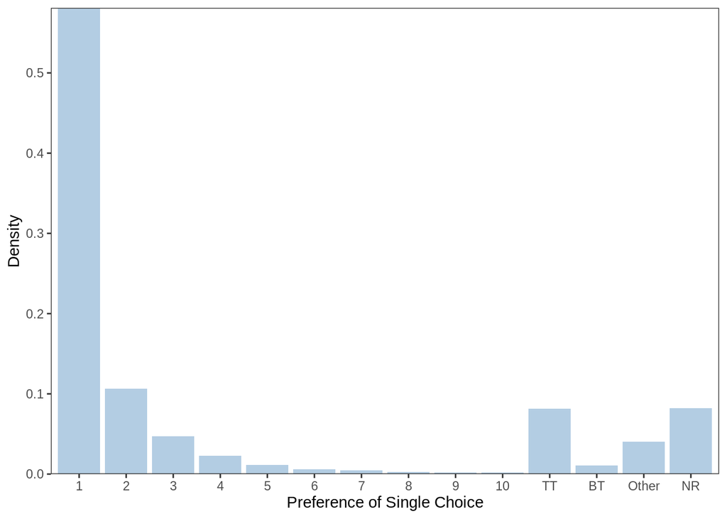

```r
dof %>% filter(!is.na(codigo_carrera_single_choice)) %>% dplyr::mutate(tot = n()) %>% group_by(pref_of_single_choice) %>% dplyr::summarise(pct = n()/tot) %>% distinct(pref_of_single_choice, pct) %>%
  ggplot(aes(x=pref_of_single_choice, y=pct)) + geom_bar(stat="identity", fill=my_colors[2]) +
    labs(x="Preference of Single Choice", y="Density") +
    scale_y_continuous(expand=c(0,0)) +
    theme_bw() + theme(legend.position = 'bottom', legend.title=element_blank(), panel.grid.major = element_blank(), panel.grid.minor = element_blank())
```

```r
ggsave(paste(dropbox_dir,"Mistakes/Code/R/plots/single_choice.pdf", sep=''))
```

# Analysis of RCT + survey ————————–

Note: - Probabilities for the interim porfolios come from the RCT, i.e., with partial applications and randomly completing the market. - Probabilities for the final porfolios come from doing bootstrap with final applications. This is not consistent; we should use the same probabilities for interim and final portfolios. Must likely we should use rational expectations considering the final applications. - Probabilities for the top and bottom true preferences are evaluated using partial applications + market randomly completed.

## Data

```r
#Read All probabilities with Ratex too (fixed)
probstrue <- read.csv(paste(dropbox_dir, "Mistakes/Code/Python/Cartillas/outputs/2022/probs_for_true_results_fixed_with_ratex.csv", sep=''), sep=',', header=TRUE)
probsofficial <- read.csv(paste(dropbox_dir, "Mistakes/Code/Python/Cartillas/outputs/2022/probs_for_official_results_fixed_with_ratex.csv", sep=''), sep=',', header=TRUE)
probspartial <- read.csv(paste(dropbox_dir, "Mistakes/Code/Python/Cartillas/outputs/2022/probs_for_partial_results_fixed_with_ratex.csv", sep=''), sep=',', header=TRUE)
#NOTE: probstrue has as pref 1 the top-true pref and pref 2 the bottom-true pref
```

```r
df <- readRDS(paste(dropbox_dir,"Mistakes/Code/Python/Cartillas/outputs/2022/master_file_for_analysis_of_rct.csv", sep=''))
#NOTE: probstrue has as pref 1 the top-true pref and pref 2 the bottom-true pref
probstrue %<>% dplyr::rename(codigo_carrera_top_true    = codigo_carrera_1,
                             marca_top_true             = marca_1 ,
                             puntpond_top_true          = puntpond_1 ,
                             prob_interim_top_true      = prob_interim_1 ,
                             prob_adaptive_top_true     = prob_adaptive_1 ,
                             prob_ratex_top_true        = prob_ratex_1,
                             codigo_carrera_bottom_true = codigo_carrera_2,
                             marca_bottom_true          = marca_2 ,
                             puntpond_bottom_true       = puntpond_2 ,
                             prob_interim_bottom_true   = prob_interim_2 ,
                             prob_adaptive_bottom_true  = prob_adaptive_2 ,
                             prob_ratex_bottom_true     = prob_ratex_2) %>%
                             select("MRUN",
                                    "codigo_carrera_top_true",
                                    "marca_top_true",
                                    "puntpond_top_true",
                                    "prob_interim_top_true",
                                    "prob_adaptive_top_true",
                                    "prob_ratex_top_true",
                                    "codigo_carrera_bottom_true",
                                    "marca_bottom_true",
                                    "puntpond_bottom_true",
                                    "prob_interim_bottom_true",
                                    "prob_adaptive_bottom_true",
                                    "prob_ratex_bottom_true")

survey <- readRDS(paste(dropbox_dir,"Mistakes/Code/Python/Cartillas/outputs/2022/survey_processed_with_probs.rds", sep=''))
#NOTE: this file has the subjective beliefs on probabilities (you can confirm this becaise probs have round values)
# Merge survey with clean probs for toptrue and bottomtrue
survey = merge(survey, probstrue %>% select(!c("codigo_carrera_top_true", "codigo_carrera_bottom_true","marca_top_true",
                                               "puntpond_top_true", "marca_bottom_true", "puntpond_bottom_true")), by.x = "mrun", by.y = "MRUN", all.x = TRUE)

dof <- merge(df, survey, by.x="MRUN", by.y="mrun", all.x=TRUE)
dof <- merge(dof, probsofficial %>% dplyr::select(MRUN,
                                       overall_interim, overall_adaptive, overall_ratex,
                                       prob_interim_1, prob_adaptive_1, prob_ratex_1,
                                       prob_interim_2, prob_adaptive_2, prob_ratex_2,
                                       prob_interim_3, prob_adaptive_3, prob_ratex_3,
                                       prob_interim_4, prob_adaptive_4, prob_ratex_4,
                                       prob_interim_5, prob_adaptive_5, prob_ratex_5,
                                       prob_interim_6, prob_adaptive_6, prob_ratex_6,
                                       prob_interim_7, prob_adaptive_7, prob_ratex_7,
                                       prob_interim_8, prob_adaptive_8, prob_ratex_8,
                                       prob_interim_9, prob_adaptive_9, prob_ratex_9,
                                       prob_interim_10, prob_adaptive_10,  prob_ratex_10 ) %>%
               dplyr::rename(
                             overall_prob_interim_fin = overall_interim,
                             overall_prob_adaptive_fin = overall_adaptive,
                             overall_prob_ratex_fin = overall_ratex,
                             prob_interim_1_fin  = prob_interim_1, prob_adaptive_1_fin   = prob_adaptive_1,  prob_ratex_1_fin   = prob_ratex_1,
                             prob_interim_2_fin  = prob_interim_2, prob_adaptive_2_fin   = prob_adaptive_2,  prob_ratex_2_fin   = prob_ratex_2,
                             prob_interim_3_fin  = prob_interim_3, prob_adaptive_3_fin   = prob_adaptive_3,  prob_ratex_3_fin   = prob_ratex_3,
                             prob_interim_4_fin  = prob_interim_4, prob_adaptive_4_fin   = prob_adaptive_4,  prob_ratex_4_fin   = prob_ratex_4,
                             prob_interim_5_fin  = prob_interim_5, prob_adaptive_5_fin   = prob_adaptive_5,  prob_ratex_5_fin   = prob_ratex_5,
                             prob_interim_6_fin  = prob_interim_6, prob_adaptive_6_fin   = prob_adaptive_6,  prob_ratex_6_fin   = prob_ratex_6,
                             prob_interim_7_fin  = prob_interim_7, prob_adaptive_7_fin   = prob_adaptive_7,  prob_ratex_7_fin   = prob_ratex_7,
                             prob_interim_8_fin  = prob_interim_8, prob_adaptive_8_fin   = prob_adaptive_8,  prob_ratex_8_fin   = prob_ratex_8,
                             prob_interim_9_fin  = prob_interim_9, prob_adaptive_9_fin   = prob_adaptive_9,  prob_ratex_9_fin   = prob_ratex_9,
                             prob_interim_10_fin = prob_interim_10, prob_adaptive_10_fin = prob_adaptive_10, prob_ratex_10_fin  = prob_ratex_10  ),
             by="MRUN", all.x=TRUE)

#  Add probabilities for partial portfolios (before the intervention)
dof <- merge(dof, probspartial %>% dplyr::select(MRUN,
                                              overall_interim, overall_adaptive, overall_ratex,
                                              prob_interim_1, prob_adaptive_1, prob_ratex_1,
                                              prob_interim_2, prob_adaptive_2, prob_ratex_2,
                                              prob_interim_3, prob_adaptive_3, prob_ratex_3,
                                              prob_interim_4, prob_adaptive_4, prob_ratex_4,
                                              prob_interim_5, prob_adaptive_5, prob_ratex_5,
                                              prob_interim_6, prob_adaptive_6, prob_ratex_6,
                                              prob_interim_7, prob_adaptive_7, prob_ratex_7,
                                              prob_interim_8, prob_adaptive_8, prob_ratex_8,
                                              prob_interim_9, prob_adaptive_9, prob_ratex_9,
                                              prob_interim_10, prob_adaptive_10,  prob_ratex_10 ) %>%
                            dplyr::rename(overall_prob_interim_int = overall_interim,
                                          overall_prob_adaptive_int = overall_adaptive,
                                          overall_prob_ratex_int = overall_ratex,
                                          prob_interim_1_int  = prob_interim_1, prob_adaptive_1_int   = prob_adaptive_1,  prob_ratex_1_int   = prob_ratex_1,
                                          prob_interim_2_int  = prob_interim_2, prob_adaptive_2_int   = prob_adaptive_2,  prob_ratex_2_int   = prob_ratex_2,
                                          prob_interim_3_int  = prob_interim_3, prob_adaptive_3_int   = prob_adaptive_3,  prob_ratex_3_int   = prob_ratex_3,
                                          prob_interim_4_int  = prob_interim_4, prob_adaptive_4_int   = prob_adaptive_4,  prob_ratex_4_int   = prob_ratex_4,
                                          prob_interim_5_int  = prob_interim_5, prob_adaptive_5_int   = prob_adaptive_5,  prob_ratex_5_int   = prob_ratex_5,
                                          prob_interim_6_int  = prob_interim_6, prob_adaptive_6_int   = prob_adaptive_6,  prob_ratex_6_int   = prob_ratex_6,
                                          prob_interim_7_int  = prob_interim_7, prob_adaptive_7_int   = prob_adaptive_7,  prob_ratex_7_int   = prob_ratex_7,
                                          prob_interim_8_int  = prob_interim_8, prob_adaptive_8_int   = prob_adaptive_8,  prob_ratex_8_int   = prob_ratex_8,
                                          prob_interim_9_int  = prob_interim_9, prob_adaptive_9_int   = prob_adaptive_9,  prob_ratex_9_int   = prob_ratex_9,
                                          prob_interim_10_int = prob_interim_10, prob_adaptive_10_int = prob_adaptive_10, prob_ratex_10_int  = prob_ratex_10  ),
                          by="MRUN", all.x=TRUE)
```

```r
dof %<>% mutate(responded_survey = ifelse(is.na(responded_survey), 0, responded_survey))

#TODO: notice that here we are using as a minimum score the value 0 (we need to change this to the
# maximum between minimum weighted score requirement and 210)
of <- read.csv(paste(dropbox_dir, "Mistakes/Code/Python/Cartillas/data/2022/seleccion_20_01_22.csv", sep=''))
car <- read.csv(paste(dropbox_dir, "/Mistakes/Code/Python/Cartillas/data/2022/carreras_v2.csv", sep=''), header=TRUE, sep=";")

#NOTE: Be careful here that we are identifying the columns by their order
#TODO: We need to check that this order is correct
of_l <- reshape(of[,c(1,4:53)], direction='long',
                    varying=colnames(of[,4:53]),
                    times=c('01', '02', '03', '04', '05', '06', '07', '08', '09', '10'),
                    v.names=c('cod_carrera_pref', 'estado_pref','ptje_pref', 'lugar_pref', 'pond_acad_pref'),
                    idvar='mrun')
colnames(of_l) <- c("mrun", "pref", "codigo_carrera", "marca", "orden", "puntano", "puntpond") # this is just me not knowing how to use reshape

cutoffs <- of_l %>% filter(marca == 24) %>% group_by(codigo_carrera) %>% dplyr::summarise(num_admitted = n(), min_score = pmax(min(puntpond), 210.0))
car %<>% mutate(VACANTES_REG = VACANTES_1_SEMESTRE + VACANTES_2_SEMESTRE + SOBRECUPO_1_SEMESTRE + SOBRECUPO_2_SEMESTRE)
car <- merge(car, cutoffs, by.x="CODIGO_DEMRE", by.y="codigo_carrera", all.x=TRUE)

dof <- merge(dof, car %>% dplyr::select(CODIGO_DEMRE, VACANTES_REG, num_admitted, min_score) %>%
               mutate(min_score = ifelse(num_admitted < VACANTES_REG, 210.0, min_score)) %>%
               dplyr::rename(vacants_top_true = VACANTES_REG,
                             num_admitted_top_true = num_admitted,
                             min_score_top_true = min_score), by.x="codigo_carrera_top_true", by.y="CODIGO_DEMRE", all.x=TRUE)

dof <- merge(dof, car %>% dplyr::select(CODIGO_DEMRE, VACANTES_REG, num_admitted, min_score) %>%
               mutate(min_score = ifelse(num_admitted < VACANTES_REG, 210.0, min_score)) %>%
               dplyr::rename(vacants_bottom_true = VACANTES_REG,
                             num_admitted_bottom_true = num_admitted,
                             min_score_bottom_true = min_score), by.x="codigo_carrera_bottom_true", by.y="CODIGO_DEMRE", all.x=TRUE)


dof %<>% mutate(applied_to_top_true_int = ifelse(codigo_carrera_top_true == codigo_carrera_1_int | codigo_carrera_top_true == codigo_carrera_2_int |
                                              codigo_carrera_top_true == codigo_carrera_3_int | codigo_carrera_top_true == codigo_carrera_4_int |
                                              codigo_carrera_top_true == codigo_carrera_5_int | codigo_carrera_top_true == codigo_carrera_6_int |
                                              codigo_carrera_top_true == codigo_carrera_7_int | codigo_carrera_top_true == codigo_carrera_8_int |
                                              codigo_carrera_top_true == codigo_carrera_9_int | codigo_carrera_top_true == codigo_carrera_10_int, 1, 0),
                applied_to_bottom_true_int = ifelse(codigo_carrera_bottom_true == codigo_carrera_1_int | codigo_carrera_bottom_true == codigo_carrera_2_int |
                                              codigo_carrera_bottom_true == codigo_carrera_3_int | codigo_carrera_bottom_true == codigo_carrera_4_int |
                                              codigo_carrera_bottom_true == codigo_carrera_5_int | codigo_carrera_bottom_true == codigo_carrera_6_int |
                                              codigo_carrera_bottom_true == codigo_carrera_7_int | codigo_carrera_bottom_true == codigo_carrera_8_int |
                                              codigo_carrera_bottom_true == codigo_carrera_9_int | codigo_carrera_bottom_true == codigo_carrera_10_int, 1, 0))

dof %<>% mutate(applied_to_top_true_fin = ifelse(codigo_carrera_top_true == codigo_carrera_1_fin | codigo_carrera_top_true == codigo_carrera_2_fin |
                                              codigo_carrera_top_true == codigo_carrera_3_fin | codigo_carrera_top_true == codigo_carrera_4_fin |
                                              codigo_carrera_top_true == codigo_carrera_5_fin | codigo_carrera_top_true == codigo_carrera_6_fin |
                                              codigo_carrera_top_true == codigo_carrera_7_fin | codigo_carrera_top_true == codigo_carrera_8_fin |
                                              codigo_carrera_top_true == codigo_carrera_9_fin | codigo_carrera_top_true == codigo_carrera_10_fin, 1, 0),
                applied_to_bottom_true_fin = ifelse(codigo_carrera_bottom_true == codigo_carrera_1_fin | codigo_carrera_bottom_true == codigo_carrera_2_fin |
                                              codigo_carrera_bottom_true == codigo_carrera_3_fin | codigo_carrera_bottom_true == codigo_carrera_4_fin |
                                              codigo_carrera_bottom_true == codigo_carrera_5_fin | codigo_carrera_bottom_true == codigo_carrera_6_fin |
                                              codigo_carrera_bottom_true == codigo_carrera_7_fin | codigo_carrera_bottom_true == codigo_carrera_8_fin |
                                              codigo_carrera_bottom_true == codigo_carrera_9_fin | codigo_carrera_bottom_true == codigo_carrera_10_fin, 1, 0))

dof %<>% mutate(ordering_mistake_int = ifelse(applied_to_top_true_int == 1 & codigo_carrera_top_true != codigo_carrera_1_fin, 1, 0),
                ordering_mistake_fin = ifelse(applied_to_top_true_fin == 1 & codigo_carrera_top_true != codigo_carrera_1_fin, 1, 0))


#TODO: Check this code with Nacho seems wrong to me
# dof %<>% rowwise() %>% mutate(min_prob_adaptive_int = min(prob_adaptive_1_int + (codigo_carrera_1_int == 0), prob_adaptive_2_int + (codigo_carrera_2_int == 0),
#                                                       prob_adaptive_3_int + (codigo_carrera_3_int == 0), prob_adaptive_4_int + (codigo_carrera_4_int == 0),
#                                                       prob_adaptive_5_int + (codigo_carrera_5_int == 0), prob_adaptive_6_int + (codigo_carrera_6_int == 0),
#                                                       prob_adaptive_7_int + (codigo_carrera_7_int == 0), prob_adaptive_8_int + (codigo_carrera_8_int == 0),
#                                                       prob_adaptive_9_int + (codigo_carrera_9_int == 0), prob_adaptive_10_int + (codigo_carrera_10_int == 0)))
```

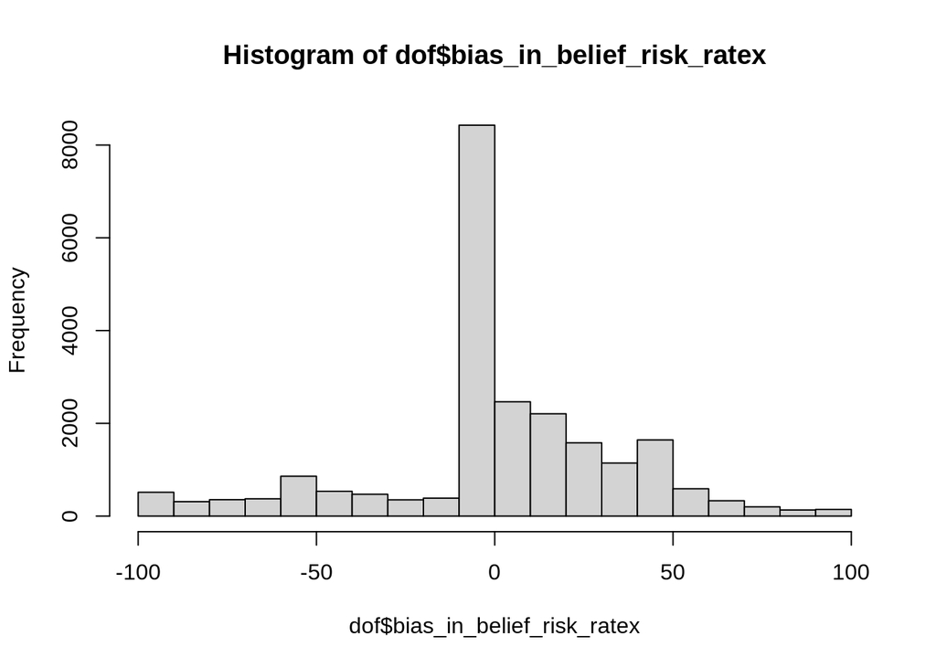

```r
# dof %<>% rowwise() %>% mutate(min_prob_adaptive_fin = min(prob_adaptive_1_fin + (codigo_carrera_1_fin == 0), prob_adaptive_2_fin + (codigo_carrera_2_fin == 0),
#                                                       prob_adaptive_3_fin + (codigo_carrera_3_fin == 0), prob_adaptive_4_fin + (codigo_carrera_4_fin == 0),
#                                                       prob_adaptive_5_fin + (codigo_carrera_5_fin == 0), prob_adaptive_6_fin + (codigo_carrera_6_fin == 0),
#                                                       prob_adaptive_7_fin + (codigo_carrera_7_fin == 0), prob_adaptive_8_fin + (codigo_carrera_8_fin == 0),
#                                                       prob_adaptive_9_fin + (codigo_carrera_9_fin == 0), prob_adaptive_10_fin + (codigo_carrera_10_fin == 0)))

#TODO: Becareful with the sign here, it might not be consistent with the definitions in the paper
dof %<>% mutate(bias_in_belief_ratex_top_true    = as.numeric(prob_top_true) - as.numeric(prob_ratex_top_true)*100,
                bias_in_belief_ratex_bottom_true = as.numeric(prob_bottom_true) - as.numeric(prob_ratex_bottom_true)*100)
#TODO: review this definition
dof %<>% mutate(bias_in_belief_overall_ratex =  as.numeric(prob_any_pref) - as.numeric(overall_prob_ratex_fin)*100,
                bias_in_belief_risk_ratex =  (100 - as.numeric(prob_any_pref)) - (1 - as.numeric(overall_prob_ratex_fin))*100)
hist(dof$bias_in_belief_risk_ratex)
```

```r
# ELIMINAR PACES HABILITADOS
paces <- read.csv(paste(dropbox_dir, "Mistakes/Code/Python/Cartillas/data/2022/habilitados_pace_v2.csv", sep=''), sep=',', header=TRUE)
paces %<>% mutate(habilitado = ifelse(criterio_1 == 1 & criterio_2 == 1 & criterio_3 == 1, 1, 0))
paces_ids <- paces %>% filter(habilitado == 1) %>% pull(mrun)
dof %<>% filter(!(MRUN %in% paces_ids))
```

## Ordering mistakes

```r
#TODO: we should apply the same filters we used in the previous survey to identify which is the fraction of students who are really declaring their top-true preference
dof %>% group_by(ordering_mistake_fin) %>% tally()
```

```
## # A tibble: 3 × 2
##   ordering_mistake_fin     n
##                  <dbl> <int>
## 1                    0 17768
## 2                    1  2821
## 3                   NA 82816
```

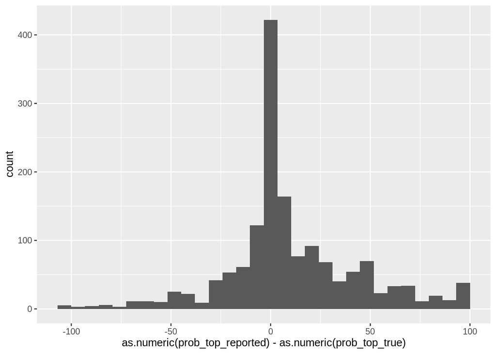

```r
# Check if ordering mistakes make sense and correlate with biased beliefs
dof %>% filter(ordering_mistake_fin == 1) %>% ggplot(aes(x=as.numeric(prob_top_reported)-as.numeric(prob_top_true))) + geom_histogram()
```

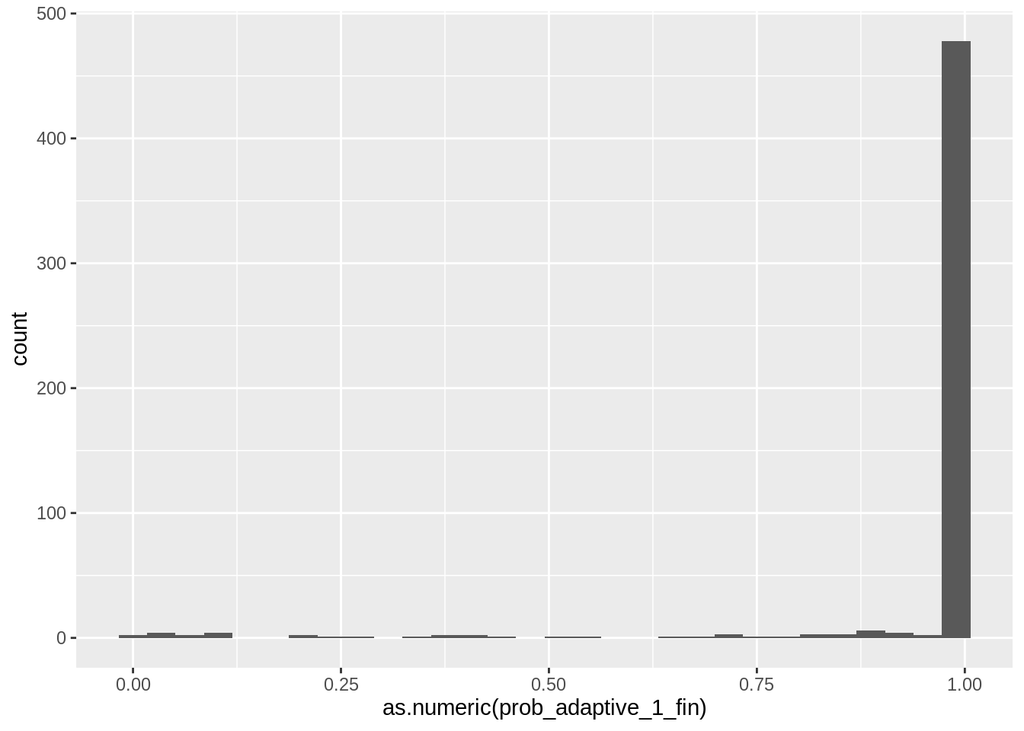

```r
#NOTE: I am getting then fraction who makes a welfare relevant ordering mistake now
dof %>% filter(ordering_mistake_fin == 1 & as.numeric(prob_adaptive_top_true) > 0.01 & as.numeric(prob_adaptive_1_fin) > 0.01) %>% ggplot(aes(x=as.numeric(prob_adaptive_1_fin))) + geom_histogram()
```

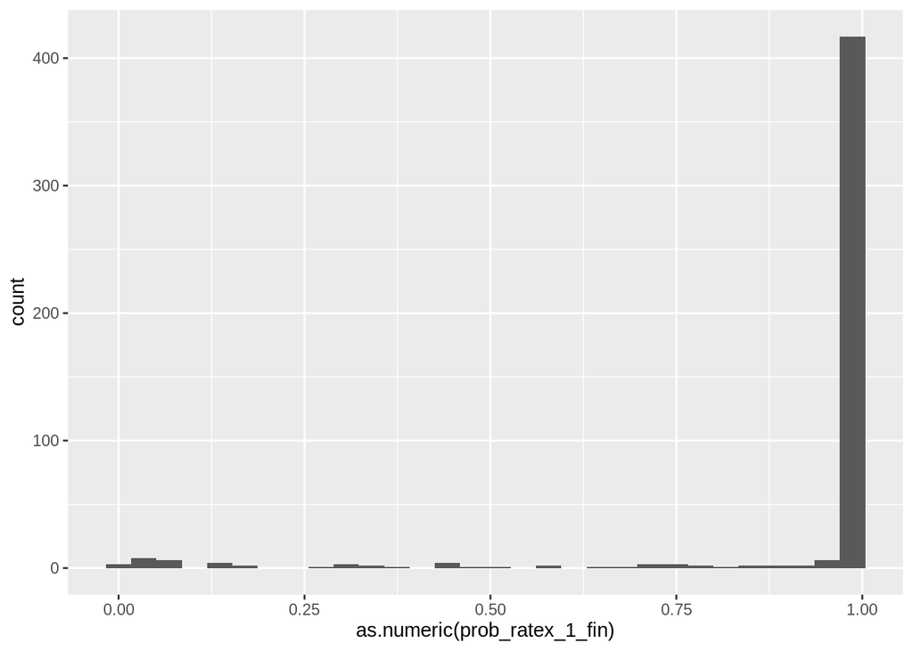

```r
dof %>% filter(ordering_mistake_fin == 1 & as.numeric(prob_ratex_top_true) > 0.01 & as.numeric(prob_ratex_1_fin) > 0.01) %>% ggplot(aes(x=as.numeric(prob_ratex_1_fin))) + geom_histogram()
```

```r
# Payoff-relevant ordering mistakes
tot = dof %>% filter(responded_survey == 1) %>% nrow()
dof %>% ungroup %>% as.data.frame() %>% filter(applied_to_top_true_fin == 1 & codigo_carrera_top_true != codigo_carrera_1_fin & !is.na(prob_ratex_top_true)) %>%
              dplyr::summarise(type="Ordering", exante = sum(prob_ratex_top_true > 0.01, na.rm=TRUE), exante_p = 100*sum(prob_ratex_top_true > 0.01, na.rm=TRUE)/tot,
                               expost = sum(puntpond_top_true >= min_score_top_true, na.rm=TRUE), expost_p = 100*sum(puntpond_top_true >= min_score_top_true, na.rm=TRUE)/tot)
```

```
##       type exante exante_p expost expost_p
## 1 Ordering    663  2.82874    543 2.316751
```

Results: - Comparing with belief of adm prob of top reported, many think their chances of admission are lower TODO: If we define ordering mistakes to be welfare relevant relative to ratex beliefs, I get that around 600 students make a payoff relevant ordering mistake in the sample (around 22,000 students), which is around 3% (a significant number). We still need to filter students who declare the top-true in a way that is inconsistent with theory and the other survey responses. We need to see how to deal with measurement error and do not assume all measurement error is a mistake

## Under-confidence mistakes

```r
dof %>% group_by(applied_to_top_true_fin) %>% tally()
```

```
## # A tibble: 3 × 2
##   applied_to_top_true_fin     n
##                     <dbl> <int>
## 1                       0  6374
## 2                       1 14215
## 3                      NA 82816
```

```r
dof %>% filter(applied_to_top_true_fin == 0) %>% group_by(marca_top_true == 25) %>% tally()
```

```
## # A tibble: 2 × 2
##   `marca_top_true == 25`     n
##   <lgl>                  <int>
## 1 FALSE                   3621
## 2 TRUE                    2753
```

```r
dof %>% filter(applied_to_top_true_fin == 0 & marca_top_true == 25) %>% group_by(puntpond_top_true >= min_score_top_true, apps_after == 10) %>% tally()
```

```
## # A tibble: 4 × 3
## # Groups:   puntpond_top_true >= min_score_top_true [2]
##   `puntpond_top_true >= min_score_top_true` `apps_after == 10`     n
##   <lgl>                                     <lgl>              <int>
## 1 FALSE                                     FALSE               1884
## 2 FALSE                                     TRUE                 353
## 3 TRUE                                      FALSE                465
## 4 TRUE                                      TRUE                  51
```

```r
dof %>% filter(applied_to_top_true_fin == 0 & marca_top_true == 25) %>% group_by(prob_adaptive_top_true > 0.01) %>% tally()
```

```
## # A tibble: 3 × 2
##   `prob_adaptive_top_true > 0.01`     n
##   <lgl>                           <int>
## 1 FALSE                            2085
## 2 TRUE                              666
## 3 NA                                  2
```

```r
dof %>% filter(applied_to_top_true_fin == 0 & marca_top_true == 25) %>% group_by(prob_ratex_top_true > 0.01) %>% tally()
```

```
## # A tibble: 3 × 2
##   `prob_ratex_top_true > 0.01`     n
##   <lgl>                        <int>
## 1 FALSE                         2144
## 2 TRUE                           607
## 3 NA                               2
```

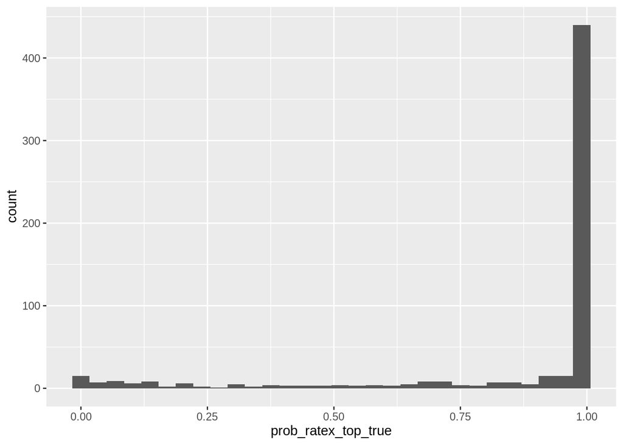

```r
#NOTE: results change drastically if we use as a threshold 0.01 instead of 0.00. We need to change this in all the paper, because we are now using smoothed probabilities
dof %>% filter(applied_to_top_true_fin == 0 & marca_top_true == 25 & prob_ratex_top_true > 0.01) %>% ggplot(aes(x=prob_ratex_top_true)) + geom_histogram()
```

Results - We need to check how this changes with the clean definition of top-true

```r
dof %>% filter(applied_to_top_true_fin == 0 & marca_top_true == 25 & puntpond_top_true >= min_score_top_true) %>% group_by(reason_skip_top_true) %>% tally() %>% arrange(-n)
```

```
## # A tibble: 120 × 2
##    reason_skip_top_true                                                        n
##    <chr>                                                                   <int>
##  1 No tengo los recursos económicos para pagar el costo de la carrera.       126
##  2 La probabilidad de que quede seleccionado en esa carrera es muy baja.     111
##  3 <NA>                                                                       46
##  4 La decisión de dónde postular no dependió completamente de mí, y fue i…    36
##  5 La carrera me parece demasiado difícil y no creo que vaya a terminarla…    22
##  6 Para incluir mi carrera ideal tendría que excluir alguna de las carrer…    21
##  7 Pensé que al incluir esta carrera en mi lista de preferencias habría r…    21
##  8 Dado que mi probabilidad de selección es muy baja, prefiero no postula…    20
##  9 Ubicación                                                                   2
## 10 A pesar de ser una carrera bastante llamativa tanto para mi como para …     1
## # … with 110 more rows
```

## Over-confidence mistakes

```r
dof %>% group_by(bottom_true_any) %>% tally()
```

```
## # A tibble: 3 × 2
##   bottom_true_any     n
##   <chr>           <int>
## 1 0               14510
## 2 1                5367
## 3 <NA>            83528
```

```r
#TODO: we have one observation that seems to declare a bottom_true as a program in their list. I think this
#shouldn't be the case, but we have to check whether maybe this was still possible and not blocked
# in the survey design
dof %>% group_by(applied_to_bottom_true_fin) %>% tally()
```

```
## # A tibble: 3 × 2
##   applied_to_bottom_true_fin     n
##                        <dbl> <int>
## 1                          0  5012
## 2                          1     1
## 3                         NA 98392
```

```r
dof %>% filter(applied_to_bottom_true_fin == 0) %>% group_by(marca_bottom_true == 25) %>% tally()
```

```
## # A tibble: 2 × 2
##   `marca_bottom_true == 25`     n
##   <lgl>                     <int>
## 1 FALSE                      1622
## 2 TRUE                       3390
```

```r
dof %>% filter(applied_to_bottom_true_fin == 0 & marca_bottom_true == 25) %>% group_by(assigned_oficial) %>% tally()
```

```
## # A tibble: 2 × 2
##   assigned_oficial     n
##              <dbl> <int>
## 1                0   244
## 2                1  3146
```

```r
dof %>% filter(applied_to_bottom_true_fin == 0 & marca_bottom_true == 25 & assigned_oficial == 0) %>% group_by(puntpond_bottom_true > min_score_bottom_true) %>% tally()
```

```
## # A tibble: 2 × 2
##   `puntpond_bottom_true > min_score_bottom_true`     n
##   <lgl>                                          <int>
## 1 FALSE                                            104
## 2 TRUE                                             140
```

```r
dof %>% filter(applied_to_bottom_true_fin == 0 & marca_bottom_true == 25 & assigned_oficial == 0) %>% group_by(prob_adaptive_bottom_true > 0.01) %>% tally()
```

```
## # A tibble: 2 × 2
##   `prob_adaptive_bottom_true > 0.01`     n
##   <lgl>                              <int>
## 1 FALSE                                 71
## 2 TRUE                                 173
```

```r
dof %>% filter(applied_to_bottom_true_fin == 0 & marca_bottom_true == 25 & assigned_oficial == 0) %>% group_by(prob_ratex_bottom_true > 0.01) %>% tally()
```

```
## # A tibble: 2 × 2
##   `prob_ratex_bottom_true > 0.01`     n
##   <lgl>                           <int>
## 1 FALSE                              84
## 2 TRUE                              160
```

```r
dof %>% filter(applied_to_bottom_true_fin == 0 & marca_bottom_true == 25 & overall_prob_adaptive_fin < 0.99) %>% group_by(prob_adaptive_bottom_true > 0.01) %>% tally()
```

```
## # A tibble: 2 × 2
##   `prob_adaptive_bottom_true > 0.01`     n
##   <lgl>                              <int>
## 1 FALSE                                 73
## 2 TRUE                                 153
```

```r
dof %>% filter(applied_to_bottom_true_fin == 0 & marca_bottom_true == 25 & overall_prob_ratex_fin < 0.99) %>% group_by(prob_ratex_bottom_true > 0.01) %>% tally()
```

```
## # A tibble: 2 × 2
##   `prob_ratex_bottom_true > 0.01`     n
##   <lgl>                           <int>
## 1 FALSE                             117
## 2 TRUE                              207
```

## Tables

```r
rbind(dof %>% ungroup %>% as.data.frame() %>% filter(applied_to_top_true_fin == 0 & marca_top_true == 25) %>%
              dplyr::summarise(type="Underconfidence", exante = sum(prob_ratex_top_true > 0.01, na.rm=TRUE), exante_p = 100*sum(prob_ratex_top_true > 0.01, na.rm=TRUE)/tot,
                               expost = sum(puntpond_top_true >= min_score_top_true), expost_p = 100*sum(puntpond_top_true >= min_score_top_true)/tot),
            dof %>% ungroup %>% as.data.frame() %>% filter(applied_to_top_true_fin == 1 & codigo_carrera_top_true != codigo_carrera_1_fin) %>%
              dplyr::summarise(type="Ordering", exante = sum(prob_ratex_top_true > 0.01, na.rm=TRUE), exante_p = 100*sum(prob_ratex_top_true > 0.01, na.rm=TRUE)/tot,
                               expost = sum(puntpond_top_true >= min_score_top_true, na.rm=TRUE), expost_p = 100*sum(puntpond_top_true >= min_score_top_true, na.rm=TRUE)/tot),
            #dof %>% ungroup %>% as.data.frame() %>% filter(applied_to_bottom_true_fin == 0 & marca_bottom_true == 25 & assigned_fin == 0)  %>%
            dof %>% ungroup %>% as.data.frame() %>% filter(applied_to_bottom_true_fin == 0 & marca_bottom_true == 25 & overall_prob_ratex_fin < 0.99)  %>%
              dplyr::summarise(type="Overconfidence", exante = sum(prob_ratex_bottom_true > 0.01), exante_p = 100*sum(prob_ratex_bottom_true > 0.01)/tot,
                               expost = sum(puntpond_bottom_true > min_score_bottom_true & assigned_fin == 0), expost_p = 100*sum(puntpond_bottom_true > min_score_bottom_true & assigned_fin == 0)/tot))
```

```
##              type exante  exante_p expost  expost_p
## 1 Underconfidence    607 2.5898114    516 2.2015530
## 2        Ordering    663 2.8287397    543 2.3167506
## 3  Overconfidence    207 0.8831812    142 0.6058537
```

```r
#TODO: I think here we are  completely underpowered to interpret any sort of analysis by mistake type
# We could explore the following alternatives
# 1) Pooling all treatment arms
# 2) Pooling mistake types

#Here we are pooling by mistake type to gain power. We are still underpowered to do any sensitive analysys here.
dof %>% filter(responded_survey == 1) %>% group_by(treatment, open) %>%
              dplyr::summarise(tot = n(),
                               exante_b = sum(applied_to_top_true_int == 0 & marca_top_true == 25 & prob_ratex_top_true > 0.01, na.rm=TRUE) +
                                          sum(applied_to_top_true_int == 1 & codigo_carrera_top_true != codigo_carrera_1_int & prob_ratex_top_true > 0.01, na.rm=TRUE) +
                                          sum(applied_to_bottom_true_int == 0 & marca_bottom_true == 25 & overall_prob_ratex_int < 0.99 & prob_ratex_bottom_true > 0.01, na.rm=TRUE),
                               exante_a = sum(applied_to_top_true_fin == 0 & marca_top_true == 25 & prob_ratex_top_true > 0.01, na.rm=TRUE) +
                                          sum(applied_to_top_true_fin == 1 & codigo_carrera_top_true != codigo_carrera_1_fin & prob_ratex_top_true > 0.01, na.rm=TRUE) +
                                          sum(applied_to_bottom_true_fin == 0 & marca_bottom_true == 25 & overall_prob_ratex_fin < 0.99 & prob_ratex_bottom_true > 0.01, na.rm=TRUE),
                               exante_p = 100*(exante_a-exante_b)/exante_b)
```

```
## # A tibble: 8 × 6
## # Groups:   treatment [4]
##   treatment  open   tot exante_b exante_a exante_p
##       <int> <dbl> <int>    <int>    <int>    <dbl>
## 1         1     0  3344      234      213    -8.97
## 2         1     1  2476      171      153   -10.5
## 3         2     0  3270      233      219    -6.01
## 4         2     1  2545      171      163    -4.68
## 5         3     0  3480      256      232    -9.38
## 6         3     1  2506      169      148   -12.4
## 7         4     0  3352      222      196   -11.7
## 8         4     1  2465      169      153    -9.47
```

```r
                               #expost_b = sum(applied_to_top_true_int == 0 & marca_top_true == 25 & puntpond_top_true >= min_score_top_true, na.rm=TRUE),
                               #expost_a = sum(applied_to_top_true_fin == 0 & marca_top_true == 25 & puntpond_top_true >= min_score_top_true, na.rm=TRUE),
                               #expost_p = 100*(expost_a-expost_b)/expost_b)
```

#Doing a formal regression to see whether the treatment arms can indeed reduce mistakes (completely underpowered, just noise)

```r
#TODO: check that this filter is correct (check the NAs)
d_mistakes_treatments = dof %>% filter(responded_survey == 1 & open == 1) %>% mutate(
                               #Strategic mistakes partial portfolios
                               underconfidence_exante_int = ifelse(applied_to_top_true_int == 0 & marca_top_true == 25 & prob_ratex_top_true > 0.01, 1, 0),
                               ordering_exante_int = ifelse(applied_to_top_true_int == 1 & codigo_carrera_top_true != codigo_carrera_1_int & prob_ratex_top_true > 0.01, 1, 0),
                               overconfidence_exante_int = ifelse(applied_to_bottom_true_int == 0 & marca_bottom_true == 25 & overall_prob_ratex_int < 0.99 & prob_ratex_bottom_true > 0.01, 1, 0),
                               mistake_any_exante_int = ifelse(underconfidence_exante_int + ordering_exante_int + overconfidence_exante_int > 0, 1, 0),
                               #Strategic mistakes final portfolios
                               underconfidence_exante_fin = ifelse(applied_to_top_true_fin == 0 & marca_top_true == 25 & prob_ratex_top_true > 0.01, 1, 0),
                               ordering_exante_fin = ifelse(applied_to_top_true_fin == 1 & codigo_carrera_top_true != codigo_carrera_1_fin & prob_ratex_top_true > 0.01, 1, 0),
                               overconfidence_exante_fin = ifelse(applied_to_bottom_true_fin == 0 & marca_bottom_true == 25 & overall_prob_ratex_fin < 0.99 & prob_ratex_bottom_true > 0.01, 1, 0),
                               mistake_any_exante_fin = ifelse(underconfidence_exante_fin + ordering_exante_fin + overconfidence_exante_fin > 0, 1, 0),
                               has_bottom_true_fin = ifelse(applied_to_bottom_true_fin == 0, 1, 0),
                               applied_to_top_true_relevant_fin = ifelse(applied_to_top_true_fin == 1 & prob_ratex_top_true > 0.01, 1, 0),
                               mistake_any_exante_dec = ifelse(mistake_any_exante_fin < mistake_any_exante_int, 1, 0),
                               underconfidence_exante_dec = ifelse(underconfidence_exante_fin < underconfidence_exante_int, 1, 0),
                               overconfidence_exante_dec = ifelse(overconfidence_exante_fin < overconfidence_exante_int, 1, 0),
                               overall_prob_ratex_inc = ifelse(overall_prob_ratex_fin > overall_prob_ratex_int, 1, 0))
d_mistakes_treatments %>% dplyr::summarise(tot = n(),
                                           underconfidence_exante_p_int = 100*mean(underconfidence_exante_int),
                                           underconfidence_exante_p_fin = 100*mean(underconfidence_exante_fin),
                                           overconfidence_exante_p_int = 100*mean(overconfidence_exante_int),
                                           overconfidence_exante_p_fin = 100*mean(overconfidence_exante_fin),
                                           ordering_exante_p_int = 100*mean(ordering_exante_int),
                                           ordering_exante_p_fin = 100*mean(ordering_exante_fin),
                                           mistake_any_exante_p_int = 100*mean(mistake_any_exante_int),
                                           mistake_any_exante_p_fin = 100*mean(mistake_any_exante_fin))
```

```
##    tot underconfidence_exante_p_int underconfidence_exante_p_fin
## 1 9992                           NA                           NA
##   overconfidence_exante_p_int overconfidence_exante_p_fin ordering_exante_p_int
## 1                   0.8706966                          NA               3.21257
##   ordering_exante_p_fin mistake_any_exante_p_int mistake_any_exante_p_fin
## 1              2.832266                       NA                       NA
```

```r
#Run regresion to see the tratment effects
# Any mistake
mistakes_reg = lm(data = as.data.frame(d_mistakes_treatments), mistake_any_exante_fin ~ factor(treatment))
summary(mistakes_reg)
```

```
##
## Call:
## lm(formula = mistake_any_exante_fin ~ factor(treatment), data = as.data.frame(d_mistakes_treatments))
##
## Residuals:
##      Min       1Q   Median       3Q      Max
## -0.06331 -0.06207 -0.06179 -0.05908  0.94092
##
## Coefficients:
##                      Estimate Std. Error t value Pr(>|t|)
## (Intercept)         0.0617932  0.0048315  12.790   <2e-16 ***
## factor(treatment)2  0.0015178  0.0067876   0.224    0.823
## factor(treatment)3 -0.0027114  0.0068129  -0.398    0.691
## factor(treatment)4  0.0002758  0.0068404   0.040    0.968
## ---
## Signif. codes:  0 '***' 0.001 '**' 0.01 '*' 0.05 '.' 0.1 ' ' 1
##
## Residual standard error: 0.2404 on 9985 degrees of freedom
##   (3 observations deleted due to missingness)
## Multiple R-squared:  4.15e-05,   Adjusted R-squared:  -0.0002589
## F-statistic: 0.1381 on 3 and 9985 DF,  p-value: 0.9372
```

```r
mistakes_dec_reg = lm(data = as.data.frame(d_mistakes_treatments), mistake_any_exante_dec ~ factor(treatment))
summary(mistakes_dec_reg)
```

```
##
## Call:
## lm(formula = mistake_any_exante_dec ~ factor(treatment), data = as.data.frame(d_mistakes_treatments))
##
## Residuals:
##      Min       1Q   Median       3Q      Max
## -0.01078 -0.00811 -0.00767 -0.00551  0.99449
##
## Coefficients:
##                      Estimate Std. Error t value Pr(>|t|)
## (Intercept)         0.0076737  0.0017912   4.284 1.85e-05 ***
## factor(treatment)2 -0.0021684  0.0025164  -0.862    0.389
## factor(treatment)3  0.0031048  0.0025258   1.229    0.219
## factor(treatment)4  0.0004399  0.0025360   0.173    0.862
## ---
## Signif. codes:  0 '***' 0.001 '**' 0.01 '*' 0.05 '.' 0.1 ' ' 1
##
## Residual standard error: 0.08913 on 9985 degrees of freedom
##   (3 observations deleted due to missingness)
## Multiple R-squared:  0.0004468,  Adjusted R-squared:  0.0001465
## F-statistic: 1.488 on 3 and 9985 DF,  p-value: 0.2156
```

```r
# Now looking only at people who made some mistake in the partial application
mistakes_dec_reg = lm(data = as.data.frame(d_mistakes_treatments %>% filter(mistake_any_exante_int == 1)), mistake_any_exante_dec ~ factor(treatment))
summary(mistakes_dec_reg)
```

```
##
## Call:
## lm(formula = mistake_any_exante_dec ~ factor(treatment), data = as.data.frame(d_mistakes_treatments %>%
##     filter(mistake_any_exante_int == 1)))
##
## Residuals:
##      Min       1Q   Median       3Q      Max
## -0.15976 -0.11834 -0.11111 -0.08235  0.91765
##
## Coefficients:
##                     Estimate Std. Error t value Pr(>|t|)
## (Intercept)         0.111111   0.024636   4.510 7.64e-06 ***
## factor(treatment)2 -0.028758   0.034892  -0.824    0.410
## factor(treatment)3  0.048652   0.034944   1.392    0.164
## factor(treatment)4  0.007232   0.034944   0.207    0.836
## ---
## Signif. codes:  0 '***' 0.001 '**' 0.01 '*' 0.05 '.' 0.1 ' ' 1
##
## Residual standard error: 0.3222 on 675 degrees of freedom
## Multiple R-squared:  0.007353,   Adjusted R-squared:  0.002941
## F-statistic: 1.667 on 3 and 675 DF,  p-value: 0.1729
```

```r
# Underconfidence mistake
mistakes_reg = lm(data = as.data.frame(d_mistakes_treatments), underconfidence_exante_fin ~ factor(treatment))
summary(mistakes_reg)
```

```
##
## Call:
## lm(formula = underconfidence_exante_fin ~ factor(treatment),
##     data = as.data.frame(d_mistakes_treatments))
##
## Residuals:
##      Min       1Q   Median       3Q      Max
## -0.02868 -0.02637 -0.02635 -0.01955  0.98045
##
## Coefficients:
##                     Estimate Std. Error t value Pr(>|t|)
## (Intercept)         0.028675   0.003151   9.100   <2e-16 ***
## factor(treatment)2 -0.002328   0.004427  -0.526   0.5989
## factor(treatment)3 -0.009122   0.004443  -2.053   0.0401 *
## factor(treatment)4 -0.002306   0.004461  -0.517   0.6052
## ---
## Signif. codes:  0 '***' 0.001 '**' 0.01 '*' 0.05 '.' 0.1 ' ' 1
##
## Residual standard error: 0.1568 on 9986 degrees of freedom
##   (2 observations deleted due to missingness)
## Multiple R-squared:  0.0004744,  Adjusted R-squared:  0.0001741
## F-statistic:  1.58 on 3 and 9986 DF,  p-value: 0.192
```

```r
mistakes_dec_reg = lm(data = as.data.frame(d_mistakes_treatments), underconfidence_exante_dec ~ factor(treatment))
summary(mistakes_dec_reg)
```

```
##
## Call:
## lm(formula = underconfidence_exante_dec ~ factor(treatment),
##     data = as.data.frame(d_mistakes_treatments))
##
## Residuals:
##      Min       1Q   Median       3Q      Max
## -0.00319 -0.00308 -0.00275 -0.00202  0.99838
##
## Coefficients:
##                      Estimate Std. Error t value Pr(>|t|)
## (Intercept)         0.0020194  0.0009840   2.052   0.0402 *
## factor(treatment)2  0.0007333  0.0013823   0.530   0.5958
## factor(treatment)3  0.0011730  0.0013874   0.845   0.3979
## factor(treatment)4 -0.0003967  0.0013931  -0.285   0.7758
## ---
## Signif. codes:  0 '***' 0.001 '**' 0.01 '*' 0.05 '.' 0.1 ' ' 1
##
## Residual standard error: 0.04896 on 9986 degrees of freedom
##   (2 observations deleted due to missingness)
## Multiple R-squared:  0.0001561,  Adjusted R-squared:  -0.0001443
## F-statistic: 0.5197 on 3 and 9986 DF,  p-value: 0.6687
```

```r
# Now looking only at people who made some mistake in the partial application
mistakes_dec_reg = lm(data = as.data.frame(d_mistakes_treatments %>% filter(underconfidence_exante_int == 1)), underconfidence_exante_dec ~ factor(treatment))
summary(mistakes_dec_reg)
```

```
##
## Call:
## lm(formula = underconfidence_exante_dec ~ factor(treatment),
##     data = as.data.frame(d_mistakes_treatments %>% filter(underconfidence_exante_int ==
##         1)))
##
## Residuals:
##      Min       1Q   Median       3Q      Max
## -0.14286 -0.09859 -0.06579 -0.05797  0.94203
##
## Coefficients:
##                     Estimate Std. Error t value Pr(>|t|)
## (Intercept)         0.065789   0.032570   2.020   0.0444 *
## factor(treatment)2  0.032802   0.046865   0.700   0.4846
## factor(treatment)3  0.077068   0.050004   1.541   0.1244
## factor(treatment)4 -0.007818   0.047214  -0.166   0.8686
## ---
## Signif. codes:  0 '***' 0.001 '**' 0.01 '*' 0.05 '.' 0.1 ' ' 1
##
## Residual standard error: 0.2839 on 268 degrees of freedom
## Multiple R-squared:  0.01262,    Adjusted R-squared:  0.001568
## F-statistic: 1.142 on 3 and 268 DF,  p-value: 0.3326
```

```r
# Overconfidence mistake
mistakes_reg = lm(data = as.data.frame(d_mistakes_treatments), overconfidence_exante_fin ~ factor(treatment))
summary(mistakes_reg)
```

```
##
## Call:
## lm(formula = overconfidence_exante_fin ~ factor(treatment), data = as.data.frame(d_mistakes_treatments))
##
## Residuals:
##      Min       1Q   Median       3Q      Max
## -0.00974 -0.00943 -0.00878 -0.00485  0.99515
##
## Coefficients:
##                    Estimate Std. Error t value Pr(>|t|)
## (Intercept)        0.004847   0.001813   2.673  0.00753 **
## factor(treatment)2 0.004587   0.002547   1.801  0.07172 .
## factor(treatment)3 0.003936   0.002557   1.539  0.12374
## factor(treatment)4 0.004890   0.002567   1.905  0.05684 .
## ---
## Signif. codes:  0 '***' 0.001 '**' 0.01 '*' 0.05 '.' 0.1 ' ' 1
##
## Residual standard error: 0.09022 on 9986 degrees of freedom
##   (2 observations deleted due to missingness)
## Multiple R-squared:  0.000472,   Adjusted R-squared:  0.0001717
## F-statistic: 1.572 on 3 and 9986 DF,  p-value: 0.1939
```

```r
mistakes_dec_reg = lm(data = as.data.frame(d_mistakes_treatments), overconfidence_exante_dec ~ factor(treatment))
summary(mistakes_dec_reg)
```

```
##
## Call:
## lm(formula = overconfidence_exante_dec ~ factor(treatment), data = as.data.frame(d_mistakes_treatments))
##
## Residuals:
##      Min       1Q   Median       3Q      Max
## -0.00160 -0.00160 -0.00081 -0.00039  0.99961
##
## Coefficients:
##                      Estimate Std. Error t value Pr(>|t|)
## (Intercept)         8.078e-04  6.030e-04   1.340    0.180
## factor(treatment)2 -4.147e-04  8.470e-04  -0.490    0.624
## factor(treatment)3  7.891e-04  8.503e-04   0.928    0.353
## factor(treatment)4  3.605e-06  8.537e-04   0.004    0.997
##
## Residual standard error: 0.03 on 9986 degrees of freedom
##   (2 observations deleted due to missingness)
## Multiple R-squared:  0.0002125,  Adjusted R-squared:  -8.79e-05
## F-statistic: 0.7074 on 3 and 9986 DF,  p-value: 0.5475
```

```r
# Now looking only at people who made some mistake in the partial application
mistakes_dec_reg = lm(data = as.data.frame(d_mistakes_treatments %>% filter(overconfidence_exante_int == 1)), overconfidence_exante_dec ~ factor(treatment))
summary(mistakes_dec_reg)
```

```
##
## Call:
## lm(formula = overconfidence_exante_dec ~ factor(treatment), data = as.data.frame(d_mistakes_treatments %>%
##     filter(overconfidence_exante_int == 1)))
##
## Residuals:
##      Min       1Q   Median       3Q      Max
## -0.16000 -0.14286 -0.07692 -0.04545  0.95455
##
## Coefficients:
##                    Estimate Std. Error t value Pr(>|t|)
## (Intercept)         0.14286    0.08232   1.735   0.0864 .
## factor(treatment)2 -0.09740    0.10531  -0.925   0.3577
## factor(treatment)3  0.01714    0.10282   0.167   0.8680
## factor(treatment)4 -0.06593    0.10211  -0.646   0.5202
## ---
## Signif. codes:  0 '***' 0.001 '**' 0.01 '*' 0.05 '.' 0.1 ' ' 1
##
## Residual standard error: 0.308 on 83 degrees of freedom
## Multiple R-squared:  0.02404,    Adjusted R-squared:  -0.01124
## F-statistic: 0.6815 on 3 and 83 DF,  p-value: 0.5658
```

```r
#Now looking at top-true and bottom-true partial versus final applications and risk measures and biased beliefs
mistakes_reg = lm(data = as.data.frame(d_mistakes_treatments), applied_to_top_true_fin ~ factor(treatment))
summary(mistakes_reg)
```

```
##
## Call:
## lm(formula = applied_to_top_true_fin ~ factor(treatment), data = as.data.frame(d_mistakes_treatments))
##
## Residuals:
##     Min      1Q  Median      3Q     Max
## -0.7048 -0.6671  0.3022  0.3152  0.3329
##
## Coefficients:
##                     Estimate Std. Error t value Pr(>|t|)
## (Intercept)         0.704830   0.009790  71.995  < 2e-16 ***
## factor(treatment)2 -0.037720   0.013814  -2.730  0.00634 **
## factor(treatment)3 -0.007052   0.013824  -0.510  0.60995
## factor(treatment)4 -0.019993   0.013929  -1.435  0.15123
## ---
## Signif. codes:  0 '***' 0.001 '**' 0.01 '*' 0.05 '.' 0.1 ' ' 1
##
## Residual standard error: 0.4629 on 8921 degrees of freedom
##   (1067 observations deleted due to missingness)
## Multiple R-squared:  0.0009674,  Adjusted R-squared:  0.0006314
## F-statistic: 2.879 on 3 and 8921 DF,  p-value: 0.03456
```

```r
mistakes_reg = lm(data = as.data.frame(d_mistakes_treatments), applied_to_top_true_relevant_fin ~ factor(treatment))
summary(mistakes_reg)
```

```
##
## Call:
## lm(formula = applied_to_top_true_relevant_fin ~ factor(treatment),
##     data = as.data.frame(d_mistakes_treatments))
##
## Residuals:
##     Min      1Q  Median      3Q     Max
## -0.3021 -0.2894 -0.2767  0.6979  0.7242
##
## Coefficients:
##                    Estimate Std. Error t value Pr(>|t|)
## (Intercept)         0.30210    0.00908  33.270   <2e-16 ***
## factor(treatment)2 -0.02627    0.01275  -2.059   0.0395 *
## factor(treatment)3 -0.01268    0.01280  -0.990   0.3221
## factor(treatment)4 -0.02543    0.01286  -1.978   0.0480 *
## ---
## Signif. codes:  0 '***' 0.001 '**' 0.01 '*' 0.05 '.' 0.1 ' ' 1
##
## Residual standard error: 0.4518 on 9987 degrees of freedom
##   (1 observation deleted due to missingness)
## Multiple R-squared:  0.000563,   Adjusted R-squared:  0.0002628
## F-statistic: 1.875 on 3 and 9987 DF,  p-value: 0.1314
```

```r
mistakes_reg = lm(data = as.data.frame(d_mistakes_treatments), has_bottom_true_fin ~ factor(treatment))
summary(mistakes_reg)
```

```
##
## Call:
## lm(formula = has_bottom_true_fin ~ factor(treatment), data = as.data.frame(d_mistakes_treatments))
##
## Residuals:
##      Min       1Q   Median       3Q      Max
## -0.99814  0.00000  0.00000  0.00000  0.00186
##
## Coefficients:
##                     Estimate Std. Error  t value Pr(>|t|)
## (Intercept)        0.9981413  0.0009085 1098.716   <2e-16 ***
## factor(treatment)2 0.0018587  0.0012650    1.469    0.142
## factor(treatment)3 0.0018587  0.0012561    1.480    0.139
## factor(treatment)4 0.0018587  0.0012772    1.455    0.146
## ---
## Signif. codes:  0 '***' 0.001 '**' 0.01 '*' 0.05 '.' 0.1 ' ' 1
##
## Residual standard error: 0.02107 on 2248 degrees of freedom
##   (7740 observations deleted due to missingness)
## Multiple R-squared:  0.001415,   Adjusted R-squared:  8.268e-05
## F-statistic: 1.062 on 3 and 2248 DF,  p-value: 0.364
```

```r
#NOTE: we have a problem here, it seems that treatments 2 and 4 reduce the probability of including a top-true pref even among relevant ones
#TODO: do robustness checks on this (filtering the inconsistent types)

#Now looking at reduction in risk
mistakes_reg = lm(data = as.data.frame(d_mistakes_treatments), overall_prob_ratex_fin ~ factor(treatment))
summary(mistakes_reg)
```

```
##
## Call:
## lm(formula = overall_prob_ratex_fin ~ factor(treatment), data = as.data.frame(d_mistakes_treatments))
##
## Residuals:
##     Min      1Q  Median      3Q     Max
## -0.8182  0.1818  0.1851  0.1872  0.1980
##
## Coefficients:
##                     Estimate Std. Error t value Pr(>|t|)
## (Intercept)         0.818205   0.007688 106.427   <2e-16 ***
## factor(treatment)2 -0.005435   0.010801  -0.503    0.615
## factor(treatment)3 -0.003298   0.010841  -0.304    0.761
## factor(treatment)4 -0.016244   0.010886  -1.492    0.136
## ---
## Signif. codes:  0 '***' 0.001 '**' 0.01 '*' 0.05 '.' 0.1 ' ' 1
##
## Residual standard error: 0.3825 on 9984 degrees of freedom
##   (4 observations deleted due to missingness)
## Multiple R-squared:  0.0002507,  Adjusted R-squared:  -4.975e-05
## F-statistic: 0.8344 on 3 and 9984 DF,  p-value: 0.4748
```

```r
mistakes_reg = lm(data = as.data.frame(d_mistakes_treatments), overall_prob_ratex_inc ~ factor(treatment))
summary(mistakes_reg)
```

```
##
## Call:
## lm(formula = overall_prob_ratex_inc ~ factor(treatment), data = as.data.frame(d_mistakes_treatments))
##
## Residuals:
##      Min       1Q   Median       3Q      Max
## -0.02794 -0.02359 -0.02262 -0.01867  0.98133
##
## Coefficients:
##                      Estimate Std. Error t value Pr(>|t|)
## (Intercept)         0.0226171  0.0030270   7.472 8.57e-14 ***
## factor(treatment)2  0.0009771  0.0042525   0.230    0.818
## factor(treatment)3  0.0053270  0.0042684   1.248    0.212
## factor(treatment)4 -0.0039483  0.0042860  -0.921    0.357
## ---
## Signif. codes:  0 '***' 0.001 '**' 0.01 '*' 0.05 '.' 0.1 ' ' 1
##
## Residual standard error: 0.1506 on 9984 degrees of freedom
##   (4 observations deleted due to missingness)
## Multiple R-squared:  0.0004775,  Adjusted R-squared:  0.0001771
## F-statistic:  1.59 on 3 and 9984 DF,  p-value: 0.1896
```

```r
mistakes_reg = lm(data = as.data.frame(d_mistakes_treatments %>% filter(overall_prob_ratex_int < 0.99)), overall_prob_ratex_inc ~ factor(treatment))
summary(mistakes_reg)
```

```
##
## Call:
## lm(formula = overall_prob_ratex_inc ~ factor(treatment), data = as.data.frame(d_mistakes_treatments %>%
##     filter(overall_prob_ratex_int < 0.99)))
##
## Residuals:
##      Min       1Q   Median       3Q      Max
## -0.10069 -0.08748 -0.08587 -0.06177  0.93823
##
## Coefficients:
##                     Estimate Std. Error t value Pr(>|t|)
## (Intercept)         0.085868   0.011710   7.333  3.1e-13 ***
## factor(treatment)2  0.001611   0.016389   0.098    0.922
## factor(treatment)3  0.014827   0.016438   0.902    0.367
## factor(treatment)4 -0.024098   0.016281  -1.480    0.139
## ---
## Signif. codes:  0 '***' 0.001 '**' 0.01 '*' 0.05 '.' 0.1 ' ' 1
##
## Residual standard error: 0.2769 on 2313 degrees of freedom
## Multiple R-squared:  0.002618,   Adjusted R-squared:  0.001324
## F-statistic: 2.024 on 3 and 2313 DF,  p-value: 0.1085
```

```r
mistakes_reg = lm(data = as.data.frame(d_mistakes_treatments %>% filter(general_message == 2)), overall_prob_ratex_inc ~ factor(treatment))
summary(mistakes_reg)
```

```
##
## Call:
## lm(formula = overall_prob_ratex_inc ~ factor(treatment), data = as.data.frame(d_mistakes_treatments %>%
##     filter(general_message == 2)))
##
## Residuals:
##      Min       1Q   Median       3Q      Max
## -0.09186 -0.08501 -0.07792 -0.05053  0.94947
##
## Coefficients:
##                     Estimate Std. Error t value Pr(>|t|)
## (Intercept)         0.085011   0.012542   6.778 1.63e-11 ***
## factor(treatment)2  0.006847   0.017438   0.393   0.6946
## factor(treatment)3 -0.007089   0.017592  -0.403   0.6870
## factor(treatment)4 -0.034485   0.017473  -1.974   0.0486 *
## ---
## Signif. codes:  0 '***' 0.001 '**' 0.01 '*' 0.05 '.' 0.1 ' ' 1
##
## Residual standard error: 0.2652 on 1859 degrees of freedom
## Multiple R-squared:  0.003557,   Adjusted R-squared:  0.001949
## F-statistic: 2.212 on 3 and 1859 DF,  p-value: 0.08482
```

```r
mistakes_reg = lm(data = as.data.frame(dof %>% filter(open == 1 & general_message == 2)), overall_prob_ratex_fin ~ factor(treatment))
summary(mistakes_reg)
```

```
##
## Call:
## lm(formula = overall_prob_ratex_fin ~ factor(treatment), data = as.data.frame(dof %>%
##     filter(open == 1 & general_message == 2)))
##
## Residuals:
##     Min      1Q  Median      3Q     Max
## -0.1259 -0.1232 -0.1135 -0.1071  0.8929
##
## Coefficients:
##                     Estimate Std. Error t value Pr(>|t|)
## (Intercept)         0.113458   0.007617  14.895   <2e-16 ***
## factor(treatment)2  0.012460   0.010673   1.167    0.243
## factor(treatment)3  0.009783   0.010682   0.916    0.360
## factor(treatment)4 -0.006309   0.010703  -0.589    0.556
## ---
## Signif. codes:  0 '***' 0.001 '**' 0.01 '*' 0.05 '.' 0.1 ' ' 1
##
## Residual standard error: 0.2973 on 6239 degrees of freedom
##   (28 observations deleted due to missingness)
## Multiple R-squared:  0.0006459,  Adjusted R-squared:  0.0001653
## F-statistic: 1.344 on 3 and 6239 DF,  p-value: 0.2581
```

```r
mistakes_reg = lm(data = as.data.frame(dof %>% filter(open == 1 & general_message == 2)), assigned_oficial ~ factor(treatment))
summary(mistakes_reg)
```

```
##
## Call:
## lm(formula = assigned_oficial ~ factor(treatment), data = as.data.frame(dof %>%
##     filter(open == 1 & general_message == 2)))
##
## Residuals:
##     Min      1Q  Median      3Q     Max
## -0.1307 -0.1270 -0.1151 -0.1122  0.8878
##
## Coefficients:
##                     Estimate Std. Error t value Pr(>|t|)
## (Intercept)         0.115108   0.008351  13.784   <2e-16 ***
## factor(treatment)2  0.015627   0.011695   1.336    0.181
## factor(treatment)3  0.011946   0.011711   1.020    0.308
## factor(treatment)4 -0.002935   0.011735  -0.250    0.803
## ---
## Signif. codes:  0 '***' 0.001 '**' 0.01 '*' 0.05 '.' 0.1 ' ' 1
##
## Residual standard error: 0.3265 on 6267 degrees of freedom
## Multiple R-squared:  0.0005733,  Adjusted R-squared:  9.486e-05
## F-statistic: 1.198 on 3 and 6267 DF,  p-value: 0.3088
```

```r
#TODO: there is something weird here. I get insignificant results with risk measures, but we know that we had significant effect in improving assignments (tables below)
#TODO: DISCUSS THIS WITH NACHO
```

```r
#NOTE: We are completely underpowered here! I don't think there is anything we can do about it

kable(rbind(
         dof %>% filter(responded_survey == 1) %>% group_by(treatment) %>%
              dplyr::summarise(tot = n(),
                               exante_b = sum(applied_to_top_true_int == 0 & marca_top_true == 25 & prob_ratex_top_true > 0.01, na.rm=TRUE),
                               exante_a = sum(applied_to_top_true_fin == 0 & marca_top_true == 25 & prob_ratex_top_true > 0.01, na.rm=TRUE),
                               exante_p = 100*(exante_a-exante_b)/exante_b,
                               expost_b = sum(applied_to_top_true_int == 0 & marca_top_true == 25 & puntpond_top_true >= min_score_top_true, na.rm=TRUE),
                               expost_a = sum(applied_to_top_true_fin == 0 & marca_top_true == 25 & puntpond_top_true >= min_score_top_true, na.rm=TRUE),
                               expost_p = 100*(expost_a-expost_b)/expost_b),
         dof %>% filter(responded_survey == 1) %>% group_by(treatment) %>%
              dplyr::summarise(tot = n(),
                               exante_b = sum(applied_to_top_true_int == 1 & codigo_carrera_top_true != codigo_carrera_1_int & prob_ratex_top_true > 0.01, na.rm=TRUE),
                               exante_a = sum(applied_to_top_true_fin == 1 & codigo_carrera_top_true != codigo_carrera_1_fin & prob_ratex_top_true > 0.01, na.rm=TRUE),
                               exante_p = 100*(exante_a-exante_b)/exante_b,
                               expost_b = sum(applied_to_top_true_int == 1 & codigo_carrera_top_true != codigo_carrera_1_int & puntpond_top_true >= min_score_top_true, na.rm=TRUE),
                               expost_a = sum(applied_to_top_true_fin == 1 & codigo_carrera_top_true != codigo_carrera_1_fin & puntpond_top_true >= min_score_top_true, na.rm=TRUE),
                               expost_p = 100*(expost_a-expost_b)/expost_b),
        dof %>% filter(responded_survey == 1) %>% group_by(treatment) %>%
              dplyr::summarise(tot = n(),
                               exante_b = sum(applied_to_bottom_true_int == 0 & marca_bottom_true == 25 &  overall_prob_ratex_int < 0.99 & prob_ratex_bottom_true > 0.01, na.rm=TRUE),
                               exante_a = sum(applied_to_bottom_true_fin == 0 & marca_bottom_true == 25 & overall_prob_ratex_fin < 0.99 & prob_ratex_bottom_true > 0.01, na.rm=TRUE),
                               exante_p = 100*(exante_a-exante_b)/exante_b,
                               expost_b = sum(applied_to_bottom_true_int == 0 & marca_bottom_true == 25 & assigned_int == 0 & puntpond_bottom_true >= min_score_bottom_true, na.rm=TRUE),
                               expost_a = sum(applied_to_bottom_true_fin == 0 & marca_bottom_true == 25 & assigned_fin == 0 & puntpond_bottom_true >= min_score_bottom_true, na.rm=TRUE),
                               expost_p = 100*(expost_a-expost_b)/expost_b,)
      ),
      digits=3, "latex", booktabs = TRUE, row.names=FALSE, escape=F,
      caption="Strategic Mistakes \\label{tab: summary strategic mistakes}", position = "!htp",
      col.names=c("Treatment", "N", "Before", "After", "Diff. [\\%]", "Before", "After", "Diff. [\\%]"), linesep = "",
      align=c('l', 'c', 'c', 'c', 'c', 'c', 'c', 'c')) %>%
      add_header_above(c(" " = 2, "Ex-Ante" = 3, "Ex-Post" = 3)) %>%
      pack_rows(index=c("Underconfidence"=4, "Ordering"=4, "Overconfidence"=4) ) %>%
      footnote(general="Sample considers all students who responded the survey.",
               general_title="Note:",
               footnote_as_chunk=T) %>%
  save_kable(paste(dropbox_dir,"Mistakes_in_college_admissions/mistakes_and_warnings/documents/tables/change_strategic_mistakes_within_survey_by_treatment.tex", sep=''))
```

# Analysis in paper ——————————

```r
#Read All probabilities with Ratex too (fixed)
probstrue <- read.csv(paste(dropbox_dir, "Mistakes/Code/Python/Cartillas/outputs/2022/probs_for_true_results_fixed_with_ratex.csv", sep=''), sep=',', header=TRUE)
probsofficial <- read.csv(paste(dropbox_dir, "Mistakes/Code/Python/Cartillas/outputs/2022/probs_for_official_results_fixed_with_ratex.csv", sep=''), sep=',', header=TRUE)
probspartial <- read.csv(paste(dropbox_dir, "Mistakes/Code/Python/Cartillas/outputs/2022/probs_for_partial_results_fixed_with_ratex.csv", sep=''), sep=',', header=TRUE)
#NOTE: probstrue has as pref 1 the top-true pref and pref 2 the bottom-true pref
```

```r
df <- readRDS(paste(dropbox_dir,"Mistakes/Code/Python/Cartillas/outputs/2022/master_file_for_analysis_of_rct.csv", sep=''))
#NOTE: probstrue has as pref 1 the top-true pref and pref 2 the bottom-true pref
probstrue %<>% dplyr::rename(codigo_carrera_top_true    = codigo_carrera_1,
                             marca_top_true             = marca_1 ,
                             puntpond_top_true          = puntpond_1 ,
                             prob_interim_top_true      = prob_interim_1 ,
                             prob_adaptive_top_true     = prob_adaptive_1 ,
                             prob_ratex_top_true        = prob_ratex_1,
                             codigo_carrera_bottom_true = codigo_carrera_2,
                             marca_bottom_true          = marca_2 ,
                             puntpond_bottom_true       = puntpond_2 ,
                             prob_interim_bottom_true   = prob_interim_2 ,
                             prob_adaptive_bottom_true  = prob_adaptive_2 ,
                             prob_ratex_bottom_true     = prob_ratex_2) %>%
                             select("MRUN",
                                    "codigo_carrera_top_true",
                                    "marca_top_true",
                                    "puntpond_top_true",
                                    "prob_interim_top_true",
                                    "prob_adaptive_top_true",
                                    "prob_ratex_top_true",
                                    "codigo_carrera_bottom_true",
                                    "marca_bottom_true",
                                    "puntpond_bottom_true",
                                    "prob_interim_bottom_true",
                                    "prob_adaptive_bottom_true",
                                    "prob_ratex_bottom_true")

survey <- readRDS(paste(dropbox_dir,"Mistakes/Code/Python/Cartillas/outputs/2022/survey_processed_with_probs.rds", sep=''))
#NOTE: this file has the subjective beliefs on probabilities (you can confirm this becaise probs have round values)
# Merge survey with clean probs for toptrue and bottomtrue
survey = merge(survey, probstrue %>% select(!c("codigo_carrera_top_true", "codigo_carrera_bottom_true","marca_top_true",
                                               "puntpond_top_true", "marca_bottom_true", "puntpond_bottom_true")), by.x = "mrun", by.y = "MRUN", all.x = TRUE)

dof <- merge(df, survey, by.x="MRUN", by.y="mrun", all.x=TRUE)
dof <- merge(dof, probsofficial %>% dplyr::select(MRUN,
                                       overall_interim, overall_adaptive, overall_ratex,
                                       prob_interim_1, prob_adaptive_1, prob_ratex_1,
                                       prob_interim_2, prob_adaptive_2, prob_ratex_2,
                                       prob_interim_3, prob_adaptive_3, prob_ratex_3,
                                       prob_interim_4, prob_adaptive_4, prob_ratex_4,
                                       prob_interim_5, prob_adaptive_5, prob_ratex_5,
                                       prob_interim_6, prob_adaptive_6, prob_ratex_6,
                                       prob_interim_7, prob_adaptive_7, prob_ratex_7,
                                       prob_interim_8, prob_adaptive_8, prob_ratex_8,
                                       prob_interim_9, prob_adaptive_9, prob_ratex_9,
                                       prob_interim_10, prob_adaptive_10,  prob_ratex_10 ) %>%
               dplyr::rename(
                             overall_prob_interim_fin = overall_interim,
                             overall_prob_adaptive_fin = overall_adaptive,
                             overall_prob_ratex_fin = overall_ratex,
                             prob_interim_1_fin  = prob_interim_1, prob_adaptive_1_fin   = prob_adaptive_1,  prob_ratex_1_fin   = prob_ratex_1,
                             prob_interim_2_fin  = prob_interim_2, prob_adaptive_2_fin   = prob_adaptive_2,  prob_ratex_2_fin   = prob_ratex_2,
                             prob_interim_3_fin  = prob_interim_3, prob_adaptive_3_fin   = prob_adaptive_3,  prob_ratex_3_fin   = prob_ratex_3,
                             prob_interim_4_fin  = prob_interim_4, prob_adaptive_4_fin   = prob_adaptive_4,  prob_ratex_4_fin   = prob_ratex_4,
                             prob_interim_5_fin  = prob_interim_5, prob_adaptive_5_fin   = prob_adaptive_5,  prob_ratex_5_fin   = prob_ratex_5,
                             prob_interim_6_fin  = prob_interim_6, prob_adaptive_6_fin   = prob_adaptive_6,  prob_ratex_6_fin   = prob_ratex_6,
                             prob_interim_7_fin  = prob_interim_7, prob_adaptive_7_fin   = prob_adaptive_7,  prob_ratex_7_fin   = prob_ratex_7,
                             prob_interim_8_fin  = prob_interim_8, prob_adaptive_8_fin   = prob_adaptive_8,  prob_ratex_8_fin   = prob_ratex_8,
                             prob_interim_9_fin  = prob_interim_9, prob_adaptive_9_fin   = prob_adaptive_9,  prob_ratex_9_fin   = prob_ratex_9,
                             prob_interim_10_fin = prob_interim_10, prob_adaptive_10_fin = prob_adaptive_10, prob_ratex_10_fin  = prob_ratex_10  ),
             by="MRUN", all.x=TRUE)

#  Add probabilities for partial portfolios (before the intervention)
dof <- merge(dof, probspartial %>% dplyr::select(MRUN,
                                              overall_interim, overall_adaptive, overall_ratex,
                                              prob_interim_1, prob_adaptive_1, prob_ratex_1,
                                              prob_interim_2, prob_adaptive_2, prob_ratex_2,
                                              prob_interim_3, prob_adaptive_3, prob_ratex_3,
                                              prob_interim_4, prob_adaptive_4, prob_ratex_4,
                                              prob_interim_5, prob_adaptive_5, prob_ratex_5,
                                              prob_interim_6, prob_adaptive_6, prob_ratex_6,
                                              prob_interim_7, prob_adaptive_7, prob_ratex_7,
                                              prob_interim_8, prob_adaptive_8, prob_ratex_8,
                                              prob_interim_9, prob_adaptive_9, prob_ratex_9,
                                              prob_interim_10, prob_adaptive_10,  prob_ratex_10 ) %>%
                            dplyr::rename(overall_prob_interim_int = overall_interim,
                                          overall_prob_adaptive_int = overall_adaptive,
                                          overall_prob_ratex_int = overall_ratex,
                                          prob_interim_1_int  = prob_interim_1, prob_adaptive_1_int   = prob_adaptive_1,  prob_ratex_1_int   = prob_ratex_1,
                                          prob_interim_2_int  = prob_interim_2, prob_adaptive_2_int   = prob_adaptive_2,  prob_ratex_2_int   = prob_ratex_2,
                                          prob_interim_3_int  = prob_interim_3, prob_adaptive_3_int   = prob_adaptive_3,  prob_ratex_3_int   = prob_ratex_3,
                                          prob_interim_4_int  = prob_interim_4, prob_adaptive_4_int   = prob_adaptive_4,  prob_ratex_4_int   = prob_ratex_4,
                                          prob_interim_5_int  = prob_interim_5, prob_adaptive_5_int   = prob_adaptive_5,  prob_ratex_5_int   = prob_ratex_5,
                                          prob_interim_6_int  = prob_interim_6, prob_adaptive_6_int   = prob_adaptive_6,  prob_ratex_6_int   = prob_ratex_6,
                                          prob_interim_7_int  = prob_interim_7, prob_adaptive_7_int   = prob_adaptive_7,  prob_ratex_7_int   = prob_ratex_7,
                                          prob_interim_8_int  = prob_interim_8, prob_adaptive_8_int   = prob_adaptive_8,  prob_ratex_8_int   = prob_ratex_8,
                                          prob_interim_9_int  = prob_interim_9, prob_adaptive_9_int   = prob_adaptive_9,  prob_ratex_9_int   = prob_ratex_9,
                                          prob_interim_10_int = prob_interim_10, prob_adaptive_10_int = prob_adaptive_10, prob_ratex_10_int  = prob_ratex_10  ),
                          by="MRUN", all.x=TRUE)
```

```r
dof %<>% mutate(responded_survey = ifelse(is.na(responded_survey), 0, responded_survey))

#TODO: notice that here we are using as a minimum score the value 0 (we need to change this to the
# maximum between minimum weighted score requirement and 210)
of <- read.csv(paste(dropbox_dir, "Mistakes/Code/Python/Cartillas/data/2022/seleccion_20_01_22.csv", sep=''))
car <- read.csv(paste(dropbox_dir, "/Mistakes/Code/Python/Cartillas/data/2022/carreras_v2.csv", sep=''), header=TRUE, sep=";")

#NOTE: Be careful here that we are identifying the columns by their order
#TODO: We need to check that this order is correct
of_l <- reshape(of[,c(1,4:53)], direction='long',
                    varying=colnames(of[,4:53]),
                    times=c('01', '02', '03', '04', '05', '06', '07', '08', '09', '10'),
                    v.names=c('cod_carrera_pref', 'estado_pref','ptje_pref', 'lugar_pref', 'pond_acad_pref'),
                    idvar='mrun')
colnames(of_l) <- c("mrun", "pref", "codigo_carrera", "marca", "orden", "puntano", "puntpond") # this is just me not knowing how to use reshape

cutoffs <- of_l %>% filter(marca == 24) %>% group_by(codigo_carrera) %>% dplyr::summarise(num_admitted = n(), min_score = pmax(min(puntpond), 210.0))
car %<>% mutate(VACANTES_REG = VACANTES_1_SEMESTRE + VACANTES_2_SEMESTRE + SOBRECUPO_1_SEMESTRE + SOBRECUPO_2_SEMESTRE)
car <- merge(car, cutoffs, by.x="CODIGO_DEMRE", by.y="codigo_carrera", all.x=TRUE)

dof <- merge(dof, car %>% dplyr::select(CODIGO_DEMRE, VACANTES_REG, num_admitted, min_score) %>%
               mutate(min_score = ifelse(num_admitted < VACANTES_REG, 210.0, min_score)) %>%
               dplyr::rename(vacants_top_true = VACANTES_REG,
                             num_admitted_top_true = num_admitted,
                             min_score_top_true = min_score), by.x="codigo_carrera_top_true", by.y="CODIGO_DEMRE", all.x=TRUE)

dof <- merge(dof, car %>% dplyr::select(CODIGO_DEMRE, VACANTES_REG, num_admitted, min_score) %>%
               mutate(min_score = ifelse(num_admitted < VACANTES_REG, 210.0, min_score)) %>%
               dplyr::rename(vacants_bottom_true = VACANTES_REG,
                             num_admitted_bottom_true = num_admitted,
                             min_score_bottom_true = min_score), by.x="codigo_carrera_bottom_true", by.y="CODIGO_DEMRE", all.x=TRUE)


dof %<>% mutate(applied_to_top_true_int = ifelse(codigo_carrera_top_true == codigo_carrera_1_int | codigo_carrera_top_true == codigo_carrera_2_int |
                                              codigo_carrera_top_true == codigo_carrera_3_int | codigo_carrera_top_true == codigo_carrera_4_int |
                                              codigo_carrera_top_true == codigo_carrera_5_int | codigo_carrera_top_true == codigo_carrera_6_int |
                                              codigo_carrera_top_true == codigo_carrera_7_int | codigo_carrera_top_true == codigo_carrera_8_int |
                                              codigo_carrera_top_true == codigo_carrera_9_int | codigo_carrera_top_true == codigo_carrera_10_int, 1, 0),
                applied_to_bottom_true_int = ifelse(codigo_carrera_bottom_true == codigo_carrera_1_int | codigo_carrera_bottom_true == codigo_carrera_2_int |
                                              codigo_carrera_bottom_true == codigo_carrera_3_int | codigo_carrera_bottom_true == codigo_carrera_4_int |
                                              codigo_carrera_bottom_true == codigo_carrera_5_int | codigo_carrera_bottom_true == codigo_carrera_6_int |
                                              codigo_carrera_bottom_true == codigo_carrera_7_int | codigo_carrera_bottom_true == codigo_carrera_8_int |
                                              codigo_carrera_bottom_true == codigo_carrera_9_int | codigo_carrera_bottom_true == codigo_carrera_10_int, 1, 0))

dof %<>% mutate(applied_to_top_true_fin = ifelse(codigo_carrera_top_true == codigo_carrera_1_fin | codigo_carrera_top_true == codigo_carrera_2_fin |
                                              codigo_carrera_top_true == codigo_carrera_3_fin | codigo_carrera_top_true == codigo_carrera_4_fin |
                                              codigo_carrera_top_true == codigo_carrera_5_fin | codigo_carrera_top_true == codigo_carrera_6_fin |
                                              codigo_carrera_top_true == codigo_carrera_7_fin | codigo_carrera_top_true == codigo_carrera_8_fin |
                                              codigo_carrera_top_true == codigo_carrera_9_fin | codigo_carrera_top_true == codigo_carrera_10_fin, 1, 0),
                applied_to_bottom_true_fin = ifelse(codigo_carrera_bottom_true == codigo_carrera_1_fin | codigo_carrera_bottom_true == codigo_carrera_2_fin |
                                              codigo_carrera_bottom_true == codigo_carrera_3_fin | codigo_carrera_bottom_true == codigo_carrera_4_fin |
                                              codigo_carrera_bottom_true == codigo_carrera_5_fin | codigo_carrera_bottom_true == codigo_carrera_6_fin |
                                              codigo_carrera_bottom_true == codigo_carrera_7_fin | codigo_carrera_bottom_true == codigo_carrera_8_fin |
                                              codigo_carrera_bottom_true == codigo_carrera_9_fin | codigo_carrera_bottom_true == codigo_carrera_10_fin, 1, 0))

dof %<>% mutate(ordering_mistake_int = ifelse(applied_to_top_true_int == 1 & codigo_carrera_top_true != codigo_carrera_1_fin, 1, 0),
                ordering_mistake_fin = ifelse(applied_to_top_true_fin == 1 & codigo_carrera_top_true != codigo_carrera_1_fin, 1, 0))


#TODO: Check this code with Nacho seems wrong to me
# dof %<>% rowwise() %>% mutate(min_prob_adaptive_int = min(prob_adaptive_1_int + (codigo_carrera_1_int == 0), prob_adaptive_2_int + (codigo_carrera_2_int == 0),
#                                                       prob_adaptive_3_int + (codigo_carrera_3_int == 0), prob_adaptive_4_int + (codigo_carrera_4_int == 0),
#                                                       prob_adaptive_5_int + (codigo_carrera_5_int == 0), prob_adaptive_6_int + (codigo_carrera_6_int == 0),
#                                                       prob_adaptive_7_int + (codigo_carrera_7_int == 0), prob_adaptive_8_int + (codigo_carrera_8_int == 0),
#                                                       prob_adaptive_9_int + (codigo_carrera_9_int == 0), prob_adaptive_10_int + (codigo_carrera_10_int == 0)))
```

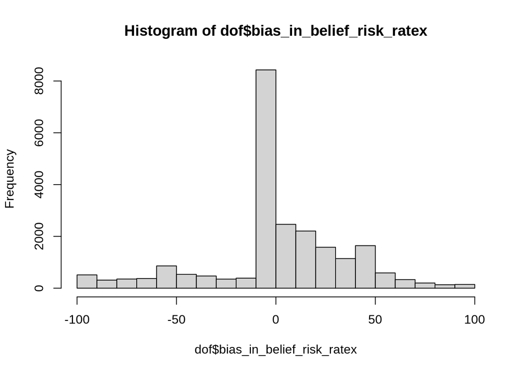

```r
# dof %<>% rowwise() %>% mutate(min_prob_adaptive_fin = min(prob_adaptive_1_fin + (codigo_carrera_1_fin == 0), prob_adaptive_2_fin + (codigo_carrera_2_fin == 0),
#                                                       prob_adaptive_3_fin + (codigo_carrera_3_fin == 0), prob_adaptive_4_fin + (codigo_carrera_4_fin == 0),
#                                                       prob_adaptive_5_fin + (codigo_carrera_5_fin == 0), prob_adaptive_6_fin + (codigo_carrera_6_fin == 0),
#                                                       prob_adaptive_7_fin + (codigo_carrera_7_fin == 0), prob_adaptive_8_fin + (codigo_carrera_8_fin == 0),
#                                                       prob_adaptive_9_fin + (codigo_carrera_9_fin == 0), prob_adaptive_10_fin + (codigo_carrera_10_fin == 0)))

#TODO: Becareful with the sign here, it might not be consistent with the definitions in the paper
dof %<>% mutate(bias_in_belief_ratex_top_true    = as.numeric(prob_top_true) - as.numeric(prob_ratex_top_true)*100,
                bias_in_belief_ratex_bottom_true = as.numeric(prob_bottom_true) - as.numeric(prob_ratex_bottom_true)*100)
#TODO: review this definition
dof %<>% mutate(bias_in_belief_overall_ratex =  as.numeric(prob_any_pref) - as.numeric(overall_prob_ratex_fin)*100,
                bias_in_belief_risk_ratex =  (100 - as.numeric(prob_any_pref)) - (1 - as.numeric(overall_prob_ratex_fin))*100)
hist(dof$bias_in_belief_risk_ratex)
```

```r
# ELIMINAR PACES HABILITADOS
paces <- read.csv(paste(dropbox_dir, "Mistakes/Code/Python/Cartillas/data/2022/habilitados_pace_v2.csv", sep=''), sep=',', header=TRUE)
paces %<>% mutate(habilitado = ifelse(criterio_1 == 1 & criterio_2 == 1 & criterio_3 == 1, 1, 0))
paces_ids <- paces %>% filter(habilitado == 1) %>% pull(mrun)
dof %<>% filter(!(MRUN %in% paces_ids))
```

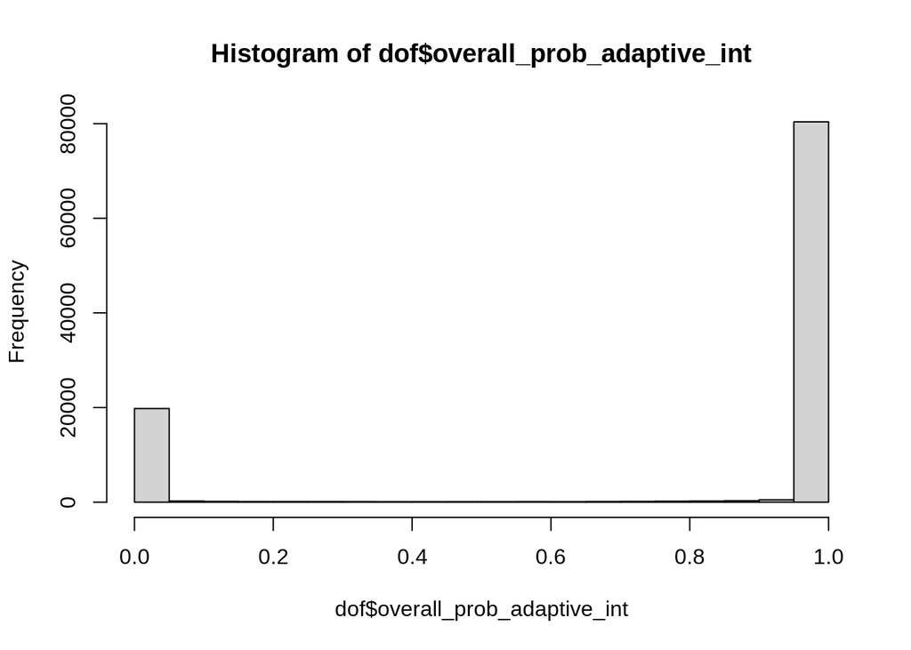

```r
hist(dof$overall_prob_adaptive_int)
```

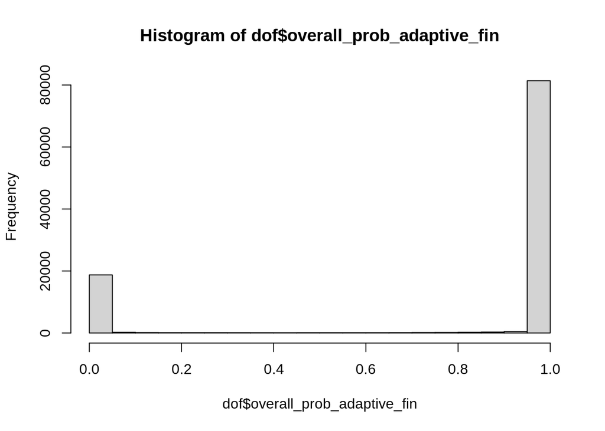

```r
hist(dof$overall_prob_adaptive_fin)
```

## Tables from paper

```r
path_draft_tables = paste(dropbox_dir, "Mistakes_in_college_admissions/mistakes_and_warnings/documents/draft_2022/tables_in_paper/", sep = "")
```

```r
dof %<>% mutate(open_label = ifelse(open == 1, "Yes", ifelse(open == 0, "No", NA)))
dof %<>% mutate(treatment_label = ifelse(treatment == 1, "T1",
                                         ifelse(treatment == 2, "T2",
                                                ifelse(treatment == 3, "T3",
                                                       ifelse(treatment == 4, "T4", NA)))))
dof %<>% mutate(treatment_combined = treatment,
                treatment_combined = ifelse(treatment == 2 | treatment == 3, 5, treatment))
table(dof$treatment_combined)
```

```
##
##     1     4     5
## 25758 25826 51821
```

#Creating some mistake variables

```r
dof %<>% mutate(reduced_mistakes = ifelse(changed == 1 & valid_apps_before < valid_apps_after, 1, 0),
                not_increased_mistakes = ifelse(changed == 1 & valid_apps_before <= valid_apps_after, 1, 0),
               reduced_share_mistakes = ifelse(changed == 1 & valid_apps_before/apps_before < valid_apps_after/apps_after, 1, 0),
                 not_increased_share_mistakes = ifelse(changed == 1 & valid_apps_before/apps_before <= valid_apps_after/apps_after, 1, 0)) %>%
   mutate(overall_prob_ratex_inc = ifelse(overall_prob_ratex_fin > overall_prob_ratex_int, 1, 0),
                                risk_ratex_dec = ifelse((1 - overall_prob_ratex_fin) < (1- overall_prob_ratex_int), 1, 0),
          risk_ratex_inc = ifelse((1 - overall_prob_ratex_fin) > (1- overall_prob_ratex_int), 1, 0),
          risk_ratex_not_inc = ifelse((1 - overall_prob_ratex_fin) <= (1- overall_prob_ratex_int), 1, 0),
                                overall_prob_ratex_inc_abs = overall_prob_ratex_fin - overall_prob_ratex_int,
                                applied_to_top_true_fin_in_top_pref = ifelse(applied_to_top_true_fin == 1 & codigo_carrera_top_true == codigo_carrera_1_fin, 1, 0),
                                not_applied_to_top_true_fin_in_top_pref =  ifelse(applied_to_top_true_fin == 1, 0, 1))
```

### Aggregate statistics by treatment and group

```r
#kable(dof %>% group_by(treatment) %>% dplyr::summarise(n=n(), op = mean(open)*100, c=mean(changed)*100,  inc = mean(increased_valid)*100, dec = mean(decreased_valid)*100, as = mean(assigned_oficial)*100, ent=mean(entered)*100, lef=mean(left)*100, cs=mean(changed_status_ass)*100, cp=mean(changed_program_ass)*100), digits=3)

#kable(dof %>% group_by(treatment) %>% dplyr::summarise(n=n(), op = 100*sd(open)/sqrt(n()), c=100*sd(changed)/sqrt(n()),  inc = 100*sd(increased_valid)/sqrt(n()), dec = 100*sd(decreased_valid)/sqrt(n()), as = 100*sd(assigned_oficial)/sqrt(n()), ent=100*sd(entered)/sqrt(n()), lef=100*sd(left)/sqrt(n()), cs=100*sd(changed_status_ass)/sqrt(n()), cp=100*sd(changed_program_ass)/sqrt(n())), digits=3)

#Create Latex table by hand
table_summary_stats_by_group = dof %>% group_by(treatment_label) %>%
  dplyr::summarise(n   = n(),
                   op  = round(mean(open)*100, 3),
                   c   = round(mean(changed)*100, 3),
                   inc = round(mean(increased_valid)*100, 3),
                   dec = round(mean(decreased_valid)*100, 3),
                   as  = round(mean(assigned_oficial)*100, 3),
                   ent = round(mean(entered)*100, 3),
                   lef = round(mean(left)*100, 3),
                   cs  = round(mean(changed_status_ass)*100, 3),
                   cp  = round(mean(changed_program_ass)*100, 3))
table_summary_stats_by_group
```

```
## # A tibble: 4 × 11
##   treatment_label     n    op     c   inc   dec    as   ent   lef    cs    cp
##   <chr>           <int> <dbl> <dbl> <dbl> <dbl> <dbl> <dbl> <dbl> <dbl> <dbl>
## 1 T1              25758  28.3  10.8  4.16  1.45  77.7 0.617 0.637  1.25  3.76
## 2 T2              25932  28.7  11.3  4.45  1.54  77.6 0.764 0.652  1.42  3.59
## 3 T3              25889  28.4  11.7  4.56  1.62  77.7 0.803 0.61   1.41  3.95
## 4 T4              25826  28.7  11.3  4.31  1.64  77.6 0.74  0.635  1.38  3.47
```

```r
table_summary_stats_by_group_stderr = dof %>% group_by(treatment_label) %>%
  dplyr::summarise(n   = n(),
                   op  = round(100*sd(open)/sqrt(n()), 3),
                   c   = round(100*sd(changed)/sqrt(n()), 3),
                   inc = round(100*sd(increased_valid)/sqrt(n()), 3),
                   dec = round(100*sd(decreased_valid)/sqrt(n()), 3),
                   as  = round(100*sd(assigned_oficial)/sqrt(n()), 3),
                   ent = round(100*sd(entered)/sqrt(n()), 3),
                   lef = round(100*sd(left)/sqrt(n()), 3),
                   cs  = round(100*sd(changed_status_ass)/sqrt(n()), 3),
                   cp  = round(100*sd(changed_program_ass)/sqrt(n()), 3))
table_summary_stats_by_group_stderr
```

```
## # A tibble: 4 × 11
##   treatment_label     n    op     c   inc   dec    as   ent   lef    cs    cp
##   <chr>           <int> <dbl> <dbl> <dbl> <dbl> <dbl> <dbl> <dbl> <dbl> <dbl>
## 1 T1              25758 0.281 0.194 0.124 0.075 0.259 0.049 0.05  0.069 0.119
## 2 T2              25932 0.281 0.197 0.128 0.077 0.259 0.054 0.05  0.073 0.116
## 3 T3              25889 0.28  0.2   0.13  0.079 0.259 0.055 0.048 0.073 0.121
## 4 T4              25826 0.281 0.197 0.126 0.079 0.259 0.053 0.049 0.072 0.114
```

```r
#Write latex table by hand
table_latex_file = file(paste(path_draft_tables,"stats_by_treatment.tex", sep=""))
table_header = c("\\begin{table}[H]",
                 "\\caption{Summary Statistics by Group}",
                 "\\label{tab:table_treatment_stats}",
                 "\\centerline{",
                 "\\scalebox{0.7}{",
                 "\\begin{tabular}{lcccccccccc}",
                 "\\toprule",
                 "& & & \\multicolumn{3}{c}{Application} & \\multicolumn{5}{c}{Assignment} \\\\",
                 "\\cmidrule(lr){4-6}\\cmidrule(lr){7-11}")
table_columns = paste("Treatment",
                      "Total",
                      "\\makecell*[c]{Opened [\\%]}",
                      "Modified [\\%]",
                      "\\makecell*[c]{Increased [\\%]}",
                      "\\makecell*[c]{Decreased [\\%]}",
                      "Assigned [\\%]",
                      "Entered [\\%]",
                      "Left [\\%]",
                      "\\makecell*[c]{Changed  \\\\ status [\\%]}",
                      "\\makecell*[c]{Changed  \\\\ program [\\%]}",
                      sep = " & ")
table_body = paste(table_columns, "\\\\" ," \\midrule")

space = '\\\\[0pt]'
table_stats = table_summary_stats_by_group
table_sterr_stats = table_summary_stats_by_group_stderr
#Fill table body
for(i in 1:nrow(table_stats)){
  row = c()
  for(j in 1:ncol(table_stats)){
    row_stat = table_stats[i,j]
    if(j == 1){
      row = row_stat
    }
    else{
      row = paste(row, "&", row_stat)
    }
  }
  row = paste(row, space)
  table_body = c(table_body, row)
  # Paste row for standard errors
  row = c()
  for(j in 1:ncol(table_sterr_stats)){
    row_stat = table_sterr_stats[i,j]
    if(j != 1){
      if(j == 2){
        row = paste(row, "&", "")
      }else{
        row = paste(row, "&", paste("(",row_stat,")",sep=""))
      }
    }
  }
  row = paste(row, space)
  table_body = c(table_body, row)
}

table_footer = c("\\bottomrule",
                 "\\end{tabular}",
                 "}}",
                 "{\\scriptsize Note: Opened is a binary variable equal to 1 if the student opened the personalized website, 0 otherwise. Modified is a binary variable equal to 1 if the student modified its application after the personalized websites were sent, 0 otherwise. Increased (decreased) is a binary variable equal to 1 if the student increased (decreased) the number of valid applications in their list, 0 otherwise. Assigned is a binary variable equal to 1 if the student resulted assigned at the end of the process, 0 otherwise. Entered (left) is a binary variable equal to 1 if the student resulted unassigned (assigned) given their list of preferences before the intervention and (un)assigned  given their preferenes after the intervention, 0 otherwise. Changed status (program) is a binary variable equal to 1 if the student changed their status (program) of assignment considering the list of preferences submitted before and after the intervention. Standard errors reported in parenthesis.}",
                 "\\end{table}")
table_latex_code = c(table_header, table_body, table_footer)
writeLines(table_latex_code, table_latex_file)
close(table_latex_file)
```

### Aggregate statistics by group and open

```r
#kable(dof %>% group_by(treatment, open) %>% dplyr::summarise(n=n(), c=mean(changed)*100,  inc = mean(increased_valid)*100, dec = mean(decreased_valid)*100, ent=mean(entered)*100, lef=mean(left)*100, cs=mean(changed_status_ass)*100, cp=mean(changed_program_ass)*100), digits=3)

#kable(dof %>% group_by(treatment, open) %>% dplyr::summarise(n=n(), c=sd(changed),  inc = sd(increased_valid), dec = sd(decreased_valid), ent=sd(entered), lef=sd(left), cs=sd(changed_status_ass), cp=sd(changed_program_ass)), digits=3)

#Create Latex table by hand
table_summary_stats_by_group = dof %>% group_by(treatment_label, open_label) %>%
dplyr::summarise(n   = n(),
                 c   = round(mean(changed)*100,3),
                 inc = round(mean(increased_valid)*100,3),
                 dec = round(mean(decreased_valid)*100,3),
                 ent = round(mean(entered)*100,3),
                 lef = round(mean(left)*100,3),
                 cs  = round(mean(changed_status_ass)*100,3),
                 cp  = round(mean(changed_program_ass)*100,3))
table_summary_stats_by_group
```

```
## # A tibble: 8 × 10
## # Groups:   treatment_label [4]
##   treatment_label open_label     n     c   inc   dec   ent   lef    cs    cp
##   <chr>           <chr>      <int> <dbl> <dbl> <dbl> <dbl> <dbl> <dbl> <dbl>
## 1 T1              No         18462  10.0  3.88  1.32 0.59  0.677  1.27  3.62
## 2 T1              Yes         7296  13.0  4.85  1.80 0.685 0.535  1.22  4.13
## 3 T2              No         18495  10.0  4.10  1.32 0.692 0.649  1.34  3.41
## 4 T2              Yes         7437  14.6  5.34  2.10 0.941 0.659  1.6   4.03
## 5 T3              No         18547  10.5  4.15  1.48 0.706 0.566  1.27  3.66
## 6 T3              Yes         7342  14.8  5.60  1.98 1.05  0.722  1.77  4.67
## 7 T4              No         18416  10.3  4.04  1.56 0.744 0.624  1.37  3.31
## 8 T4              Yes         7410  13.7  4.95  1.85 0.729 0.661  1.39  3.87
```

```r
table_summary_stats_by_group_stderr = dof %>% group_by(treatment_label, open_label) %>%
  dplyr::summarise(n   = n(),
                   c   = round(100*sd(changed)/sqrt(n()), 3),
                   inc = round(100*sd(increased_valid)/sqrt(n()), 3),
                   dec = round(100*sd(decreased_valid)/sqrt(n()), 3),
                   ent = round(100*sd(entered)/sqrt(n()), 3),
                   lef = round(100*sd(left)/sqrt(n()), 3),
                   cs  = round(100*sd(changed_status_ass)/sqrt(n()), 3),
                   cp  = round(100*sd(changed_program_ass)/sqrt(n()), 3))
table_summary_stats_by_group_stderr
```

```
## # A tibble: 8 × 10
## # Groups:   treatment_label [4]
##   treatment_label open_label     n     c   inc   dec   ent   lef    cs    cp
##   <chr>           <chr>      <int> <dbl> <dbl> <dbl> <dbl> <dbl> <dbl> <dbl>
## 1 T1              No         18462 0.221 0.142 0.084 0.056 0.06  0.082 0.137
## 2 T1              Yes         7296 0.393 0.252 0.155 0.097 0.085 0.129 0.233
## 3 T2              No         18495 0.221 0.146 0.084 0.061 0.059 0.085 0.133
## 4 T2              Yes         7437 0.409 0.261 0.166 0.112 0.094 0.146 0.228
## 5 T3              No         18547 0.225 0.146 0.089 0.061 0.055 0.082 0.138
## 6 T3              Yes         7342 0.414 0.268 0.162 0.119 0.099 0.154 0.246
## 7 T4              No         18416 0.224 0.145 0.091 0.063 0.058 0.086 0.132
## 8 T4              Yes         7410 0.4   0.252 0.157 0.099 0.094 0.136 0.224
```

```r
#Write latex table by hand
table_latex_file = file(paste(path_draft_tables,"stats_by_treatment_and_open.tex", sep=""))
table_header = c("\\begin{table}[H]",
                 "\\caption{Summary Statistics by Group and Reception}",
                 "\\label{tab:table_treatment_abrio_stats}",
                 "\\centerline{\\scalebox{0.7}{",
                 "\\begin{tabular}{lcccccccccc}",
                 "\\toprule",
                 "  & & & \\multicolumn{3}{c}{Application} & \\multicolumn{4}{c}{Assignment} \\\\",
                 "\\cmidrule(lr){4-6}\\cmidrule(lr){7-10}")
table_columns = paste("Treatment",
                      "\\makecell*[c]{Opened}",
                      "\\(N\\)",
                      "Modified [\\%]",
                      "\\makecell*[c]{Increased [\\%]}",
                      "\\makecell*[c]{Decreased [\\%]}",
                      "Entered [\\%]",
                      "Left [\\%]",
                      "\\makecell*[c]{Changed  \\\\ status [\\%]}",
                      "\\makecell*[c]{Changed  \\\\ program [\\%]}",
                      sep = " & ")
table_body = paste(table_columns, "\\\\" ," \\midrule")

space = '\\\\[0pt]'
table_stats = table_summary_stats_by_group
table_sterr_stats = table_summary_stats_by_group_stderr
#Fill table body
for(i in 1:nrow(table_stats)){
  row = c()
  for(j in 1:ncol(table_stats)){
    row_stat = table_stats[i,j]
    if(j == 1){
      row = row_stat
    }
    else{
      row = paste(row, "&", row_stat)
    }
  }
  row = paste(row, space)
  table_body = c(table_body, row)
  # Paste row for standard errors
  row = c()
  for(j in 1:ncol(table_sterr_stats)){
    row_stat = table_sterr_stats[i,j]
    if(j != 1){
      if(j == 2 | j == 3){
        row = paste(row, "&", "")
      }else{
        row = paste(row, "&", paste("(",row_stat,")",sep=""))
      }
    }
  }
  row = paste(row, space)
  table_body = c(table_body, row)
}

table_footer = c("\\bottomrule",
                 "\\end{tabular}",
                 "}}",
                 "{\\scriptsize Note: Opened is a binary variable equal to 1 if the student opened the personalized website, 0 otherwise. Modified is a binary variable equal to 1 if the student modified its application after the personalized websites were sent, 0 otherwise. Increased (decreased) is a binary variable equal to 1 if the student increased (decreased) the number of valid applications in their list, 0 otherwise. Entered (left) is a binary variable equal to 1 if the student resulted unassigned (assigned) given their list of preferences before the intervention and (un)assigned  given their preferenes after the intervention, 0 otherwise. Changed status (program) is a binary variable equal to 1 if the student changed their status (program) of assignment considering the list of preferences submitted before and after the intervention. Standard errors reported in parenthesis.}",
                 "\\end{table}")
table_latex_code = c(table_header, table_body, table_footer)
writeLines(table_latex_code, table_latex_file)
close(table_latex_file)
```

```r
dof %<>% mutate(decreased_invalid = ifelse(apps_before - valid_apps_before > apps_after - valid_apps_after, 1, 0 ))
```

```r
reg_changed <- glm(changed ~ factor(treatment), family="binomial", data=dof %>% subset(open==1))
summary(reg_changed)
```

```
##
## Call:
## glm(formula = changed ~ factor(treatment), family = "binomial",
##     data = dof %>% subset(open == 1))
##
## Deviance Residuals:
##     Min       1Q   Median       3Q      Max
## -0.5658  -0.5613  -0.5437  -0.5270   2.0213
##
## Coefficients:
##                    Estimate Std. Error z value Pr(>|z|)
## (Intercept)        -1.90397    0.03485 -54.632  < 2e-16 ***
## factor(treatment)2  0.13570    0.04790   2.833  0.00461 **
## factor(treatment)3  0.15293    0.04791   3.192  0.00141 **
## factor(treatment)4  0.06676    0.04851   1.376  0.16876
## ---
## Signif. codes:  0 '***' 0.001 '**' 0.01 '*' 0.05 '.' 0.1 ' ' 1
##
## (Dispersion parameter for binomial family taken to be 1)
##
##     Null deviance: 23903  on 29484  degrees of freedom
## Residual deviance: 23890  on 29481  degrees of freedom
## AIC: 23898
##
## Number of Fisher Scoring iterations: 4
```

```r
reg_inc <- glm(increased_valid ~ factor(treatment), family="binomial", data=dof %>% subset(open==1))
summary(reg_inc)
```

```
##
## Call:
## glm(formula = increased_valid ~ factor(treatment), family = "binomial",
##     data = dof %>% subset(open == 1))
##
## Deviance Residuals:
##     Min       1Q   Median       3Q      Max
## -0.3394  -0.3312  -0.3187  -0.3154   2.4600
##
## Coefficients:
##                    Estimate Std. Error z value Pr(>|z|)
## (Intercept)        -2.97605    0.05448 -54.622   <2e-16 ***
## factor(treatment)2  0.10062    0.07503   1.341   0.1799
## factor(treatment)3  0.15088    0.07447   2.026   0.0428 *
## factor(treatment)4  0.02162    0.07639   0.283   0.7771
## ---
## Signif. codes:  0 '***' 0.001 '**' 0.01 '*' 0.05 '.' 0.1 ' ' 1
##
## (Dispersion parameter for binomial family taken to be 1)
##
##     Null deviance: 12027  on 29484  degrees of freedom
## Residual deviance: 12021  on 29481  degrees of freedom
## AIC: 12029
##
## Number of Fisher Scoring iterations: 5
```

```r
reg_dec <- glm(decreased_valid ~ factor(treatment), family="binomial", data=dof %>% subset(open==1))
summary(reg_dec)
```

```
##
## Call:
## glm(formula = decreased_valid ~ factor(treatment), family = "binomial",
##     data = dof %>% subset(open == 1))
##
## Deviance Residuals:
##     Min       1Q   Median       3Q      Max
## -0.2059  -0.1997  -0.1932  -0.1904   2.8354
##
## Coefficients:
##                    Estimate Std. Error z value Pr(>|z|)
## (Intercept)        -4.00177    0.08815 -45.395   <2e-16 ***
## factor(treatment)2  0.15860    0.11966   1.325    0.185
## factor(treatment)3  0.09708    0.12168   0.798    0.425
## factor(treatment)4  0.02982    0.12331   0.242    0.809
## ---
## Signif. codes:  0 '***' 0.001 '**' 0.01 '*' 0.05 '.' 0.1 ' ' 1
##
## (Dispersion parameter for binomial family taken to be 1)
##
##     Null deviance: 5619.5  on 29484  degrees of freedom
## Residual deviance: 5617.4  on 29481  degrees of freedom
## AIC: 5625.4
##
## Number of Fisher Scoring iterations: 6
```

```r
reg_st_ass <- glm(changed_status_ass ~ factor(treatment), family="binomial", data=dof %>% subset(open==1))
summary(reg_st_ass)
```

```
##
## Call:
## glm(formula = changed_status_ass ~ factor(treatment), family = "binomial",
##     data = dof %>% subset(open == 1))
##
## Deviance Residuals:
##     Min       1Q   Median       3Q      Max
## -0.1890  -0.1796  -0.1673  -0.1567   2.9686
##
## Coefficients:
##                    Estimate Std. Error z value Pr(>|z|)
## (Intercept)         -4.3942     0.1067 -41.201  < 2e-16 ***
## factor(treatment)2   0.2752     0.1411   1.950  0.05116 .
## factor(treatment)3   0.3782     0.1386   2.729  0.00635 **
## factor(treatment)4   0.1323     0.1457   0.908  0.36372
## ---
## Signif. codes:  0 '***' 0.001 '**' 0.01 '*' 0.05 '.' 0.1 ' ' 1
##
## (Dispersion parameter for binomial family taken to be 1)
##
##     Null deviance: 4582.1  on 29484  degrees of freedom
## Residual deviance: 4573.4  on 29481  degrees of freedom
## AIC: 4581.4
##
## Number of Fisher Scoring iterations: 7
```

```r
reg_pr_ass <- glm(changed_program_ass ~ factor(treatment), family="binomial", data=dof %>% subset(open==1))
summary(reg_pr_ass)
```

```
##
## Call:
## glm(formula = changed_program_ass ~ factor(treatment), family = "binomial",
##     data = dof %>% subset(open == 1))
##
## Deviance Residuals:
##     Min       1Q   Median       3Q      Max
## -0.3093  -0.2903  -0.2870  -0.2811   2.5499
##
## Coefficients:
##                    Estimate Std. Error z value Pr(>|z|)
## (Intercept)        -3.14584    0.05887 -53.441   <2e-16 ***
## factor(treatment)2 -0.02342    0.08330  -0.281    0.779
## factor(treatment)3  0.13005    0.08077   1.610    0.107
## factor(treatment)4 -0.06576    0.08420  -0.781    0.435
## ---
## Signif. codes:  0 '***' 0.001 '**' 0.01 '*' 0.05 '.' 0.1 ' ' 1
##
## (Dispersion parameter for binomial family taken to be 1)
##
##     Null deviance: 10229  on 29484  degrees of freedom
## Residual deviance: 10223  on 29481  degrees of freedom
## AIC: 10231
##
## Number of Fisher Scoring iterations: 6
```

```r
reg_ent <- glm(entered ~ factor(treatment), family="binomial", data=dof %>% subset(open==1))
summary(reg_ent)
```

```
##
## Call:
## glm(formula = entered ~ factor(treatment), family = "binomial",
##     data = dof %>% subset(open == 1))
##
## Deviance Residuals:
##     Min       1Q   Median       3Q      Max
## -0.1452  -0.1375  -0.1210  -0.1173   3.1569
##
## Coefficients:
##                    Estimate Std. Error z value Pr(>|z|)
## (Intercept)        -4.97618    0.14189 -35.071   <2e-16 ***
## factor(treatment)2  0.31991    0.18589   1.721   0.0853 .
## factor(treatment)3  0.42916    0.18237   2.353   0.0186 *
## factor(treatment)4  0.06189    0.19694   0.314   0.7533
## ---
## Signif. codes:  0 '***' 0.001 '**' 0.01 '*' 0.05 '.' 0.1 ' ' 1
##
## (Dispersion parameter for binomial family taken to be 1)
##
##     Null deviance: 2892.5  on 29484  degrees of freedom
## Residual deviance: 2884.7  on 29481  degrees of freedom
## AIC: 2892.7
##
## Number of Fisher Scoring iterations: 7
```

```r
reg_lft <- glm(left ~ factor(treatment), family="binomial", data=dof %>% subset(open==1))
summary(reg_lft)
```

```
##
## Call:
## glm(formula = left ~ factor(treatment), family = "binomial",
##     data = dof %>% subset(open == 1))
##
## Deviance Residuals:
##     Min       1Q   Median       3Q      Max
## -0.1204  -0.1152  -0.1150  -0.1035   3.2347
##
## Coefficients:
##                    Estimate Std. Error z value Pr(>|z|)
## (Intercept)         -5.2262     0.1606 -32.550   <2e-16 ***
## factor(treatment)2   0.2104     0.2152   0.977    0.328
## factor(treatment)3   0.3023     0.2116   1.429    0.153
## factor(treatment)4   0.2140     0.2152   0.994    0.320
## ---
## Signif. codes:  0 '***' 0.001 '**' 0.01 '*' 0.05 '.' 0.1 ' ' 1
##
## (Dispersion parameter for binomial family taken to be 1)
##
##     Null deviance: 2295.7  on 29484  degrees of freedom
## Residual deviance: 2293.5  on 29481  degrees of freedom
## AIC: 2301.5
##
## Number of Fisher Scoring iterations: 8
```

```r
reg_top_true <- glm(not_applied_to_top_true_fin_in_top_pref ~ factor(treatment), family="binomial", data=dof %>% subset(open==1) %>% subset(prob_ratex_top_true > 0.0))
summary(reg_top_true)
```

```
##
## Call:
## glm(formula = not_applied_to_top_true_fin_in_top_pref ~ factor(treatment),
##     family = "binomial", data = dof %>% subset(open == 1) %>%
##         subset(prob_ratex_top_true > 0))
##
## Deviance Residuals:
##     Min       1Q   Median       3Q      Max
## -0.5719  -0.5653  -0.5543  -0.5007   2.0681
##
## Coefficients:
##                    Estimate Std. Error z value Pr(>|z|)
## (Intercept)        -1.75307    0.07621 -23.003   <2e-16 ***
## factor(treatment)2  0.02506    0.10856   0.231   0.8175
## factor(treatment)3 -0.26013    0.11434  -2.275   0.0229 *
## factor(treatment)4 -0.04233    0.11036  -0.384   0.7013
## ---
## Signif. codes:  0 '***' 0.001 '**' 0.01 '*' 0.05 '.' 0.1 ' ' 1
##
## (Dispersion parameter for binomial family taken to be 1)
##
##     Null deviance: 4273.0  on 5282  degrees of freedom
## Residual deviance: 4265.3  on 5279  degrees of freedom
## AIC: 4273.3
##
## Number of Fisher Scoring iterations: 4
```

```r
reg_over_confidence <- glm(risk_ratex_dec ~ factor(treatment), family="binomial", data=dof %>% subset(open==1))
summary(reg_over_confidence)
```

```
##
## Call:
## glm(formula = risk_ratex_dec ~ factor(treatment), family = "binomial",
##     data = dof %>% subset(open == 1))
##
## Deviance Residuals:
##     Min       1Q   Median       3Q      Max
## -0.2334  -0.2191  -0.2104  -0.2087   2.7703
##
## Coefficients:
##                    Estimate Std. Error z value Pr(>|z|)
## (Intercept)        -3.81554    0.08068 -47.292   <2e-16 ***
## factor(treatment)2  0.09796    0.11104   0.882   0.3777
## factor(treatment)3  0.22626    0.10828   2.089   0.0367 *
## factor(treatment)4  0.01631    0.11323   0.144   0.8854
## ---
## Signif. codes:  0 '***' 0.001 '**' 0.01 '*' 0.05 '.' 0.1 ' ' 1
##
## (Dispersion parameter for binomial family taken to be 1)
##
##     Null deviance: 6558.0  on 29433  degrees of freedom
## Residual deviance: 6552.5  on 29430  degrees of freedom
##   (51 observations deleted due to missingness)
## AIC: 6560.5
##
## Number of Fisher Scoring iterations: 6
```

```r
#TODO: CHECK THIS!
reg_over_confidence <- glm(risk_ratex_dec ~ factor(treatment), family="binomial", data=dof %>% subset(open==1))
summary(reg_over_confidence)
```

```
##
## Call:
## glm(formula = risk_ratex_dec ~ factor(treatment), family = "binomial",
##     data = dof %>% subset(open == 1))
##
## Deviance Residuals:
##     Min       1Q   Median       3Q      Max
## -0.2334  -0.2191  -0.2104  -0.2087   2.7703
##
## Coefficients:
##                    Estimate Std. Error z value Pr(>|z|)
## (Intercept)        -3.81554    0.08068 -47.292   <2e-16 ***
## factor(treatment)2  0.09796    0.11104   0.882   0.3777
## factor(treatment)3  0.22626    0.10828   2.089   0.0367 *
## factor(treatment)4  0.01631    0.11323   0.144   0.8854
## ---
## Signif. codes:  0 '***' 0.001 '**' 0.01 '*' 0.05 '.' 0.1 ' ' 1
##
## (Dispersion parameter for binomial family taken to be 1)
##
##     Null deviance: 6558.0  on 29433  degrees of freedom
## Residual deviance: 6552.5  on 29430  degrees of freedom
##   (51 observations deleted due to missingness)
## AIC: 6560.5
##
## Number of Fisher Scoring iterations: 6
```

```r
reg_over_confidence <- glm(risk_ratex_inc ~ factor(treatment), family="binomial", data=dof %>% subset(open==1))
summary(reg_over_confidence)
```

```
##
## Call:
## glm(formula = risk_ratex_inc ~ factor(treatment), family = "binomial",
##     data = dof %>% subset(open == 1))
##
## Deviance Residuals:
##     Min       1Q   Median       3Q      Max
## -0.1199  -0.1174  -0.1110  -0.0862   3.3460
##
## Coefficients:
##                    Estimate Std. Error z value Pr(>|z|)
## (Intercept)         -5.5940     0.1928 -29.014  < 2e-16 ***
## factor(treatment)2   0.6207     0.2386   2.602  0.00928 **
## factor(treatment)3   0.5071     0.2440   2.078  0.03768 *
## factor(treatment)4   0.6625     0.2370   2.795  0.00519 **
## ---
## Signif. codes:  0 '***' 0.001 '**' 0.01 '*' 0.05 '.' 0.1 ' ' 1
##
## (Dispersion parameter for binomial family taken to be 1)
##
##     Null deviance: 2153  on 29433  degrees of freedom
## Residual deviance: 2143  on 29430  degrees of freedom
##   (51 observations deleted due to missingness)
## AIC: 2151
##
## Number of Fisher Scoring iterations: 8
```

```r
reg_over_confidence <- lm(overall_prob_ratex_fin ~ factor(treatment), data=dof %>% subset(open==1))
summary(reg_over_confidence)
```

```
##
## Call:
## lm(formula = overall_prob_ratex_fin ~ factor(treatment), data = dof %>%
##     subset(open == 1))
##
## Residuals:
##     Min      1Q  Median      3Q     Max
## -0.7938  0.2022  0.2110  0.2130  0.2136
##
## Coefficients:
##                     Estimate Std. Error t value Pr(>|t|)
## (Intercept)         0.793797   0.004674 169.836   <2e-16 ***
## factor(treatment)2 -0.004796   0.006580  -0.729    0.466
## factor(treatment)3 -0.006753   0.006600  -1.023    0.306
## factor(treatment)4 -0.007424   0.006585  -1.127    0.260
## ---
## Signif. codes:  0 '***' 0.001 '**' 0.01 '*' 0.05 '.' 0.1 ' ' 1
##
## Residual standard error: 0.3989 on 29430 degrees of freedom
##   (51 observations deleted due to missingness)
## Multiple R-squared:  5.266e-05,  Adjusted R-squared:  -4.927e-05
## F-statistic: 0.5167 on 3 and 29430 DF,  p-value: 0.6708
```

```r
reg_over_confidence <- lm(overall_prob_ratex_fin ~ factor(treatment), data=dof %>% subset(open==1) %>% filter(changed == 1))
summary(reg_over_confidence)
```

```
##
## Call:
## lm(formula = overall_prob_ratex_fin ~ factor(treatment), data = dof %>%
##     subset(open == 1) %>% filter(changed == 1))
##
## Residuals:
##     Min      1Q  Median      3Q     Max
## -0.8514  0.1486  0.1492  0.1628  0.1780
##
## Coefficients:
##                      Estimate Std. Error t value Pr(>|t|)
## (Intercept)         0.8508384  0.0115931  73.392   <2e-16 ***
## factor(treatment)2 -0.0288223  0.0158648  -1.817   0.0693 .
## factor(treatment)3  0.0005521  0.0158580   0.035   0.9722
## factor(treatment)4 -0.0136383  0.0161026  -0.847   0.3971
## ---
## Signif. codes:  0 '***' 0.001 '**' 0.01 '*' 0.05 '.' 0.1 ' ' 1
##
## Residual standard error: 0.3566 on 4130 degrees of freedom
## Multiple R-squared:  0.001161,   Adjusted R-squared:  0.0004359
## F-statistic: 1.601 on 3 and 4130 DF,  p-value: 0.187
```

```r
#Combining treatments 2 and 3 to get more power
reg_over_confidence <- lm(overall_prob_ratex_fin ~ factor(treatment_combined), data=dof %>% subset(open==1) %>% filter(changed == 1) %>% filter(valid_apps_before > 0) %>% filter(misfit == 1))
summary(reg_over_confidence)
```

```
##
## Call:
## lm(formula = overall_prob_ratex_fin ~ factor(treatment_combined),
##     data = dof %>% subset(open == 1) %>% filter(changed == 1) %>%
##         filter(valid_apps_before > 0) %>% filter(misfit == 1))
##
## Residuals:
##      Min       1Q   Median       3Q      Max
## -0.91925  0.08075  0.08075  0.08145  0.08762
##
## Coefficients:
##                               Estimate Std. Error t value Pr(>|t|)
## (Intercept)                  0.9185519  0.0089628 102.485   <2e-16 ***
## factor(treatment_combined)4 -0.0061695  0.0124715  -0.495    0.621
## factor(treatment_combined)5  0.0007023  0.0107840   0.065    0.948
## ---
## Signif. codes:  0 '***' 0.001 '**' 0.01 '*' 0.05 '.' 0.1 ' ' 1
##
## Residual standard error: 0.2615 on 3658 degrees of freedom
## Multiple R-squared:  0.0001221,  Adjusted R-squared:  -0.0004245
## F-statistic: 0.2234 on 2 and 3658 DF,  p-value: 0.7998
```

```r
#Including covariates
reg_over_confidence <- lm(overall_prob_ratex_fin ~ factor(treatment) + factor(strata_region) + factor(strata_sexo) + factor(strata_score) + gets_sms, data=dof %>% subset(open==1) %>%  filter(changed == 1) %>% filter(valid_apps_before > 0) %>% filter(misfit == 1 & strata_region != 4))
summary(reg_over_confidence)
```

```
##
## Call:
## lm(formula = overall_prob_ratex_fin ~ factor(treatment) + factor(strata_region) +
##     factor(strata_sexo) + factor(strata_score) + gets_sms, data = dof %>%
##     subset(open == 1) %>% filter(changed == 1) %>% filter(valid_apps_before >
##     0) %>% filter(misfit == 1 & strata_region != 4))
##
## Residuals:
##      Min       1Q   Median       3Q      Max
## -0.97578  0.05016  0.08212  0.10000  0.12774
##
## Coefficients:
##                         Estimate Std. Error t value Pr(>|t|)
## (Intercept)             0.955393   0.041653  22.937  < 2e-16 ***
## factor(treatment)2     -0.002545   0.012361  -0.206   0.8369
## factor(treatment)3      0.006583   0.012262   0.537   0.5914
## factor(treatment)4     -0.006445   0.012443  -0.518   0.6045
## factor(strata_region)2 -0.016953   0.015597  -1.087   0.2772
## factor(strata_region)3 -0.006211   0.017038  -0.365   0.7155
## factor(strata_sexo)2   -0.043256   0.009397  -4.603  4.3e-06 ***
## factor(strata_score)2   0.004816   0.037605   0.128   0.8981
## factor(strata_score)3   0.029144   0.038227   0.762   0.4459
## gets_sms               -0.016477   0.008873  -1.857   0.0634 .
## ---
## Signif. codes:  0 '***' 0.001 '**' 0.01 '*' 0.05 '.' 0.1 ' ' 1
##
## Residual standard error: 0.2605 on 3648 degrees of freedom
## Multiple R-squared:  0.01004,    Adjusted R-squared:  0.007594
## F-statistic: 4.109 on 9 and 3648 DF,  p-value: 2.819e-05
```

```r
reg_over_confidence <- lm(overall_prob_ratex_fin ~ factor(treatment_combined) + factor(strata_region) + factor(strata_sexo) + factor(strata_score) + gets_sms, data=dof %>% subset(open==1) %>% filter(changed == 1) %>% filter(valid_apps_before > 0) %>% filter(misfit == 1 & strata_region != 4))
summary(reg_over_confidence)
```

```
##
## Call:
## lm(formula = overall_prob_ratex_fin ~ factor(treatment_combined) +
##     factor(strata_region) + factor(strata_sexo) + factor(strata_score) +
##     gets_sms, data = dof %>% subset(open == 1) %>% filter(changed ==
##     1) %>% filter(valid_apps_before > 0) %>% filter(misfit ==
##     1 & strata_region != 4))
##
## Residuals:
##      Min       1Q   Median       3Q      Max
## -0.98044  0.05448  0.08122  0.09984  0.12785
##
## Coefficients:
##                              Estimate Std. Error t value Pr(>|t|)
## (Intercept)                  0.955082   0.041648  22.932  < 2e-16 ***
## factor(treatment_combined)4 -0.006442   0.012442  -0.518   0.6047
## factor(treatment_combined)5  0.002097   0.010759   0.195   0.8455
## factor(strata_region)2      -0.016517   0.015586  -1.060   0.2893
## factor(strata_region)3      -0.005880   0.017032  -0.345   0.7299
## factor(strata_sexo)2        -0.043255   0.009396  -4.603  4.3e-06 ***
## factor(strata_score)2        0.004854   0.037603   0.129   0.8973
## factor(strata_score)3        0.029141   0.038225   0.762   0.4459
## gets_sms                    -0.016715   0.008867  -1.885   0.0595 .
## ---
## Signif. codes:  0 '***' 0.001 '**' 0.01 '*' 0.05 '.' 0.1 ' ' 1
##
## Residual standard error: 0.2605 on 3649 degrees of freedom
## Multiple R-squared:  0.009878,   Adjusted R-squared:  0.007708
## F-statistic: 4.551 on 8 and 3649 DF,  p-value: 1.577e-05
```

```r
stargazer(reg_changed, reg_inc, reg_dec, reg_ent, reg_lft, reg_st_ass, reg_pr_ass, keep.stat="n",
          add.lines = list(c(2,round(exp(coef(reg_changed))[2],3), round(exp(coef(reg_inc))[2],3), round(exp(coef(reg_dec))[2],3), round(exp(coef(reg_ent))[2],3), round(exp(coef(reg_lft))[2],3),  round(exp(coef(reg_st_ass))[2],3), round(exp(coef(reg_pr_ass))[2],3)),
                           c(3,round(exp(coef(reg_changed))[3],3), round(exp(coef(reg_inc))[3],3), round(exp(coef(reg_dec))[3],3), round(exp(coef(reg_ent))[3],3), round(exp(coef(reg_lft))[3],3), round(exp(coef(reg_st_ass))[3],3), round(exp(coef(reg_pr_ass))[3],3)),
                           c(4,round(exp(coef(reg_changed))[4],3), round(exp(coef(reg_inc))[4],3), round(exp(coef(reg_dec))[4],3), round(exp(coef(reg_ent))[4],3), round(exp(coef(reg_lft))[4],3), round(exp(coef(reg_st_ass))[4],3), round(exp(coef(reg_pr_ass))[2],3))), digits=3,
                         out = paste(path_draft_tables,"regs_odds_open.tex", sep=""))
```

```
##
## % Table created by stargazer v.5.2.3 by Marek Hlavac, Social Policy Institute. E-mail: marek.hlavac at gmail.com
## % Date and time: Wed, Jun 29, 2022 - 06:03:46 PM
## \begin{table}[!htbp] \centering
##   \caption{}
##   \label{}
## \begin{tabular}{@{\extracolsep{5pt}}lccccccc}
## \\[-1.8ex]\hline
## \hline \\[-1.8ex]
##  & \multicolumn{7}{c}{\textit{Dependent variable:}} \\
## \cline{2-8}
## \\[-1.8ex] & changed & increased\_valid & decreased\_valid & entered & left & changed\_status\_ass & changed\_program\_ass \\
## \\[-1.8ex] & (1) & (2) & (3) & (4) & (5) & (6) & (7)\\
## \hline \\[-1.8ex]
##  factor(treatment)2 & 0.136$^{***}$ & 0.101 & 0.159 & 0.320$^{*}$ & 0.210 & 0.275$^{*}$ & $-$0.023 \\
##   & (0.048) & (0.075) & (0.120) & (0.186) & (0.215) & (0.141) & (0.083) \\
##   & & & & & & & \\
##  factor(treatment)3 & 0.153$^{***}$ & 0.151$^{**}$ & 0.097 & 0.429$^{**}$ & 0.302 & 0.378$^{***}$ & 0.130 \\
##   & (0.048) & (0.074) & (0.122) & (0.182) & (0.212) & (0.139) & (0.081) \\
##   & & & & & & & \\
##  factor(treatment)4 & 0.067 & 0.022 & 0.030 & 0.062 & 0.214 & 0.132 & $-$0.066 \\
##   & (0.049) & (0.076) & (0.123) & (0.197) & (0.215) & (0.146) & (0.084) \\
##   & & & & & & & \\
##  Constant & $-$1.904$^{***}$ & $-$2.976$^{***}$ & $-$4.002$^{***}$ & $-$4.976$^{***}$ & $-$5.226$^{***}$ & $-$4.394$^{***}$ & $-$3.146$^{***}$ \\
##   & (0.035) & (0.054) & (0.088) & (0.142) & (0.161) & (0.107) & (0.059) \\
##   & & & & & & & \\
## \hline \\[-1.8ex]
## 2 & 1.145 & 1.106 & 1.172 & 1.377 & 1.234 & 1.317 & 0.977 \\
## 3 & 1.165 & 1.163 & 1.102 & 1.536 & 1.353 & 1.46 & 1.139 \\
## 4 & 1.069 & 1.022 & 1.03 & 1.064 & 1.239 & 1.141 & 0.977 \\
## Observations & 29,485 & 29,485 & 29,485 & 29,485 & 29,485 & 29,485 & 29,485 \\
## \hline
## \hline \\[-1.8ex]
## \textit{Note:}  & \multicolumn{7}{r}{$^{*}$p$<$0.1; $^{**}$p$<$0.05; $^{***}$p$<$0.01} \\
## \end{tabular}
## \end{table}
```

```r
#TODO: this table has to be pasted by hand in the paper. It is easy though.
```

### Aggregate statistics by group and message type

```r
# kable(dof %>% group_by(treatment, open, general_message) %>% dplyr::summarise(n=n(), c=mean(changed)*100,  inc = mean(increased_valid)*100, dec = mean(decreased_valid)*100, as = mean(assigned_oficial)*100, ent=mean(entered)*100, lef=mean(left)*100, cs=mean(changed_status_ass)*100, cp=mean(changed_program_ass)*100), digits=3)

# kable(dof %>% group_by(treatment, open, general_message) %>% dplyr::summarise(n=n(), c=sd(changed),  inc = sd(increased_valid), dec = sd(decreased_valid), as = sd(assigned_oficial), ent=sd(entered), lef=sd(left), cs=sd(changed_status_ass), cp=sd(changed_program_ass)), digits=3)

#Create Latex table by hand
table_summary_stats_by_group = dof %>% group_by(treatment_label, open_label, general_message) %>%
dplyr::summarise(n   = n(),
                 c   = round(mean(changed)*100,3),
                 inc = round(mean(increased_valid)*100,3),
                 dec = round(mean(decreased_valid)*100,3),
                 as = round(mean(assigned_oficial)*100,3),
                 ent = round(mean(entered)*100,3),
                 lef = round(mean(left)*100,3),
                 cs  = round(mean(changed_status_ass)*100,3),
                 cp  = round(mean(changed_program_ass)*100,3))
table_summary_stats_by_group
```

```
## # A tibble: 24 × 12
## # Groups:   treatment_label, open_label [8]
##    treatment_label open_label general_message     n     c   inc   dec    as
##    <chr>           <chr>                <int> <int> <dbl> <dbl> <dbl> <dbl>
##  1 T1              No                       1  1544  8.03  3.04 1.10   99.9
##  2 T1              No                       2  4271  7.82  2.95 0.468  11.2
##  3 T1              No                       3 12647 11.0   4.30 1.63   96.5
##  4 T1              Yes                      1   604 10.4   4.64 1.99   99.8
##  5 T1              Yes                      2  1529 11.1   4.19 0.327  11.5
##  6 T1              Yes                      3  5163 13.8   5.08 2.21   97.2
##  7 T2              No                       1  1538  7.93  3.71 1.10   99.7
##  8 T2              No                       2  4290  8.06  3.17 0.186  11.5
##  9 T2              No                       3 12667 10.9   4.46 1.73   96.4
## 10 T2              Yes                      1   688 10.2   3.78 1.60  100
## # … with 14 more rows, and 4 more variables: ent <dbl>, lef <dbl>, cs <dbl>,
## #   cp <dbl>
```

```r
table_summary_stats_by_group_stderr = dof %>% group_by(treatment_label, open_label, general_message) %>%
  dplyr::summarise(n   = n(),
                   c   = round(100*sd(changed)/sqrt(n()), 3),
                   inc = round(100*sd(increased_valid)/sqrt(n()), 3),
                   dec = round(100*sd(decreased_valid)/sqrt(n()), 3),
                   as = round(100*sd(assigned_oficial)/sqrt(n()), 3),
                   ent = round(100*sd(entered)/sqrt(n()), 3),
                   lef = round(100*sd(left)/sqrt(n()), 3),
                   cs  = round(100*sd(changed_status_ass)/sqrt(n()), 3),
                   cp  = round(100*sd(changed_program_ass)/sqrt(n()), 3))
table_summary_stats_by_group_stderr
```

```
## # A tibble: 24 × 12
## # Groups:   treatment_label, open_label [8]
##    treatment_label open_label general_message     n     c   inc   dec    as
##    <chr>           <chr>                <int> <int> <dbl> <dbl> <dbl> <dbl>
##  1 T1              No                       1  1544 0.692 0.437 0.266 0.092
##  2 T1              No                       2  4271 0.411 0.259 0.104 0.482
##  3 T1              No                       3 12647 0.278 0.18  0.113 0.163
##  4 T1              Yes                      1   604 1.25  0.856 0.568 0.166
##  5 T1              Yes                      2  1529 0.804 0.512 0.146 0.816
##  6 T1              Yes                      3  5163 0.48  0.305 0.205 0.229
##  7 T2              No                       1  1538 0.689 0.482 0.267 0.13
##  8 T2              No                       2  4290 0.416 0.268 0.066 0.488
##  9 T2              No                       3 12667 0.277 0.183 0.116 0.166
## 10 T2              Yes                      1   688 1.15  0.728 0.479 0
## # … with 14 more rows, and 4 more variables: ent <dbl>, lef <dbl>, cs <dbl>,
## #   cp <dbl>
```

```r
#Write latex table by hand
table_latex_file = file(paste(path_draft_tables,"stats_by_treatment_and_open_and_message.tex", sep=""))
table_header = c("\\begin{table}[H]",
                 "\\caption{Summary Statistics by Treatment, Reception and Message Group}",
                 "\\label{tab:table_treatment_stats_by_open_and_message}",
                 "\\centerline{\\scalebox{0.6}{",
                 "\\begin{tabular}{lcccccccccccc}",
                 "\\toprule",
                 "& & & & \\multicolumn{3}{c}{Application} & \\multicolumn{5}{c}{Assignment} \\\\",
                 "\\cmidrule(lr){5-7}\\cmidrule(lr){8-12}")
table_columns = paste("Treatment",
                      "\\makecell*[c]{Open}",
                      "\\makecell*[c]{Group}",
                      "\\(N\\)",
                      "Modified [\\%]",
                      "\\makecell*[c]{Increased [\\%]}",
                      "\\makecell*[c]{Decreased [\\%]}",
                      "Assigned [\\%]",
                      "Entered [\\%]",
                      "Left [\\%]",
                      "\\makecell*[c]{Changed  \\\\ status [\\%]}",
                      "\\makecell*[c]{Changed  \\\\ program [\\%]}",
                      sep = " & ")
table_body = paste(table_columns, "\\\\" ," \\midrule")

space = '\\\\[0pt]'
table_stats = table_summary_stats_by_group
table_sterr_stats = table_summary_stats_by_group_stderr
#Fill table body
ct = 0
for(i in 1:nrow(table_stats)){
  ct = ct + 1
  row = c()
  for(j in 1:ncol(table_stats)){
    row_stat = table_stats[i,j]
    if((j == 1 | j == 2) & ct != 2){
      row_stat = ""
    }
    if(j == 1){
      row = row_stat
    }
    else{
      row = paste(row, "&", row_stat)
    }
  }
  row = paste(row, space)
  table_body = c(table_body, row)
  # Paste row for standard errors
  row = c()
  for(j in 1:ncol(table_sterr_stats)){
    row_stat = table_sterr_stats[i,j]
    if(j != 1){
      if(j == 2 | j == 3 | j == 4){
        row = paste(row, "&", "")
      }else{
        row = paste(row, "&", paste("(",row_stat,")",sep=""))
      }
    }
  }
  row = paste(row, space)
  table_body = c(table_body, row)
  #Include midrules
  if(i%%3==0){
    table_body = c(table_body, "\\midrule")
    ct = 0
  }
}

table_footer = c("\\end{tabular}",
                 "}}",
                 "{\\scriptsize Note: Opened is a binary variable equal to 1 if the student opened the personalized website, 0 otherwise. Modified is a binary variable equal to 1 if the student modified its application after the personalized websites were sent, 0 otherwise. Increased (decreased) is a binary variable equal to 1 if the student increased (decreased) the number of valid applications in their list, 0 otherwise. Assigned is a binary variable equal to 1 if the student resulted assigned at the end of the process, 0 otherwise. Entered (left) is a binary variable equal to 1 if the student resulted unassigned (assigned) given their list of preferences before the intervention and (un)assigned  given their preferenes after the intervention, 0 otherwise. Changed status (program) is a binary variable equal to 1 if the student changed their status (program) of assignment considering the list of preferences submitted before and after the intervention. Standard errors reported in parenthesis.}",
                 "\\end{table}")
table_latex_code = c(table_header, table_body, table_footer)
writeLines(table_latex_code, table_latex_file)
close(table_latex_file)
```

#Regressions and Odd-ratios among openers in Safety group

```r
reg_changed <- glm(changed ~ factor(treatment), family="binomial", data=dof %>% subset(open==1) %>% filter(general_message == 2))
summary(reg_changed)
```

```
##
## Call:
## glm(formula = changed ~ factor(treatment), family = "binomial",
##     data = dof %>% subset(open == 1) %>% filter(general_message ==
##         2))
##
## Deviance Residuals:
##     Min       1Q   Median       3Q      Max
## -0.5535  -0.5213  -0.4855  -0.4849   2.0972
##
## Coefficients:
##                     Estimate Std. Error z value Pr(>|z|)
## (Intercept)        -2.078706   0.081350 -25.553  < 2e-16 ***
## factor(treatment)2  0.280331   0.108514   2.583  0.00978 **
## factor(treatment)3  0.151448   0.110982   1.365  0.17238
## factor(treatment)4 -0.002888   0.114374  -0.025  0.97985
## ---
## Signif. codes:  0 '***' 0.001 '**' 0.01 '*' 0.05 '.' 0.1 ' ' 1
##
## (Dispersion parameter for binomial family taken to be 1)
##
##     Null deviance: 4675.1  on 6270  degrees of freedom
## Residual deviance: 4665.5  on 6267  degrees of freedom
## AIC: 4673.5
##
## Number of Fisher Scoring iterations: 4
```

```r
reg_inc <- glm(increased_valid ~ factor(treatment), family="binomial", data=dof %>% subset(open==1) %>% filter(general_message == 2))
summary(reg_inc)
```

```
##
## Call:
## glm(formula = increased_valid ~ factor(treatment), family = "binomial",
##     data = dof %>% subset(open == 1) %>% filter(general_message ==
##         2))
##
## Deviance Residuals:
##     Min       1Q   Median       3Q      Max
## -0.3138  -0.3043  -0.2924  -0.2596   2.6103
##
## Coefficients:
##                    Estimate Std. Error z value Pr(>|z|)
## (Intercept)        -3.13073    0.12770 -24.516   <2e-16 ***
## factor(treatment)2  0.08159    0.17566   0.464    0.642
## factor(treatment)3  0.14425    0.17358   0.831    0.406
## factor(treatment)4 -0.24252    0.19026  -1.275    0.202
## ---
## Signif. codes:  0 '***' 0.001 '**' 0.01 '*' 0.05 '.' 0.1 ' ' 1
##
## (Dispersion parameter for binomial family taken to be 1)
##
##     Null deviance: 2189.3  on 6270  degrees of freedom
## Residual deviance: 2184.2  on 6267  degrees of freedom
## AIC: 2192.2
##
## Number of Fisher Scoring iterations: 6
```

```r
reg_dec <- glm(decreased_valid ~ factor(treatment), family="binomial", data=dof %>% subset(open==1) %>% filter(general_message == 2))
summary(reg_dec)
```

```
##
## Call:
## glm(formula = decreased_valid ~ factor(treatment), family = "binomial",
##     data = dof %>% subset(open == 1) %>% filter(general_message ==
##         2))
##
## Deviance Residuals:
##     Min       1Q   Median       3Q      Max
## -0.1131  -0.1065  -0.1065  -0.1007   3.3832
##
## Coefficients:
##                    Estimate Std. Error z value Pr(>|z|)
## (Intercept)         -5.7197     0.4479 -12.769   <2e-16 ***
## factor(treatment)2   0.5504     0.5589   0.985    0.325
## factor(treatment)3   0.4377     0.5712   0.766    0.443
## factor(treatment)4   0.6704     0.5489   1.221    0.222
## ---
## Signif. codes:  0 '***' 0.001 '**' 0.01 '*' 0.05 '.' 0.1 ' ' 1
##
## (Dispersion parameter for binomial family taken to be 1)
##
##     Null deviance: 401.63  on 6270  degrees of freedom
## Residual deviance: 399.91  on 6267  degrees of freedom
## AIC: 407.91
##
## Number of Fisher Scoring iterations: 8
```

```r
reg_pr_ass <- glm(changed_program_ass ~ factor(treatment), family="binomial", data=dof %>% subset(open==1) %>% filter(general_message == 2))
summary(reg_pr_ass)
```

```
##
## Call:
## glm(formula = changed_program_ass ~ factor(treatment), family = "binomial",
##     data = dof %>% subset(open == 1) %>% filter(general_message ==
##         2))
##
## Deviance Residuals:
##     Min       1Q   Median       3Q      Max
## -0.0887  -0.0799  -0.0616  -0.0502   3.6549
##
## Coefficients:
##                    Estimate Std. Error z value Pr(>|z|)
## (Intercept)         -5.5367     0.4091 -13.535   <2e-16 ***
## factor(treatment)2  -1.1410     0.8173  -1.396    0.163
## factor(treatment)3  -0.7293     0.7080  -1.030    0.303
## factor(treatment)4  -0.2089     0.6066  -0.344    0.731
## ---
## Signif. codes:  0 '***' 0.001 '**' 0.01 '*' 0.05 '.' 0.1 ' ' 1
##
## (Dispersion parameter for binomial family taken to be 1)
##
##     Null deviance: 223.03  on 6270  degrees of freedom
## Residual deviance: 220.25  on 6267  degrees of freedom
## AIC: 228.25
##
## Number of Fisher Scoring iterations: 9
```

```r
reg_st_ass <- glm(changed_status_ass ~ factor(treatment), family="binomial", data=dof %>% subset(open==1)  %>% filter(general_message == 2))
summary(reg_st_ass)
```

```
##
## Call:
## glm(formula = changed_status_ass ~ factor(treatment), family = "binomial",
##     data = dof %>% subset(open == 1) %>% filter(general_message ==
##         2))
##
## Deviance Residuals:
##     Min       1Q   Median       3Q      Max
## -0.3117  -0.2911  -0.2596  -0.2526   2.6310
##
## Coefficients:
##                    Estimate Std. Error z value Pr(>|z|)
## (Intercept)        -3.42927    0.14666 -23.383   <2e-16 ***
## factor(treatment)2  0.28918    0.19317   1.497   0.1344
## factor(treatment)3  0.42888    0.18843   2.276   0.0228 *
## factor(treatment)4  0.05603    0.20347   0.275   0.7830
## ---
## Signif. codes:  0 '***' 0.001 '**' 0.01 '*' 0.05 '.' 0.1 ' ' 1
##
## (Dispersion parameter for binomial family taken to be 1)
##
##     Null deviance: 2043.4  on 6270  degrees of freedom
## Residual deviance: 2036.4  on 6267  degrees of freedom
## AIC: 2044.4
##
## Number of Fisher Scoring iterations: 6
```

```r
reg_ent <- glm(entered ~ factor(treatment), family="binomial", data=dof %>% subset(open==1)  %>% filter(general_message == 2))
summary(reg_ent)
```

```
##
## Call:
## glm(formula = entered ~ factor(treatment), family = "binomial",
##     data = dof %>% subset(open == 1) %>% filter(general_message ==
##         2))
##
## Deviance Residuals:
##     Min       1Q   Median       3Q      Max
## -0.2804  -0.2749  -0.2301  -0.2213   2.7282
##
## Coefficients:
##                    Estimate Std. Error z value Pr(>|z|)
## (Intercept)        -3.69695    0.16642 -22.214   <2e-16 ***
## factor(treatment)2  0.44016    0.21283   2.068   0.0386 *
## factor(treatment)3  0.48071    0.21154   2.272   0.0231 *
## factor(treatment)4  0.07881    0.22965   0.343   0.7315
## ---
## Signif. codes:  0 '***' 0.001 '**' 0.01 '*' 0.05 '.' 0.1 ' ' 1
##
## (Dispersion parameter for binomial family taken to be 1)
##
##     Null deviance: 1758.0  on 6270  degrees of freedom
## Residual deviance: 1749.6  on 6267  degrees of freedom
## AIC: 1757.6
##
## Number of Fisher Scoring iterations: 6
```

```r
reg_lft <- glm(left ~ factor(treatment), family="binomial", data=dof %>% subset(open==1) %>% filter(general_message == 2))
summary(reg_lft)
```

```
##
## Call:
## glm(formula = left ~ factor(treatment), family = "binomial",
##     data = dof %>% subset(open == 1) %>% filter(general_message ==
##         2))
##
## Deviance Residuals:
##     Min       1Q   Median       3Q      Max
## -0.1333  -0.1268  -0.1186  -0.0939   3.2943
##
## Coefficients:
##                    Estimate Std. Error z value Pr(>|z|)
## (Intercept)        -4.92725    0.30260 -16.283   <2e-16 ***
## factor(treatment)2 -0.49454    0.48483  -1.020    0.308
## factor(treatment)3  0.20875    0.40452   0.516    0.606
## factor(treatment)4 -0.02601    0.42792  -0.061    0.952
## ---
## Signif. codes:  0 '***' 0.001 '**' 0.01 '*' 0.05 '.' 0.1 ' ' 1
##
## (Dispersion parameter for binomial family taken to be 1)
##
##     Null deviance: 514.20  on 6270  degrees of freedom
## Residual deviance: 511.71  on 6267  degrees of freedom
## AIC: 519.71
##
## Number of Fisher Scoring iterations: 8
```

```r
reg_top_true <- glm(not_applied_to_top_true_fin_in_top_pref ~ factor(treatment), family="binomial", data=dof %>% subset(open==1) %>% filter(general_message == 2) %>%
                      subset(prob_ratex_top_true > 0.0))
summary(reg_top_true)
```

```
##
## Call:
## glm(formula = not_applied_to_top_true_fin_in_top_pref ~ factor(treatment),
##     family = "binomial", data = dof %>% subset(open == 1) %>%
##         filter(general_message == 2) %>% subset(prob_ratex_top_true >
##         0))
##
## Deviance Residuals:
##     Min       1Q   Median       3Q      Max
## -0.5137  -0.4556  -0.3640  -0.3593   2.3548
##
## Coefficients:
##                    Estimate Std. Error z value Pr(>|z|)
## (Intercept)         -2.2130     0.3981  -5.559 2.72e-08 ***
## factor(treatment)2   0.2542     0.5121   0.496    0.620
## factor(treatment)3  -0.4951     0.6098  -0.812    0.417
## factor(treatment)4  -0.4680     0.6101  -0.767    0.443
## ---
## Signif. codes:  0 '***' 0.001 '**' 0.01 '*' 0.05 '.' 0.1 ' ' 1
##
## (Dispersion parameter for binomial family taken to be 1)
##
##     Null deviance: 189.53  on 317  degrees of freedom
## Residual deviance: 186.85  on 314  degrees of freedom
## AIC: 194.85
##
## Number of Fisher Scoring iterations: 5
```

```r
#TODO: CHECK THIS!
reg_over_confidence <- glm(risk_ratex_dec ~ factor(treatment), family="binomial", data=dof %>% subset(open==1) %>% filter(general_message == 2))
summary(reg_over_confidence)
```

```
##
## Call:
## glm(formula = risk_ratex_dec ~ factor(treatment), family = "binomial",
##     data = dof %>% subset(open == 1) %>% filter(general_message ==
##         2))
##
## Deviance Residuals:
##     Min       1Q   Median       3Q      Max
## -0.4059  -0.3945  -0.3928  -0.3404   2.3988
##
## Coefficients:
##                     Estimate Std. Error z value Pr(>|z|)
## (Intercept)        -2.514437   0.097374 -25.823   <2e-16 ***
## factor(treatment)2  0.059303   0.134790   0.440   0.6600
## factor(treatment)3 -0.008896   0.136799  -0.065   0.9482
## factor(treatment)4 -0.304639   0.146707  -2.077   0.0378 *
## ---
## Signif. codes:  0 '***' 0.001 '**' 0.01 '*' 0.05 '.' 0.1 ' ' 1
##
## (Dispersion parameter for binomial family taken to be 1)
##
##     Null deviance: 3203.0  on 6242  degrees of freedom
## Residual deviance: 3195.4  on 6239  degrees of freedom
##   (28 observations deleted due to missingness)
## AIC: 3203.4
##
## Number of Fisher Scoring iterations: 5
```

```r
reg_over_confidence <- glm(risk_ratex_inc ~ factor(treatment), family="binomial", data=dof %>% subset(open==1) %>% filter(general_message == 2))
summary(reg_over_confidence)
```

```
##
## Call:
## glm(formula = risk_ratex_inc ~ factor(treatment), family = "binomial",
##     data = dof %>% subset(open == 1) %>% filter(general_message ==
##         2))
##
## Deviance Residuals:
##     Min       1Q   Median       3Q      Max
## -0.0877  -0.0872  -0.0872  -0.0356   3.8374
##
## Coefficients:
##                    Estimate Std. Error z value Pr(>|z|)
## (Intercept)         -6.6340     0.7076  -9.376   <2e-16 ***
## factor(treatment)2   1.0637     0.8173   1.302    0.193
## factor(treatment)3  -0.7280     1.2253  -0.594    0.552
## factor(treatment)4   1.0752     0.8173   1.316    0.188
## ---
## Signif. codes:  0 '***' 0.001 '**' 0.01 '*' 0.05 '.' 0.1 ' ' 1
##
## (Dispersion parameter for binomial family taken to be 1)
##
##     Null deviance: 210.90  on 6242  degrees of freedom
## Residual deviance: 204.86  on 6239  degrees of freedom
##   (28 observations deleted due to missingness)
## AIC: 212.86
##
## Number of Fisher Scoring iterations: 10
```

```r
reg_over_confidence <- lm(overall_prob_ratex_fin ~ factor(treatment), data=dof %>% subset(open==1) %>% filter(general_message == 2))
summary(reg_over_confidence)
```

```
##
## Call:
## lm(formula = overall_prob_ratex_fin ~ factor(treatment), data = dof %>%
##     subset(open == 1) %>% filter(general_message == 2))
##
## Residuals:
##     Min      1Q  Median      3Q     Max
## -0.1259 -0.1232 -0.1135 -0.1071  0.8929
##
## Coefficients:
##                     Estimate Std. Error t value Pr(>|t|)
## (Intercept)         0.113458   0.007617  14.895   <2e-16 ***
## factor(treatment)2  0.012460   0.010673   1.167    0.243
## factor(treatment)3  0.009783   0.010682   0.916    0.360
## factor(treatment)4 -0.006309   0.010703  -0.589    0.556
## ---
## Signif. codes:  0 '***' 0.001 '**' 0.01 '*' 0.05 '.' 0.1 ' ' 1
##
## Residual standard error: 0.2973 on 6239 degrees of freedom
##   (28 observations deleted due to missingness)
## Multiple R-squared:  0.0006459,  Adjusted R-squared:  0.0001653
## F-statistic: 1.344 on 3 and 6239 DF,  p-value: 0.2581
```

```r
reg_over_confidence <- lm(overall_prob_ratex_fin ~ factor(treatment), data=dof %>% subset(open==1) %>% filter(general_message == 2) %>% filter(changed == 1))
summary(reg_over_confidence)
```

```
##
## Call:
## lm(formula = overall_prob_ratex_fin ~ factor(treatment), data = dof %>%
##     subset(open == 1) %>% filter(general_message == 2) %>% filter(changed ==
##     1))
##
## Residuals:
##     Min      1Q  Median      3Q     Max
## -0.3455 -0.3080 -0.2540  0.6367  0.7465
##
## Coefficients:
##                    Estimate Std. Error t value Pr(>|t|)
## (Intercept)         0.28909    0.03390   8.528   <2e-16 ***
## factor(treatment)2  0.01895    0.04487   0.422    0.673
## factor(treatment)3  0.05643    0.04606   1.225    0.221
## factor(treatment)4 -0.03557    0.04767  -0.746    0.456
## ---
## Signif. codes:  0 '***' 0.001 '**' 0.01 '*' 0.05 '.' 0.1 ' ' 1
##
## Residual standard error: 0.442 on 767 degrees of freedom
## Multiple R-squared:  0.005481,   Adjusted R-squared:  0.001592
## F-statistic: 1.409 on 3 and 767 DF,  p-value: 0.2388
```

```r
#NOTE: This last result would be good if we could get statistically significant results for T3
reg_over_confidence <- lm(overall_prob_ratex_fin ~ factor(treatment), data=dof %>% subset(open==1) %>% filter(general_message == 2) %>% filter(changed == 1) %>% filter(valid_apps_before > 0) %>% filter(misfit == 1))
summary(reg_over_confidence)
```

```
##
## Call:
## lm(formula = overall_prob_ratex_fin ~ factor(treatment), data = dof %>%
##     subset(open == 1) %>% filter(general_message == 2) %>% filter(changed ==
##     1) %>% filter(valid_apps_before > 0) %>% filter(misfit ==
##     1))
##
## Residuals:
##      Min       1Q   Median       3Q      Max
## -0.55042 -0.42953 -0.09633  0.45848  0.58950
##
## Coefficients:
##                    Estimate Std. Error t value Pr(>|t|)
## (Intercept)         0.42953    0.05071   8.471 6.62e-16 ***
## factor(treatment)2  0.12088    0.06965   1.736   0.0835 .
## factor(treatment)3  0.11199    0.06932   1.616   0.1071
## factor(treatment)4 -0.01904    0.07403  -0.257   0.7972
## ---
## Signif. codes:  0 '***' 0.001 '**' 0.01 '*' 0.05 '.' 0.1 ' ' 1
##
## Residual standard error: 0.4703 on 354 degrees of freedom
## Multiple R-squared:  0.01771,    Adjusted R-squared:  0.009387
## F-statistic: 2.128 on 3 and 354 DF,  p-value: 0.09641
```

```r
#Combining treatments 2 and 3 to get more power
reg_over_confidence <- lm(overall_prob_ratex_fin ~ factor(treatment_combined), data=dof %>% subset(open==1) %>% filter(general_message == 2) %>% filter(changed == 1) %>% filter(valid_apps_before > 0) %>% filter(misfit == 1))
summary(reg_over_confidence)
```

```
##
## Call:
## lm(formula = overall_prob_ratex_fin ~ factor(treatment_combined),
##     data = dof %>% subset(open == 1) %>% filter(general_message ==
##         2) %>% filter(changed == 1) %>% filter(valid_apps_before >
##         0) %>% filter(misfit == 1))
##
## Residuals:
##      Min       1Q   Median       3Q      Max
## -0.54592 -0.42953 -0.09853  0.45408  0.58950
##
## Coefficients:
##                             Estimate Std. Error t value Pr(>|t|)
## (Intercept)                  0.42953    0.05064   8.482 6.04e-16 ***
## factor(treatment_combined)4 -0.01904    0.07393  -0.257   0.7969
## factor(treatment_combined)5  0.11639    0.06074   1.916   0.0561 .
## ---
## Signif. codes:  0 '***' 0.001 '**' 0.01 '*' 0.05 '.' 0.1 ' ' 1
##
## Residual standard error: 0.4696 on 355 degrees of freedom
## Multiple R-squared:  0.01766,    Adjusted R-squared:  0.01213
## F-statistic: 3.191 on 2 and 355 DF,  p-value: 0.04229
```

```r
#Including covariates
reg_over_confidence <- lm(overall_prob_ratex_fin ~ factor(treatment) + factor(strata_region) + factor(strata_sexo) + factor(strata_score) + gets_sms, data=dof %>% subset(open==1) %>% filter(general_message == 2) %>% filter(changed == 1) %>% filter(valid_apps_before > 0) %>% filter(misfit == 1 & strata_region != 4))
summary(reg_over_confidence)
```

```
##
## Call:
## lm(formula = overall_prob_ratex_fin ~ factor(treatment) + factor(strata_region) +
##     factor(strata_sexo) + factor(strata_score) + gets_sms, data = dof %>%
##     subset(open == 1) %>% filter(general_message == 2) %>% filter(changed ==
##     1) %>% filter(valid_apps_before > 0) %>% filter(misfit ==
##     1 & strata_region != 4))
##
## Residuals:
##      Min       1Q   Median       3Q      Max
## -0.73279 -0.42834 -0.07616  0.46909  0.70132
##
## Coefficients:
##                        Estimate Std. Error t value Pr(>|t|)
## (Intercept)             0.66529    0.23716   2.805  0.00531 **
## factor(treatment)2      0.14533    0.06989   2.079  0.03833 *
## factor(treatment)3      0.12966    0.06914   1.875  0.06159 .
## factor(treatment)4      0.01228    0.07394   0.166  0.86817
## factor(strata_region)2 -0.12925    0.08968  -1.441  0.15044
## factor(strata_region)3 -0.12354    0.09970  -1.239  0.21615
## factor(strata_sexo)2   -0.20089    0.06217  -3.231  0.00135 **
## factor(strata_score)2   0.05142    0.21044   0.244  0.80711
## factor(strata_score)3   0.02008    0.21749   0.092  0.92651
## gets_sms               -0.05655    0.05002  -1.131  0.25902
## ---
## Signif. codes:  0 '***' 0.001 '**' 0.01 '*' 0.05 '.' 0.1 ' ' 1
##
## Residual standard error: 0.4653 on 347 degrees of freedom
## Multiple R-squared:  0.0544, Adjusted R-squared:  0.02987
## F-statistic: 2.218 on 9 and 347 DF,  p-value: 0.02053
```

```r
reg_over_confidence <- lm(overall_prob_ratex_fin ~ factor(treatment_combined) + factor(strata_region) + factor(strata_sexo) + factor(strata_score) + gets_sms, data=dof %>% subset(open==1) %>% filter(general_message == 2) %>% filter(changed == 1) %>% filter(valid_apps_before > 0) %>% filter(misfit == 1 & strata_region != 4))
summary(reg_over_confidence)
```

```
##
## Call:
## lm(formula = overall_prob_ratex_fin ~ factor(treatment_combined) +
##     factor(strata_region) + factor(strata_sexo) + factor(strata_score) +
##     gets_sms, data = dof %>% subset(open == 1) %>% filter(general_message ==
##     2) %>% filter(changed == 1) %>% filter(valid_apps_before >
##     0) %>% filter(misfit == 1 & strata_region != 4))
##
## Residuals:
##      Min       1Q   Median       3Q      Max
## -0.73012 -0.43625 -0.08074  0.47670  0.70106
##
## Coefficients:
##                             Estimate Std. Error t value Pr(>|t|)
## (Intercept)                  0.66644    0.23678   2.815  0.00516 **
## factor(treatment_combined)4  0.01221    0.07384   0.165  0.86871
## factor(treatment_combined)5  0.13731    0.06074   2.261  0.02440 *
## factor(strata_region)2      -0.13155    0.08901  -1.478  0.14036
## factor(strata_region)3      -0.12501    0.09936  -1.258  0.20917
## factor(strata_sexo)2        -0.20029    0.06203  -3.229  0.00136 **
## factor(strata_score)2        0.05138    0.21015   0.244  0.80699
## factor(strata_score)3        0.01989    0.21719   0.092  0.92707
## gets_sms                    -0.05556    0.04977  -1.116  0.26506
## ---
## Signif. codes:  0 '***' 0.001 '**' 0.01 '*' 0.05 '.' 0.1 ' ' 1
##
## Residual standard error: 0.4646 on 348 degrees of freedom
## Multiple R-squared:  0.05425,    Adjusted R-squared:  0.03251
## F-statistic: 2.495 on 8 and 348 DF,  p-value: 0.01206
```

```r
# Adding more controls
dof_aux = merge(dof, scores, by.x = "MRUN", by.y = "mrun", all.x = TRUE)
dof_aux %<>% mutate(promedio_cm_anterior = as.numeric(gsub(",", ".", as.character(promedio_cm_anterior))),
  prom_cm  = pmax(promedio_cm_actual, promedio_cm_anterior),
                    prom_cm_above_450 = ifelse(prom_cm >= 450, 1, 0))

reg_over_confidence <- lm(overall_prob_ratex_fin ~ overall_prob_ratex_int + factor(treatment) + factor(strata_region) + factor(strata_sexo) + factor(strata_score) + gets_sms + factor(pumi), data = dof_aux %>% subset(open==1) %>% filter(general_message == 2) %>% filter(changed == 1) %>% filter(valid_apps_before > 0) %>% filter(misfit == 1 & strata_region != 4))
summary(reg_over_confidence)
```

```
##
## Call:
## lm(formula = overall_prob_ratex_fin ~ overall_prob_ratex_int +
##     factor(treatment) + factor(strata_region) + factor(strata_sexo) +
##     factor(strata_score) + gets_sms + factor(pumi), data = dof_aux %>%
##     subset(open == 1) %>% filter(general_message == 2) %>% filter(changed ==
##     1) %>% filter(valid_apps_before > 0) %>% filter(misfit ==
##     1 & strata_region != 4))
##
## Residuals:
##     Min      1Q  Median      3Q     Max
## -0.9108 -0.3954 -0.1390  0.5021  0.7307
##
## Coefficients:
##                         Estimate Std. Error t value Pr(>|t|)
## (Intercept)             0.552386   0.226882   2.435   0.0154 *
## overall_prob_ratex_int  0.520969   0.082274   6.332 7.53e-10 ***
## factor(treatment)2      0.147235   0.066372   2.218   0.0272 *
## factor(treatment)3      0.130944   0.065633   1.995   0.0468 *
## factor(treatment)4      0.014196   0.070193   0.202   0.8398
## factor(strata_region)2 -0.076782   0.085534  -0.898   0.3700
## factor(strata_region)3 -0.074864   0.095052  -0.788   0.4315
## factor(strata_sexo)2   -0.151799   0.059641  -2.545   0.0114 *
## factor(strata_score)2  -0.005815   0.200056  -0.029   0.9768
## factor(strata_score)3   0.006730   0.206755   0.033   0.9741
## gets_sms               -0.048699   0.047725  -1.020   0.3083
## factor(pumi)1           0.020108   0.073535   0.273   0.7847
## ---
## Signif. codes:  0 '***' 0.001 '**' 0.01 '*' 0.05 '.' 0.1 ' ' 1
##
## Residual standard error: 0.4416 on 345 degrees of freedom
## Multiple R-squared:  0.1529, Adjusted R-squared:  0.1259
## F-statistic:  5.66 on 11 and 345 DF,  p-value: 2.206e-08
```

```r
reg_over_confidence <- lm(overall_prob_ratex_fin ~overall_prob_ratex_int + factor(treatment_combined) + factor(strata_region) + factor(strata_sexo) + factor(strata_score) + gets_sms + factor(pumi), data = dof_aux %>% subset(open==1) %>% filter(general_message == 2) %>% filter(changed == 1) %>% filter(valid_apps_before > 0) %>% filter(misfit == 1 & strata_region != 4))
summary(reg_over_confidence)
```

```
##
## Call:
## lm(formula = overall_prob_ratex_fin ~ overall_prob_ratex_int +
##     factor(treatment_combined) + factor(strata_region) + factor(strata_sexo) +
##     factor(strata_score) + gets_sms + factor(pumi), data = dof_aux %>%
##     subset(open == 1) %>% filter(general_message == 2) %>% filter(changed ==
##     1) %>% filter(valid_apps_before > 0) %>% filter(misfit ==
##     1 & strata_region != 4))
##
## Residuals:
##     Min      1Q  Median      3Q     Max
## -0.9093 -0.4037 -0.1302  0.5100  0.7304
##
## Coefficients:
##                              Estimate Std. Error t value Pr(>|t|)
## (Intercept)                  0.553370   0.226542   2.443   0.0151 *
## overall_prob_ratex_int       0.520946   0.082162   6.340 7.16e-10 ***
## factor(treatment_combined)4  0.014131   0.070097   0.202   0.8404
## factor(treatment_combined)5  0.138895   0.057662   2.409   0.0165 *
## factor(strata_region)2      -0.079166   0.084906  -0.932   0.3518
## factor(strata_region)3      -0.076357   0.094743  -0.806   0.4208
## factor(strata_sexo)2        -0.151146   0.059505  -2.540   0.0115 *
## factor(strata_score)2       -0.005788   0.199785  -0.029   0.9769
## factor(strata_score)3        0.006651   0.206475   0.032   0.9743
## gets_sms                    -0.047624   0.047474  -1.003   0.3165
## factor(pumi)1                0.020837   0.073380   0.284   0.7766
## ---
## Signif. codes:  0 '***' 0.001 '**' 0.01 '*' 0.05 '.' 0.1 ' ' 1
##
## Residual standard error: 0.441 on 346 degrees of freedom
## Multiple R-squared:  0.1527, Adjusted R-squared:  0.1282
## F-statistic: 6.236 on 10 and 346 DF,  p-value: 8.697e-09
```

```r
stargazer(reg_changed, reg_inc, reg_dec, reg_ent, reg_lft,  reg_st_ass, reg_pr_ass, keep.stat="n",
          add.lines = list(c(2,round(exp(coef(reg_changed))[2],3), round(exp(coef(reg_inc))[2],3), round(exp(coef(reg_dec))[2],3), round(exp(coef(reg_ent))[2],3), round(exp(coef(reg_lft))[2],3), round(exp(coef(reg_st_ass))[2],3), round(exp(coef(reg_pr_ass))[2],3)),
                           c(3,round(exp(coef(reg_changed))[3],3), round(exp(coef(reg_inc))[3],3), round(exp(coef(reg_dec))[3],3), round(exp(coef(reg_ent))[3],3), round(exp(coef(reg_lft))[3],3),  round(exp(coef(reg_st_ass))[3],3), round(exp(coef(reg_pr_ass))[3],3)),
                           c(4,round(exp(coef(reg_changed))[4],3), round(exp(coef(reg_inc))[4],3), round(exp(coef(reg_dec))[4],3), round(exp(coef(reg_ent))[4],3), round(exp(coef(reg_lft))[4],3), round(exp(coef(reg_st_ass))[4],3), round(exp(coef(reg_pr_ass))[2],3))), digits=3,
                         out = paste(path_draft_tables,"regs_odds_open_safety.tex", sep=""))
```

```
##
## % Table created by stargazer v.5.2.3 by Marek Hlavac, Social Policy Institute. E-mail: marek.hlavac at gmail.com
## % Date and time: Wed, Jun 29, 2022 - 06:03:55 PM
## \begin{table}[!htbp] \centering
##   \caption{}
##   \label{}
## \begin{tabular}{@{\extracolsep{5pt}}lccccccc}
## \\[-1.8ex]\hline
## \hline \\[-1.8ex]
##  & \multicolumn{7}{c}{\textit{Dependent variable:}} \\
## \cline{2-8}
## \\[-1.8ex] & changed & increased\_valid & decreased\_valid & entered & left & changed\_status\_ass & changed\_program\_ass \\
## \\[-1.8ex] & (1) & (2) & (3) & (4) & (5) & (6) & (7)\\
## \hline \\[-1.8ex]
##  factor(treatment)2 & 0.280$^{***}$ & 0.082 & 0.550 & 0.440$^{**}$ & $-$0.495 & 0.289 & $-$1.141 \\
##   & (0.109) & (0.176) & (0.559) & (0.213) & (0.485) & (0.193) & (0.817) \\
##   & & & & & & & \\
##  factor(treatment)3 & 0.151 & 0.144 & 0.438 & 0.481$^{**}$ & 0.209 & 0.429$^{**}$ & $-$0.729 \\
##   & (0.111) & (0.174) & (0.571) & (0.212) & (0.405) & (0.188) & (0.708) \\
##   & & & & & & & \\
##  factor(treatment)4 & $-$0.003 & $-$0.243 & 0.670 & 0.079 & $-$0.026 & 0.056 & $-$0.209 \\
##   & (0.114) & (0.190) & (0.549) & (0.230) & (0.428) & (0.203) & (0.607) \\
##   & & & & & & & \\
##  Constant & $-$2.079$^{***}$ & $-$3.131$^{***}$ & $-$5.720$^{***}$ & $-$3.697$^{***}$ & $-$4.927$^{***}$ & $-$3.429$^{***}$ & $-$5.537$^{***}$ \\
##   & (0.081) & (0.128) & (0.448) & (0.166) & (0.303) & (0.147) & (0.409) \\
##   & & & & & & & \\
## \hline \\[-1.8ex]
## 2 & 1.324 & 1.085 & 1.734 & 1.553 & 0.61 & 1.335 & 0.319 \\
## 3 & 1.164 & 1.155 & 1.549 & 1.617 & 1.232 & 1.536 & 0.482 \\
## 4 & 0.997 & 0.785 & 1.955 & 1.082 & 0.974 & 1.058 & 0.319 \\
## Observations & 6,271 & 6,271 & 6,271 & 6,271 & 6,271 & 6,271 & 6,271 \\
## \hline
## \hline \\[-1.8ex]
## \textit{Note:}  & \multicolumn{7}{r}{$^{*}$p$<$0.1; $^{**}$p$<$0.05; $^{***}$p$<$0.01} \\
## \end{tabular}
## \end{table}
```

```r
#TODO: this table has to be pasted by hand in the paper. It is easy though.
```

#Regressions and Odd-ratios among openers in Reach group

```r
reg_changed <- glm(changed ~ factor(treatment), family="binomial", data=dof %>% subset(open==1) %>% filter(general_message == 1))
summary(reg_changed)
```

```
##
## Call:
## glm(formula = changed ~ factor(treatment), family = "binomial",
##     data = dof %>% subset(open == 1) %>% filter(general_message ==
##         1))
##
## Deviance Residuals:
##     Min       1Q   Median       3Q      Max
## -0.5225  -0.4709  -0.4694  -0.4632   2.1379
##
## Coefficients:
##                     Estimate Std. Error z value Pr(>|z|)
## (Intercept)        -2.150285   0.133115 -16.154   <2e-16 ***
## factor(treatment)2 -0.027709   0.183361  -0.151    0.880
## factor(treatment)3  0.227862   0.179019   1.273    0.203
## factor(treatment)4  0.006863   0.183518   0.037    0.970
## ---
## Signif. codes:  0 '***' 0.001 '**' 0.01 '*' 0.05 '.' 0.1 ' ' 1
##
## (Dispersion parameter for binomial family taken to be 1)
##
##     Null deviance: 1786.1  on 2585  degrees of freedom
## Residual deviance: 1783.3  on 2582  degrees of freedom
## AIC: 1791.3
##
## Number of Fisher Scoring iterations: 4
```

```r
reg_inc <- glm(increased_valid ~ factor(treatment), family="binomial", data=dof %>% subset(open==1) %>% filter(general_message == 1))
summary(reg_inc)
```

```
##
## Call:
## glm(formula = increased_valid ~ factor(treatment), family = "binomial",
##     data = dof %>% subset(open == 1) %>% filter(general_message ==
##         1))
##
## Deviance Residuals:
##     Min       1Q   Median       3Q      Max
## -0.3237  -0.3081  -0.2982  -0.2776   2.5596
##
## Coefficients:
##                    Estimate Std. Error z value Pr(>|z|)
## (Intercept)        -3.02390    0.19352 -15.626   <2e-16 ***
## factor(treatment)2 -0.21327    0.27825  -0.766    0.443
## factor(treatment)3  0.10108    0.26529   0.381    0.703
## factor(treatment)4 -0.06714    0.27111  -0.248    0.804
## ---
## Signif. codes:  0 '***' 0.001 '**' 0.01 '*' 0.05 '.' 0.1 ' ' 1
##
## (Dispersion parameter for binomial family taken to be 1)
##
##     Null deviance: 940.78  on 2585  degrees of freedom
## Residual deviance: 939.35  on 2582  degrees of freedom
## AIC: 947.35
##
## Number of Fisher Scoring iterations: 6
```

```r
reg_dec <- glm(decreased_valid ~ factor(treatment), family="binomial", data=dof %>% subset(open==1) %>% filter(general_message == 1))
summary(reg_dec)
```

```
##
## Call:
## glm(formula = decreased_valid ~ factor(treatment), family = "binomial",
##     data = dof %>% subset(open == 1) %>% filter(general_message ==
##         1))
##
## Deviance Residuals:
##     Min       1Q   Median       3Q      Max
## -0.2274  -0.2003  -0.1795  -0.1738   2.8984
##
## Coefficients:
##                    Estimate Std. Error z value Pr(>|z|)
## (Intercept)         -3.8986     0.2916 -13.370   <2e-16 ***
## factor(treatment)2  -0.2212     0.4212  -0.525    0.600
## factor(treatment)3   0.2561     0.3862   0.663    0.507
## factor(treatment)4  -0.2865     0.4319  -0.663    0.507
## ---
## Signif. codes:  0 '***' 0.001 '**' 0.01 '*' 0.05 '.' 0.1 ' ' 1
##
## (Dispersion parameter for binomial family taken to be 1)
##
##     Null deviance: 485.74  on 2585  degrees of freedom
## Residual deviance: 483.45  on 2582  degrees of freedom
## AIC: 491.45
##
## Number of Fisher Scoring iterations: 7
```

```r
reg_pr_ass <- glm(changed_program_ass ~ factor(treatment), family="binomial", data=dof %>% subset(open==1) %>% filter(general_message == 1))
summary(reg_pr_ass)
```

```
##
## Call:
## glm(formula = changed_program_ass ~ factor(treatment), family = "binomial",
##     data = dof %>% subset(open == 1) %>% filter(general_message ==
##         1))
##
## Deviance Residuals:
##     Min       1Q   Median       3Q      Max
## -0.2853  -0.2460  -0.2367  -0.2339   2.6879
##
## Coefficients:
##                    Estimate Std. Error z value Pr(>|z|)
## (Intercept)         -3.4830     0.2393 -14.555   <2e-16 ***
## factor(treatment)2  -0.0784     0.3337  -0.235    0.814
## factor(treatment)3   0.3016     0.3145   0.959    0.338
## factor(treatment)4  -0.1021     0.3382  -0.302    0.763
## ---
## Signif. codes:  0 '***' 0.001 '**' 0.01 '*' 0.05 '.' 0.1 ' ' 1
##
## (Dispersion parameter for binomial family taken to be 1)
##
##     Null deviance: 713.63  on 2585  degrees of freedom
## Residual deviance: 711.45  on 2582  degrees of freedom
## AIC: 719.45
##
## Number of Fisher Scoring iterations: 6
```

```r
reg_st_ass <- glm(changed_status_ass ~ factor(treatment), family="binomial", data=dof %>% subset(open==1)  %>% filter(general_message == 1))
summary(reg_st_ass)
```

```
##
## Call:
## glm(formula = changed_status_ass ~ factor(treatment), family = "binomial",
##     data = dof %>% subset(open == 1) %>% filter(general_message ==
##         1))
##
## Deviance Residuals:
##     Min       1Q   Median       3Q      Max
## -0.0799  -0.0576   0.0000   0.0000   3.5787
##
## Coefficients:
##                     Estimate Std. Error z value Pr(>|z|)
## (Intercept)          -6.4019     1.0008  -6.397 1.59e-10 ***
## factor(treatment)2  -17.1642  3029.4607  -0.006    0.995
## factor(treatment)3    0.6573     1.2261   0.536    0.592
## factor(treatment)4  -17.1642  3076.7813  -0.006    0.996
## ---
## Signif. codes:  0 '***' 0.001 '**' 0.01 '*' 0.05 '.' 0.1 ' ' 1
##
## (Dispersion parameter for binomial family taken to be 1)
##
##     Null deviance: 46.552  on 2585  degrees of freedom
## Residual deviance: 41.790  on 2582  degrees of freedom
## AIC: 49.79
##
## Number of Fisher Scoring iterations: 22
```

```r
reg_ent <- glm(entered ~ factor(treatment), family="binomial", data=dof %>% subset(open==1)  %>% filter(general_message == 1))
summary(reg_ent)
```

```
##
## Call:
## glm(formula = entered ~ factor(treatment), family = "binomial",
##     data = dof %>% subset(open == 1) %>% filter(general_message ==
##         1))
##
## Deviance Residuals:
##        Min          1Q      Median          3Q         Max
## -2.409e-06  -2.409e-06  -2.409e-06  -2.409e-06  -2.409e-06
##
## Coefficients:
##                      Estimate Std. Error z value Pr(>|z|)
## (Intercept)        -2.657e+01  1.449e+04  -0.002    0.999
## factor(treatment)2 -5.832e-15  1.986e+04   0.000    1.000
## factor(treatment)3 -1.236e-29  2.030e+04   0.000    1.000
## factor(treatment)4 -1.204e-29  2.000e+04   0.000    1.000
##
## (Dispersion parameter for binomial family taken to be 1)
##
##     Null deviance: 0.0000e+00  on 2585  degrees of freedom
## Residual deviance: 1.5003e-08  on 2582  degrees of freedom
## AIC: 8
##
## Number of Fisher Scoring iterations: 25
```

```r
reg_lft <- glm(left ~ factor(treatment), family="binomial", data=dof %>% subset(open==1) %>% filter(general_message == 1))
summary(reg_lft)
```

```
##
## Call:
## glm(formula = left ~ factor(treatment), family = "binomial",
##     data = dof %>% subset(open == 1) %>% filter(general_message ==
##         1))
##
## Deviance Residuals:
##     Min       1Q   Median       3Q      Max
## -0.0799  -0.0576   0.0000   0.0000   3.5787
##
## Coefficients:
##                     Estimate Std. Error z value Pr(>|z|)
## (Intercept)          -6.4019     1.0008  -6.397 1.59e-10 ***
## factor(treatment)2  -17.1642  3029.4607  -0.006    0.995
## factor(treatment)3    0.6573     1.2261   0.536    0.592
## factor(treatment)4  -17.1642  3076.7813  -0.006    0.996
## ---
## Signif. codes:  0 '***' 0.001 '**' 0.01 '*' 0.05 '.' 0.1 ' ' 1
##
## (Dispersion parameter for binomial family taken to be 1)
##
##     Null deviance: 46.552  on 2585  degrees of freedom
## Residual deviance: 41.790  on 2582  degrees of freedom
## AIC: 49.79
##
## Number of Fisher Scoring iterations: 22
```

```r
reg_top_true <- glm(not_applied_to_top_true_fin_in_top_pref ~ factor(treatment), family="binomial", data=dof %>% subset(open==1) %>% filter(general_message == 1) %>%
                      subset(prob_ratex_top_true > 0.0))
summary(reg_top_true)
```

```
##
## Call:
## glm(formula = not_applied_to_top_true_fin_in_top_pref ~ factor(treatment),
##     family = "binomial", data = dof %>% subset(open == 1) %>%
##         filter(general_message == 1) %>% subset(prob_ratex_top_true >
##         0))
##
## Deviance Residuals:
##     Min       1Q   Median       3Q      Max
## -0.6953  -0.6702  -0.6559  -0.6467   1.8263
##
## Coefficients:
##                    Estimate Std. Error z value Pr(>|z|)
## (Intercept)        -1.29668    0.19075  -6.798 1.06e-11 ***
## factor(treatment)2 -0.13043    0.26614  -0.490    0.624
## factor(treatment)3 -0.16193    0.27833  -0.582    0.561
## factor(treatment)4 -0.08244    0.26861  -0.307    0.759
## ---
## Signif. codes:  0 '***' 0.001 '**' 0.01 '*' 0.05 '.' 0.1 ' ' 1
##
## (Dispersion parameter for binomial family taken to be 1)
##
##     Null deviance: 681.44  on 681  degrees of freedom
## Residual deviance: 681.04  on 678  degrees of freedom
## AIC: 689.04
##
## Number of Fisher Scoring iterations: 4
```

```r
reg_over_confidence <- glm(risk_ratex_dec ~ factor(treatment), family="binomial", data=dof %>% subset(open==1) %>% filter(general_message == 1))
summary(reg_over_confidence)
```

```
##
## Call:
## glm(formula = risk_ratex_dec ~ factor(treatment), family = "binomial",
##     data = dof %>% subset(open == 1) %>% filter(general_message ==
##         1))
##
## Deviance Residuals:
##     Min       1Q   Median       3Q      Max
## -0.0775  -0.0775  -0.0565   0.0000   3.5891
##
## Coefficients:
##                      Estimate Std. Error z value Pr(>|z|)
## (Intercept)          -6.40192    1.00083  -6.397 1.59e-10 ***
## factor(treatment)2  -16.16415 1837.46097  -0.009    0.993
## factor(treatment)3   -0.03743    1.41536  -0.026    0.979
## factor(treatment)4    0.59528    1.22604   0.486    0.627
## ---
## Signif. codes:  0 '***' 0.001 '**' 0.01 '*' 0.05 '.' 0.1 ' ' 1
##
## (Dispersion parameter for binomial family taken to be 1)
##
##     Null deviance: 59.766  on 2585  degrees of freedom
## Residual deviance: 56.918  on 2582  degrees of freedom
## AIC: 64.918
##
## Number of Fisher Scoring iterations: 21
```

```r
#TODO: CHECK THIS!
reg_over_confidence <- glm(risk_ratex_dec ~ factor(treatment), family="binomial", data=dof %>% subset(open==1) %>% filter(general_message == 1))
summary(reg_over_confidence)
```

```
##
## Call:
## glm(formula = risk_ratex_dec ~ factor(treatment), family = "binomial",
##     data = dof %>% subset(open == 1) %>% filter(general_message ==
##         1))
##
## Deviance Residuals:
##     Min       1Q   Median       3Q      Max
## -0.0775  -0.0775  -0.0565   0.0000   3.5891
##
## Coefficients:
##                      Estimate Std. Error z value Pr(>|z|)
## (Intercept)          -6.40192    1.00083  -6.397 1.59e-10 ***
## factor(treatment)2  -16.16415 1837.46097  -0.009    0.993
## factor(treatment)3   -0.03743    1.41536  -0.026    0.979
## factor(treatment)4    0.59528    1.22604   0.486    0.627
## ---
## Signif. codes:  0 '***' 0.001 '**' 0.01 '*' 0.05 '.' 0.1 ' ' 1
##
## (Dispersion parameter for binomial family taken to be 1)
##
##     Null deviance: 59.766  on 2585  degrees of freedom
## Residual deviance: 56.918  on 2582  degrees of freedom
## AIC: 64.918
##
## Number of Fisher Scoring iterations: 21
```

```r
reg_over_confidence <- glm(risk_ratex_inc ~ factor(treatment), family="binomial", data=dof %>% subset(open==1) %>% filter(general_message == 1))
summary(reg_over_confidence)
```

```
##
## Call:
## glm(formula = risk_ratex_inc ~ factor(treatment), family = "binomial",
##     data = dof %>% subset(open == 1) %>% filter(general_message ==
##         1))
##
## Deviance Residuals:
##     Min       1Q   Median       3Q      Max
## -0.0799   0.0000   0.0000   0.0000   3.3905
##
## Coefficients:
##                      Estimate Std. Error z value Pr(>|z|)
## (Intercept)        -2.457e+01  5.331e+03  -0.005    0.996
## factor(treatment)2  2.127e-12  7.305e+03   0.000    1.000
## factor(treatment)3  1.882e+01  5.331e+03   0.004    0.997
## factor(treatment)4 -1.591e-15  7.359e+03   0.000    1.000
##
## (Dispersion parameter for binomial family taken to be 1)
##
##     Null deviance: 32.657  on 2585  degrees of freedom
## Residual deviance: 26.985  on 2582  degrees of freedom
## AIC: 34.985
##
## Number of Fisher Scoring iterations: 23
```

```r
reg_over_confidence <- lm(overall_prob_ratex_fin ~ factor(treatment), data=dof %>% subset(open==1) %>% filter(general_message == 1))
summary(reg_over_confidence)
```

```
##
## Call:
## lm(formula = overall_prob_ratex_fin ~ factor(treatment), data = dof %>%
##     subset(open == 1) %>% filter(general_message == 1))
##
## Residuals:
##      Min       1Q   Median       3Q      Max
## -0.99849  0.00060  0.00151  0.00165  0.00312
##
## Coefficients:
##                      Estimate Std. Error t value Pr(>|t|)
## (Intercept)         0.9983477  0.0015835 630.472   <2e-16 ***
## factor(treatment)2  0.0010526  0.0021700   0.485    0.628
## factor(treatment)3 -0.0014668  0.0022188  -0.661    0.509
## factor(treatment)4  0.0001456  0.0021859   0.067    0.947
## ---
## Signif. codes:  0 '***' 0.001 '**' 0.01 '*' 0.05 '.' 0.1 ' ' 1
##
## Residual standard error: 0.03892 on 2582 degrees of freedom
## Multiple R-squared:  0.0005423,  Adjusted R-squared:  -0.000619
## F-statistic: 0.467 on 3 and 2582 DF,  p-value: 0.7053
```

```r
reg_over_confidence <- lm(overall_prob_ratex_fin ~ factor(treatment), data=dof %>% subset(open==1) %>% filter(general_message == 1) %>% filter(changed == 1))
summary(reg_over_confidence)
```

```
##
## Call:
## lm(formula = overall_prob_ratex_fin ~ factor(treatment), data = dof %>%
##     subset(open == 1) %>% filter(general_message == 1) %>% filter(changed ==
##     1))
##
## Residuals:
##      Min       1Q   Median       3Q      Max
## -0.95086  0.00000  0.00000  0.02414  0.02414
##
## Coefficients:
##                      Estimate Std. Error t value Pr(>|t|)
## (Intercept)         1.000e+00  1.017e-02  98.329   <2e-16 ***
## factor(treatment)2  1.688e-16  1.402e-02   0.000    1.000
## factor(treatment)3 -2.414e-02  1.360e-02  -1.775    0.077 .
## factor(treatment)4 -7.872e-10  1.402e-02   0.000    1.000
## ---
## Signif. codes:  0 '***' 0.001 '**' 0.01 '*' 0.05 '.' 0.1 ' ' 1
##
## Residual standard error: 0.08072 on 279 degrees of freedom
## Multiple R-squared:  0.01806,    Adjusted R-squared:  0.0075
## F-statistic:  1.71 on 3 and 279 DF,  p-value: 0.1651
```

```r
reg_over_confidence <- lm(overall_prob_ratex_fin ~ factor(treatment), data=dof %>% subset(open==1) %>% filter(general_message == 1) %>% filter(changed == 1) %>% filter(valid_apps_before > 0) %>% filter(misfit == 1))
summary(reg_over_confidence)
```

```
##
## Call:
## lm(formula = overall_prob_ratex_fin ~ factor(treatment), data = dof %>%
##     subset(open == 1) %>% filter(general_message == 1) %>% filter(changed ==
##     1) %>% filter(valid_apps_before > 0) %>% filter(misfit ==
##     1))
##
## Residuals:
##     Min      1Q  Median      3Q     Max
## -0.9429  0.0000  0.0000  0.0131  0.0131
##
## Coefficients:
##                      Estimate Std. Error t value Pr(>|t|)
## (Intercept)         1.000e+00  7.725e-03 129.444   <2e-16 ***
## factor(treatment)2 -7.471e-18  1.075e-02   0.000    1.000
## factor(treatment)3 -1.310e-02  1.039e-02  -1.261    0.209
## factor(treatment)4 -8.478e-10  1.067e-02   0.000    1.000
## ---
## Signif. codes:  0 '***' 0.001 '**' 0.01 '*' 0.05 '.' 0.1 ' ' 1
##
## Residual standard error: 0.05934 on 256 degrees of freedom
## Multiple R-squared:  0.009891,   Adjusted R-squared:  -0.001712
## F-statistic: 0.8524 on 3 and 256 DF,  p-value: 0.4664
```

```r
#Combining treatments 2 and 3 to get more power
reg_over_confidence <- lm(overall_prob_ratex_fin ~ factor(treatment_combined), data=dof %>% subset(open==1) %>% filter(general_message == 1) %>% filter(changed == 1) %>% filter(valid_apps_before > 0) %>% filter(misfit == 1))
summary(reg_over_confidence)
```

```
##
## Call:
## lm(formula = overall_prob_ratex_fin ~ factor(treatment_combined),
##     data = dof %>% subset(open == 1) %>% filter(general_message ==
##         1) %>% filter(changed == 1) %>% filter(valid_apps_before >
##         0) %>% filter(misfit == 1))
##
## Residuals:
##      Min       1Q   Median       3Q      Max
## -0.94897  0.00000  0.00703  0.00703  0.00703
##
## Coefficients:
##                               Estimate Std. Error t value Pr(>|t|)
## (Intercept)                  1.000e+00  7.735e-03 129.282   <2e-16 ***
## factor(treatment_combined)4 -8.478e-10  1.068e-02   0.000    1.000
## factor(treatment_combined)5 -7.029e-03  9.262e-03  -0.759    0.449
## ---
## Signif. codes:  0 '***' 0.001 '**' 0.01 '*' 0.05 '.' 0.1 ' ' 1
##
## Residual standard error: 0.05941 on 257 degrees of freedom
## Multiple R-squared:  0.00352,    Adjusted R-squared:  -0.004234
## F-statistic: 0.454 on 2 and 257 DF,  p-value: 0.6356
```

```r
#Including covariates
reg_over_confidence <- lm(overall_prob_ratex_fin ~ factor(treatment) + factor(strata_region) + factor(strata_sexo) + factor(strata_score) + gets_sms, data=dof %>% subset(open==1) %>% filter(general_message == 1) %>% filter(changed == 1) %>% filter(valid_apps_before > 0) %>% filter(misfit == 1 & strata_region != 4))
summary(reg_over_confidence)
```

```
##
## Call:
## lm(formula = overall_prob_ratex_fin ~ factor(treatment) + factor(strata_region) +
##     factor(strata_sexo) + factor(strata_score) + gets_sms, data = dof %>%
##     subset(open == 1) %>% filter(general_message == 1) %>% filter(changed ==
##     1) %>% filter(valid_apps_before > 0) %>% filter(misfit ==
##     1 & strata_region != 4))
##
## Residuals:
##      Min       1Q   Median       3Q      Max
## -0.93335 -0.00277  0.00297  0.00928  0.02265
##
## Coefficients:
##                          Estimate Std. Error t value Pr(>|t|)
## (Intercept)             1.0152336  0.0341218  29.753   <2e-16 ***
## factor(treatment)2      0.0002371  0.0108939   0.022    0.983
## factor(treatment)3     -0.0133694  0.0105493  -1.267    0.206
## factor(treatment)4      0.0009916  0.0108077   0.092    0.927
## factor(strata_region)2 -0.0059982  0.0133211  -0.450    0.653
## factor(strata_region)3  0.0012366  0.0147373   0.084    0.933
## factor(strata_sexo)2   -0.0053100  0.0079491  -0.668    0.505
## factor(strata_score)2  -0.0132094  0.0306666  -0.431    0.667
## factor(strata_score)3  -0.0074727  0.0307714  -0.243    0.808
## gets_sms                0.0063148  0.0077765   0.812    0.418
## ---
## Signif. codes:  0 '***' 0.001 '**' 0.01 '*' 0.05 '.' 0.1 ' ' 1
##
## Residual standard error: 0.05974 on 250 degrees of freedom
## Multiple R-squared:  0.01993,    Adjusted R-squared:  -0.01536
## F-statistic: 0.5648 on 9 and 250 DF,  p-value: 0.8253
```

```r
reg_over_confidence <- lm(overall_prob_ratex_fin ~ factor(treatment_combined) + factor(strata_region) + factor(strata_sexo) + factor(strata_score) + gets_sms, data=dof %>% subset(open==1) %>% filter(general_message == 1) %>% filter(changed == 1) %>% filter(valid_apps_before > 0) %>% filter(misfit == 1 & strata_region != 4))
summary(reg_over_confidence)
```

```
##
## Call:
## lm(formula = overall_prob_ratex_fin ~ factor(treatment_combined) +
##     factor(strata_region) + factor(strata_sexo) + factor(strata_score) +
##     gets_sms, data = dof %>% subset(open == 1) %>% filter(general_message ==
##     1) %>% filter(changed == 1) %>% filter(valid_apps_before >
##     0) %>% filter(misfit == 1 & strata_region != 4))
##
## Residuals:
##      Min       1Q   Median       3Q      Max
## -0.93980 -0.00188  0.00342  0.00944  0.01620
##
## Coefficients:
##                               Estimate Std. Error t value Pr(>|t|)
## (Intercept)                  1.0135724  0.0341479  29.682   <2e-16 ***
## factor(treatment_combined)4  0.0009886  0.0108234   0.091    0.927
## factor(treatment_combined)5 -0.0070356  0.0093992  -0.749    0.455
## factor(strata_region)2      -0.0071978  0.0133091  -0.541    0.589
## factor(strata_region)3      -0.0004358  0.0147036  -0.030    0.976
## factor(strata_sexo)2        -0.0050534  0.0079582  -0.635    0.526
## factor(strata_score)2       -0.0104830  0.0306408  -0.342    0.733
## factor(strata_score)3       -0.0044665  0.0307309  -0.145    0.885
## gets_sms                     0.0059889  0.0077838   0.769    0.442
## ---
## Signif. codes:  0 '***' 0.001 '**' 0.01 '*' 0.05 '.' 0.1 ' ' 1
##
## Residual standard error: 0.05983 on 251 degrees of freedom
## Multiple R-squared:  0.01315,    Adjusted R-squared:  -0.01831
## F-statistic: 0.418 on 8 and 251 DF,  p-value: 0.9097
```

```r
stargazer(reg_changed, reg_inc, reg_dec, reg_ent, reg_lft,  reg_st_ass, reg_pr_ass, keep.stat="n",
          add.lines = list(c(2,round(exp(coef(reg_changed))[2],3), round(exp(coef(reg_inc))[2],3), round(exp(coef(reg_dec))[2],3), round(exp(coef(reg_ent))[2],3), round(exp(coef(reg_lft))[2],3), round(exp(coef(reg_st_ass))[2],3), round(exp(coef(reg_pr_ass))[2],3)),
                           c(3,round(exp(coef(reg_changed))[3],3), round(exp(coef(reg_inc))[3],3), round(exp(coef(reg_dec))[3],3), round(exp(coef(reg_ent))[3],3), round(exp(coef(reg_lft))[3],3),  round(exp(coef(reg_st_ass))[3],3), round(exp(coef(reg_pr_ass))[3],3)),
                           c(4,round(exp(coef(reg_changed))[4],3), round(exp(coef(reg_inc))[4],3), round(exp(coef(reg_dec))[4],3), round(exp(coef(reg_ent))[4],3), round(exp(coef(reg_lft))[4],3), round(exp(coef(reg_st_ass))[4],3), round(exp(coef(reg_pr_ass))[2],3))), digits=3,
                         out = paste(path_draft_tables,"regs_odds_open_reach.tex", sep=""))
```

```
##
## % Table created by stargazer v.5.2.3 by Marek Hlavac, Social Policy Institute. E-mail: marek.hlavac at gmail.com
## % Date and time: Wed, Jun 29, 2022 - 06:04:09 PM
## \begin{table}[!htbp] \centering
##   \caption{}
##   \label{}
## \begin{tabular}{@{\extracolsep{5pt}}lccccccc}
## \\[-1.8ex]\hline
## \hline \\[-1.8ex]
##  & \multicolumn{7}{c}{\textit{Dependent variable:}} \\
## \cline{2-8}
## \\[-1.8ex] & changed & increased\_valid & decreased\_valid & entered & left & changed\_status\_ass & changed\_program\_ass \\
## \\[-1.8ex] & (1) & (2) & (3) & (4) & (5) & (6) & (7)\\
## \hline \\[-1.8ex]
##  factor(treatment)2 & $-$0.028 & $-$0.213 & $-$0.221 & $-$0.000 & $-$17.164 & $-$17.164 & $-$0.078 \\
##   & (0.183) & (0.278) & (0.421) & (19,857.280) & (3,029.461) & (3,029.461) & (0.334) \\
##   & & & & & & & \\
##  factor(treatment)3 & 0.228 & 0.101 & 0.256 & $-$0.000 & 0.657 & 0.657 & 0.302 \\
##   & (0.179) & (0.265) & (0.386) & (20,303.830) & (1.226) & (1.226) & (0.315) \\
##   & & & & & & & \\
##  factor(treatment)4 & 0.007 & $-$0.067 & $-$0.286 & $-$0.000 & $-$17.164 & $-$17.164 & $-$0.102 \\
##   & (0.184) & (0.271) & (0.432) & (20,002.880) & (3,076.781) & (3,076.781) & (0.338) \\
##   & & & & & & & \\
##  Constant & $-$2.150$^{***}$ & $-$3.024$^{***}$ & $-$3.899$^{***}$ & $-$26.566 & $-$6.402$^{***}$ & $-$6.402$^{***}$ & $-$3.483$^{***}$ \\
##   & (0.133) & (0.194) & (0.292) & (14,490.480) & (1.001) & (1.001) & (0.239) \\
##   & & & & & & & \\
## \hline \\[-1.8ex]
## 2 & 0.973 & 0.808 & 0.802 & 1 & 0 & 0 & 0.925 \\
## 3 & 1.256 & 1.106 & 1.292 & 1 & 1.93 & 1.93 & 1.352 \\
## 4 & 1.007 & 0.935 & 0.751 & 1 & 0 & 0 & 0.925 \\
## Observations & 2,586 & 2,586 & 2,586 & 2,586 & 2,586 & 2,586 & 2,586 \\
## \hline
## \hline \\[-1.8ex]
## \textit{Note:}  & \multicolumn{7}{r}{$^{*}$p$<$0.1; $^{**}$p$<$0.05; $^{***}$p$<$0.01} \\
## \end{tabular}
## \end{table}
```

```r
#TODO: this table has to be pasted by hand in the paper. It is easy though.
```

#Regressions and Odd-ratios among openers in Explore group

```r
reg_changed <- glm(changed ~ factor(treatment), family="binomial", data=dof %>% subset(open==1) %>% filter(general_message == 3))
summary(reg_changed)
```

```
##
## Call:
## glm(formula = changed ~ factor(treatment), family = "binomial",
##     data = dof %>% subset(open == 1) %>% filter(general_message ==
##         3))
##
## Deviance Residuals:
##     Min       1Q   Median       3Q      Max
## -0.5841  -0.5758  -0.5693  -0.5452   1.9899
##
## Coefficients:
##                    Estimate Std. Error z value Pr(>|z|)
## (Intercept)        -1.83118    0.04034 -45.395  < 2e-16 ***
## factor(treatment)2  0.11816    0.05590   2.114  0.03455 *
## factor(treatment)3  0.14916    0.05568   2.679  0.00739 **
## factor(treatment)4  0.09339    0.05609   1.665  0.09593 .
## ---
## Signif. codes:  0 '***' 0.001 '**' 0.01 '*' 0.05 '.' 0.1 ' ' 1
##
## (Dispersion parameter for binomial family taken to be 1)
##
##     Null deviance: 17390  on 20627  degrees of freedom
## Residual deviance: 17382  on 20624  degrees of freedom
## AIC: 17390
##
## Number of Fisher Scoring iterations: 4
```

```r
reg_inc <- glm(increased_valid ~ factor(treatment), family="binomial", data=dof %>% subset(open==1) %>% filter(general_message == 3))
summary(reg_inc)
```

```
##
## Call:
## glm(formula = increased_valid ~ factor(treatment), family = "binomial",
##     data = dof %>% subset(open == 1) %>% filter(general_message ==
##         3))
##
## Deviance Residuals:
##     Min       1Q   Median       3Q      Max
## -0.3488  -0.3456  -0.3372  -0.3227   2.4417
##
## Coefficients:
##                    Estimate Std. Error z value Pr(>|z|)
## (Intercept)        -2.92885    0.06341 -46.191   <2e-16 ***
## factor(treatment)2  0.14071    0.08701   1.617   0.1059
## factor(treatment)3  0.15998    0.08676   1.844   0.0652 .
## factor(treatment)4  0.09030    0.08787   1.028   0.3041
## ---
## Signif. codes:  0 '***' 0.001 '**' 0.01 '*' 0.05 '.' 0.1 ' ' 1
##
## (Dispersion parameter for binomial family taken to be 1)
##
##     Null deviance: 8874.5  on 20627  degrees of freedom
## Residual deviance: 8870.4  on 20624  degrees of freedom
## AIC: 8878.4
##
## Number of Fisher Scoring iterations: 5
```

```r
reg_dec <- glm(decreased_valid ~ factor(treatment), family="binomial", data=dof %>% subset(open==1) %>% filter(general_message == 3))
summary(reg_dec)
```

```
##
## Call:
## glm(formula = decreased_valid ~ factor(treatment), family = "binomial",
##     data = dof %>% subset(open == 1) %>% filter(general_message ==
##         3))
##
## Deviance Residuals:
##     Min       1Q   Median       3Q      Max
## -0.2312  -0.2184  -0.2139  -0.2113   2.7616
##
## Coefficients:
##                    Estimate Std. Error z value Pr(>|z|)
## (Intercept)        -3.79075    0.09471 -40.026   <2e-16 ***
## factor(treatment)2  0.18182    0.12854   1.415    0.157
## factor(treatment)3  0.06695    0.13203   0.507    0.612
## factor(treatment)4  0.02439    0.13309   0.183    0.855
## ---
## Signif. codes:  0 '***' 0.001 '**' 0.01 '*' 0.05 '.' 0.1 ' ' 1
##
## (Dispersion parameter for binomial family taken to be 1)
##
##     Null deviance: 4618.6  on 20627  degrees of freedom
## Residual deviance: 4616.2  on 20624  degrees of freedom
## AIC: 4624.2
##
## Number of Fisher Scoring iterations: 6
```

```r
reg_pr_ass <- glm(changed_program_ass ~ factor(treatment), family="binomial", data=dof %>% subset(open==1) %>% filter(general_message == 3))
summary(reg_pr_ass)
```

```
##
## Call:
## glm(formula = changed_program_ass ~ factor(treatment), family = "binomial",
##     data = dof %>% subset(open == 1) %>% filter(general_message ==
##         3))
##
## Deviance Residuals:
##     Min       1Q   Median       3Q      Max
## -0.3559  -0.3335  -0.3321  -0.3236   2.4394
##
## Coefficients:
##                     Estimate Std. Error z value Pr(>|z|)
## (Intercept)        -2.870112   0.061762 -46.470   <2e-16 ***
## factor(treatment)2  0.008628   0.087198   0.099   0.9212
## factor(treatment)3  0.142570   0.084833   1.681   0.0928 .
## factor(treatment)4 -0.052968   0.088350  -0.600   0.5488
## ---
## Signif. codes:  0 '***' 0.001 '**' 0.01 '*' 0.05 '.' 0.1 ' ' 1
##
## (Dispersion parameter for binomial family taken to be 1)
##
##     Null deviance: 8789.4  on 20627  degrees of freedom
## Residual deviance: 8783.7  on 20624  degrees of freedom
## AIC: 8791.7
##
## Number of Fisher Scoring iterations: 5
```

```r
reg_st_ass <- glm(changed_status_ass ~ factor(treatment), family="binomial", data=dof %>% subset(open==1)  %>% filter(general_message == 3))
summary(reg_st_ass)
```

```
##
## Call:
## glm(formula = changed_status_ass ~ factor(treatment), family = "binomial",
##     data = dof %>% subset(open == 1) %>% filter(general_message ==
##         3))
##
## Deviance Residuals:
##     Min       1Q   Median       3Q      Max
## -0.1441  -0.1437  -0.1407  -0.1247   3.1178
##
## Coefficients:
##                    Estimate Std. Error z value Pr(>|z|)
## (Intercept)         -4.8526     0.1587 -30.573   <2e-16 ***
## factor(treatment)2   0.2849     0.2104   1.354    0.176
## factor(treatment)3   0.2898     0.2104   1.378    0.168
## factor(treatment)4   0.2429     0.2121   1.145    0.252
## ---
## Signif. codes:  0 '***' 0.001 '**' 0.01 '*' 0.05 '.' 0.1 ' ' 1
##
## (Dispersion parameter for binomial family taken to be 1)
##
##     Null deviance: 2224.7  on 20627  degrees of freedom
## Residual deviance: 2222.1  on 20624  degrees of freedom
## AIC: 2230.1
##
## Number of Fisher Scoring iterations: 7
```

```r
reg_ent <- glm(entered ~ factor(treatment), family="binomial", data=dof %>% subset(open==1)  %>% filter(general_message == 3))
summary(reg_ent)
```

```
##
## Call:
## glm(formula = entered ~ factor(treatment), family = "binomial",
##     data = dof %>% subset(open == 1) %>% filter(general_message ==
##         3))
##
## Deviance Residuals:
##     Min       1Q   Median       3Q      Max
## -0.0790  -0.0710  -0.0709  -0.0653   3.5073
##
## Coefficients:
##                     Estimate Std. Error z value Pr(>|z|)
## (Intercept)        -5.981803   0.277700 -21.541   <2e-16 ***
## factor(treatment)2 -0.166471   0.410147  -0.406    0.685
## factor(treatment)3  0.214068   0.373915   0.573    0.567
## factor(treatment)4 -0.002134   0.392726  -0.005    0.996
## ---
## Signif. codes:  0 '***' 0.001 '**' 0.01 '*' 0.05 '.' 0.1 ' ' 1
##
## (Dispersion parameter for binomial family taken to be 1)
##
##     Null deviance: 738.06  on 20627  degrees of freedom
## Residual deviance: 737.08  on 20624  degrees of freedom
## AIC: 745.08
##
## Number of Fisher Scoring iterations: 9
```

```r
reg_lft <- glm(left ~ factor(treatment), family="binomial", data=dof %>% subset(open==1) %>% filter(general_message == 3) %>% filter(misfit==1 & strata_region != 4))
summary(reg_lft)
```

```
##
## Call:
## glm(formula = left ~ factor(treatment), family = "binomial",
##     data = dof %>% subset(open == 1) %>% filter(general_message ==
##         3) %>% filter(misfit == 1 & strata_region != 4))
##
## Deviance Residuals:
##     Min       1Q   Median       3Q      Max
## -0.1242  -0.1213  -0.1207  -0.1031   3.2370
##
## Coefficients:
##                    Estimate Std. Error z value Pr(>|z|)
## (Intercept)         -5.2337     0.1930 -27.123   <2e-16 ***
## factor(treatment)2   0.3735     0.2511   1.487    0.137
## factor(treatment)3   0.3248     0.2539   1.279    0.201
## factor(treatment)4   0.3145     0.2539   1.239    0.215
## ---
## Signif. codes:  0 '***' 0.001 '**' 0.01 '*' 0.05 '.' 0.1 ' ' 1
##
## (Dispersion parameter for binomial family taken to be 1)
##
##     Null deviance: 1672.7  on 20312  degrees of freedom
## Residual deviance: 1670.0  on 20309  degrees of freedom
## AIC: 1678
##
## Number of Fisher Scoring iterations: 8
```

```r
reg_top_true <- glm(not_applied_to_top_true_fin_in_top_pref ~ factor(treatment), family="binomial", data=dof %>% subset(open==1) %>% filter(general_message == 3) %>%
                      subset(prob_ratex_top_true > 0.0))
summary(reg_top_true)
```

```
##
## Call:
## glm(formula = not_applied_to_top_true_fin_in_top_pref ~ factor(treatment),
##     family = "binomial", data = dof %>% subset(open == 1) %>%
##         filter(general_message == 3) %>% subset(prob_ratex_top_true >
##         0))
##
## Deviance Residuals:
##     Min       1Q   Median       3Q      Max
## -0.5608  -0.5515  -0.5459  -0.4863   2.0945
##
## Coefficients:
##                    Estimate Std. Error z value Pr(>|z|)
## (Intercept)        -1.80624    0.08530 -21.174   <2e-16 ***
## factor(treatment)2  0.03582    0.12279   0.292   0.7705
## factor(treatment)3 -0.26906    0.12876  -2.090   0.0366 *
## factor(treatment)4 -0.02214    0.12407  -0.178   0.8584
## ---
## Signif. codes:  0 '***' 0.001 '**' 0.01 '*' 0.05 '.' 0.1 ' ' 1
##
## (Dispersion parameter for binomial family taken to be 1)
##
##     Null deviance: 3374.6  on 4282  degrees of freedom
## Residual deviance: 3367.8  on 4279  degrees of freedom
## AIC: 3375.8
##
## Number of Fisher Scoring iterations: 4
```

```r
#TODO: CHECK THIS!
#Testing
reg_top_true <- glm(not_applied_to_top_true_fin_in_top_pref ~ overall_prob_ratex_int + factor(treatment) + factor(strata_region) + factor(strata_sexo) + factor(strata_score) + gets_sms + factor(pumi),
                    family = "binomial",
                    data = dof_aux %>% subset(open==1) %>% filter(general_message == 3) %>% filter(valid_apps_before > 0) %>% filter(misfit == 1 & strata_region != 4) %>% subset(prob_ratex_top_true > 0.0))
summary(reg_top_true)
```

```
##
## Call:
## glm(formula = not_applied_to_top_true_fin_in_top_pref ~ overall_prob_ratex_int +
##     factor(treatment) + factor(strata_region) + factor(strata_sexo) +
##     factor(strata_score) + gets_sms + factor(pumi), family = "binomial",
##     data = dof_aux %>% subset(open == 1) %>% filter(general_message ==
##         3) %>% filter(valid_apps_before > 0) %>% filter(misfit ==
##         1 & strata_region != 4) %>% subset(prob_ratex_top_true >
##         0))
##
## Deviance Residuals:
##     Min       1Q   Median       3Q      Max
## -0.7072  -0.5604  -0.5187  -0.4700   2.3075
##
## Coefficients:
##                        Estimate Std. Error z value Pr(>|z|)
## (Intercept)            -1.91023    0.56303  -3.393 0.000692 ***
## overall_prob_ratex_int -0.12434    0.32395  -0.384 0.701115
## factor(treatment)2      0.04802    0.12475   0.385 0.700308
## factor(treatment)3     -0.25495    0.13064  -1.952 0.050990 .
## factor(treatment)4     -0.01235    0.12575  -0.098 0.921757
## factor(strata_region)2 -0.40622    0.13957  -2.911 0.003607 **
## factor(strata_region)3 -0.18385    0.15197  -1.210 0.226382
## factor(strata_sexo)2    0.23352    0.09818   2.378 0.017389 *
## factor(strata_score)2   0.31464    0.43735   0.719 0.471876
## factor(strata_score)3   0.42176    0.43880   0.961 0.336466
## gets_sms                0.07287    0.09481   0.769 0.442121
## factor(pumi)1          -0.21313    0.13264  -1.607 0.108083
## ---
## Signif. codes:  0 '***' 0.001 '**' 0.01 '*' 0.05 '.' 0.1 ' ' 1
##
## (Dispersion parameter for binomial family taken to be 1)
##
##     Null deviance: 3304.2  on 4206  degrees of freedom
## Residual deviance: 3277.0  on 4195  degrees of freedom
## AIC: 3301
##
## Number of Fisher Scoring iterations: 4
```

```r
# With filter of changed = 1
reg_top_true <- glm(not_applied_to_top_true_fin_in_top_pref ~ overall_prob_ratex_int + factor(treatment) + factor(strata_region) + factor(strata_sexo) + factor(strata_score) + gets_sms + factor(pumi),
                    family = "binomial",
                    data = dof_aux %>% subset(open==1) %>% filter(general_message == 3) %>% filter(valid_apps_before > 0) %>% filter(changed == 1) %>% filter(misfit == 1 & strata_region != 4) %>% subset(prob_ratex_top_true > 0.0))
summary(reg_top_true)
```

```
##
## Call:
## glm(formula = not_applied_to_top_true_fin_in_top_pref ~ overall_prob_ratex_int +
##     factor(treatment) + factor(strata_region) + factor(strata_sexo) +
##     factor(strata_score) + gets_sms + factor(pumi), family = "binomial",
##     data = dof_aux %>% subset(open == 1) %>% filter(general_message ==
##         3) %>% filter(valid_apps_before > 0) %>% filter(changed ==
##         1) %>% filter(misfit == 1 & strata_region != 4) %>% subset(prob_ratex_top_true >
##         0))
##
## Deviance Residuals:
##     Min       1Q   Median       3Q      Max
## -1.0770  -0.6785  -0.5795  -0.4832   2.3501
##
## Coefficients:
##                        Estimate Std. Error z value Pr(>|z|)
## (Intercept)            -2.67331    1.44099  -1.855   0.0636 .
## overall_prob_ratex_int  0.53132    0.92839   0.572   0.5671
## factor(treatment)2      0.54383    0.28746   1.892   0.0585 .
## factor(treatment)3     -0.11971    0.30287  -0.395   0.6926
## factor(treatment)4      0.16219    0.29885   0.543   0.5873
## factor(strata_region)2 -0.54352    0.34551  -1.573   0.1157
## factor(strata_region)3 -0.18545    0.36572  -0.507   0.6121
## factor(strata_sexo)2    0.20617    0.23492   0.878   0.3801
## factor(strata_score)2   0.60744    1.06686   0.569   0.5691
## factor(strata_score)3   1.08467    1.06887   1.015   0.3102
## gets_sms               -0.09709    0.22063  -0.440   0.6599
## factor(pumi)1           0.06655    0.28388   0.234   0.8146
## ---
## Signif. codes:  0 '***' 0.001 '**' 0.01 '*' 0.05 '.' 0.1 ' ' 1
##
## (Dispersion parameter for binomial family taken to be 1)
##
##     Null deviance: 615.19  on 633  degrees of freedom
## Residual deviance: 597.67  on 622  degrees of freedom
## AIC: 621.67
##
## Number of Fisher Scoring iterations: 4
```

```r
# With filter of changed = 0
reg_top_true <- glm(not_applied_to_top_true_fin_in_top_pref ~ overall_prob_ratex_int + factor(treatment) + factor(strata_region) + factor(strata_sexo) + factor(strata_score) + gets_sms + factor(pumi),
                    family = "binomial",
                    data = dof_aux %>% subset(open==1) %>% filter(general_message == 3) %>% filter(valid_apps_before > 0) %>% filter(changed == 0) %>% filter(misfit == 1 & strata_region != 4) %>% subset(prob_ratex_top_true > 0.0))
summary(reg_top_true)
```

```
##
## Call:
## glm(formula = not_applied_to_top_true_fin_in_top_pref ~ overall_prob_ratex_int +
##     factor(treatment) + factor(strata_region) + factor(strata_sexo) +
##     factor(strata_score) + gets_sms + factor(pumi), family = "binomial",
##     data = dof_aux %>% subset(open == 1) %>% filter(general_message ==
##         3) %>% filter(valid_apps_before > 0) %>% filter(changed ==
##         0) %>% filter(misfit == 1 & strata_region != 4) %>% subset(prob_ratex_top_true >
##         0))
##
## Deviance Residuals:
##     Min       1Q   Median       3Q      Max
## -0.7029  -0.5381  -0.5003  -0.4517   2.3291
##
## Coefficients:
##                        Estimate Std. Error z value Pr(>|z|)
## (Intercept)            -1.70452    0.61460  -2.773  0.00555 **
## overall_prob_ratex_int -0.25430    0.34735  -0.732  0.46411
## factor(treatment)2     -0.07610    0.14026  -0.543  0.58744
## factor(treatment)3     -0.29104    0.14554  -2.000  0.04553 *
## factor(treatment)4     -0.05524    0.13921  -0.397  0.69153
## factor(strata_region)2 -0.39509    0.15396  -2.566  0.01028 *
## factor(strata_region)3 -0.23258    0.16925  -1.374  0.16939
## factor(strata_sexo)2    0.20899    0.10900   1.917  0.05518 .
## factor(strata_score)2   0.24383    0.48013   0.508  0.61156
## factor(strata_score)3   0.27591    0.48207   0.572  0.56709
## gets_sms                0.11804    0.10574   1.116  0.26431
## factor(pumi)1          -0.27462    0.15186  -1.808  0.07056 .
## ---
## Signif. codes:  0 '***' 0.001 '**' 0.01 '*' 0.05 '.' 0.1 ' ' 1
##
## (Dispersion parameter for binomial family taken to be 1)
##
##     Null deviance: 2670.4  on 3572  degrees of freedom
## Residual deviance: 2649.1  on 3561  degrees of freedom
## AIC: 2673.1
##
## Number of Fisher Scoring iterations: 4
```

```r
#TODO: CHECK THIS!
reg_over_confidence <- glm(risk_ratex_dec ~ factor(treatment), family="binomial", data=dof %>% subset(open==1) %>% filter(general_message == 3))
summary(reg_over_confidence)
```

```
##
## Call:
## glm(formula = risk_ratex_dec ~ factor(treatment), family = "binomial",
##     data = dof %>% subset(open == 1) %>% filter(general_message ==
##         3))
##
## Deviance Residuals:
##     Min       1Q   Median       3Q      Max
## -0.1762  -0.1675  -0.1411  -0.1279   3.1018
##
## Coefficients:
##                    Estimate Std. Error z value Pr(>|z|)
## (Intercept)         -4.8025     0.1549 -30.998  < 2e-16 ***
## factor(treatment)2   0.1971     0.2093   0.942 0.346360
## factor(treatment)3   0.6452     0.1920   3.360 0.000778 ***
## factor(treatment)4   0.5429     0.1952   2.782 0.005405 **
## ---
## Signif. codes:  0 '***' 0.001 '**' 0.01 '*' 0.05 '.' 0.1 ' ' 1
##
## (Dispersion parameter for binomial family taken to be 1)
##
##     Null deviance: 2649.9  on 20604  degrees of freedom
## Residual deviance: 2634.5  on 20601  degrees of freedom
##   (23 observations deleted due to missingness)
## AIC: 2642.5
##
## Number of Fisher Scoring iterations: 7
```

```r
reg_adm_mistakes <- glm(not_increased_share_mistakes  ~ factor(treatment), family="binomial",
                        data = dof  %>%
                          filter(misfit==1 & strata_region != 4) %>%
                          filter(valid_apps_before < apps_before) %>%
                          subset(open==1) %>%
                          subset(changed == 1) %>%
                          filter(general_message == 3))
summary(reg_adm_mistakes)
```

```
##
## Call:
## glm(formula = not_increased_share_mistakes ~ factor(treatment),
##     family = "binomial", data = dof %>% filter(misfit == 1 &
##         strata_region != 4) %>% filter(valid_apps_before < apps_before) %>%
##         subset(open == 1) %>% subset(changed == 1) %>% filter(general_message ==
##         3))
##
## Deviance Residuals:
##     Min       1Q   Median       3Q      Max
## -1.9914   0.5443   0.6168   0.7244   0.7673
##
## Coefficients:
##                    Estimate Std. Error z value Pr(>|z|)
## (Intercept)          1.5629     0.2345   6.666 2.64e-11 ***
## factor(treatment)2  -0.4910     0.3005  -1.634    0.102
## factor(treatment)3   0.2718     0.3406   0.798    0.425
## factor(treatment)4  -0.3589     0.3072  -1.168    0.243
## ---
## Signif. codes:  0 '***' 0.001 '**' 0.01 '*' 0.05 '.' 0.1 ' ' 1
##
## (Dispersion parameter for binomial family taken to be 1)
##
##     Null deviance: 559.11  on 556  degrees of freedom
## Residual deviance: 551.39  on 553  degrees of freedom
## AIC: 559.39
##
## Number of Fisher Scoring iterations: 4
```

```r
reg_over_confidence <- glm(risk_ratex_dec ~ factor(treatment), family="binomial", data=dof %>% subset(open==1) %>% filter(general_message == 3))
summary(reg_over_confidence)
```

```
##
## Call:
## glm(formula = risk_ratex_dec ~ factor(treatment), family = "binomial",
##     data = dof %>% subset(open == 1) %>% filter(general_message ==
##         3))
##
## Deviance Residuals:
##     Min       1Q   Median       3Q      Max
## -0.1762  -0.1675  -0.1411  -0.1279   3.1018
##
## Coefficients:
##                    Estimate Std. Error z value Pr(>|z|)
## (Intercept)         -4.8025     0.1549 -30.998  < 2e-16 ***
## factor(treatment)2   0.1971     0.2093   0.942 0.346360
## factor(treatment)3   0.6452     0.1920   3.360 0.000778 ***
## factor(treatment)4   0.5429     0.1952   2.782 0.005405 **
## ---
## Signif. codes:  0 '***' 0.001 '**' 0.01 '*' 0.05 '.' 0.1 ' ' 1
##
## (Dispersion parameter for binomial family taken to be 1)
##
##     Null deviance: 2649.9  on 20604  degrees of freedom
## Residual deviance: 2634.5  on 20601  degrees of freedom
##   (23 observations deleted due to missingness)
## AIC: 2642.5
##
## Number of Fisher Scoring iterations: 7
```

```r
reg_over_confidence <- glm(risk_ratex_inc ~ factor(treatment), family="binomial", data=dof %>% subset(open==1) %>% filter(general_message == 3))
summary(reg_over_confidence)
```

```
##
## Call:
## glm(formula = risk_ratex_inc ~ factor(treatment), family = "binomial",
##     data = dof %>% subset(open == 1) %>% filter(general_message ==
##         3))
##
## Deviance Residuals:
##     Min       1Q   Median       3Q      Max
## -0.1352  -0.1325  -0.1283  -0.0986   3.2648
##
## Coefficients:
##                    Estimate Std. Error z value Pr(>|z|)
## (Intercept)         -5.3246     0.2005 -26.558   <2e-16 ***
## factor(treatment)2   0.5929     0.2502   2.369   0.0178 *
## factor(treatment)3   0.5282     0.2534   2.085   0.0371 *
## factor(treatment)4   0.6336     0.2483   2.552   0.0107 *
## ---
## Signif. codes:  0 '***' 0.001 '**' 0.01 '*' 0.05 '.' 0.1 ' ' 1
##
## (Dispersion parameter for binomial family taken to be 1)
##
##     Null deviance: 1863.6  on 20604  degrees of freedom
## Residual deviance: 1855.2  on 20601  degrees of freedom
##   (23 observations deleted due to missingness)
## AIC: 1863.2
##
## Number of Fisher Scoring iterations: 8
```

```r
reg_over_confidence <- lm(overall_prob_ratex_fin ~ factor(treatment), data=dof %>% subset(open==1) %>% filter(general_message == 3))
summary(reg_over_confidence)
```

```
##
## Call:
## lm(formula = overall_prob_ratex_fin ~ factor(treatment), data = dof %>%
##     subset(open == 1) %>% filter(general_message == 3))
##
## Residuals:
##      Min       1Q   Median       3Q      Max
## -0.97073  0.02927  0.03457  0.03558  0.03561
##
## Coefficients:
##                     Estimate Std. Error t value Pr(>|t|)
## (Intercept)         0.970727   0.002280 425.717   <2e-16 ***
## factor(treatment)2 -0.006342   0.003226  -1.966   0.0493 *
## factor(treatment)3 -0.005297   0.003230  -1.640   0.1010
## factor(treatment)4 -0.006308   0.003223  -1.957   0.0503 .
## ---
## Signif. codes:  0 '***' 0.001 '**' 0.01 '*' 0.05 '.' 0.1 ' ' 1
##
## Residual standard error: 0.1638 on 20601 degrees of freedom
##   (23 observations deleted due to missingness)
## Multiple R-squared:  0.0002571,  Adjusted R-squared:  0.0001115
## F-statistic: 1.766 on 3 and 20601 DF,  p-value: 0.1513
```

```r
reg_over_confidence <- lm(overall_prob_ratex_fin ~ factor(treatment), data=dof %>% subset(open==1) %>% filter(general_message == 3) %>% filter(changed == 1))
summary(reg_over_confidence)
```

```
##
## Call:
## lm(formula = overall_prob_ratex_fin ~ factor(treatment), data = dof %>%
##     subset(open == 1) %>% filter(general_message == 3) %>% filter(changed ==
##     1))
##
## Residuals:
##      Min       1Q   Median       3Q      Max
## -0.97160  0.02840  0.03467  0.04631  0.04639
##
## Coefficients:
##                     Estimate Std. Error t value Pr(>|t|)
## (Intercept)         0.971596   0.006673 145.602   <2e-16 ***
## factor(treatment)2 -0.017981   0.009210  -1.952    0.051 .
## factor(treatment)3 -0.006264   0.009163  -0.684    0.494
## factor(treatment)4 -0.017903   0.009249  -1.936    0.053 .
## ---
## Signif. codes:  0 '***' 0.001 '**' 0.01 '*' 0.05 '.' 0.1 ' ' 1
##
## Residual standard error: 0.1782 on 3076 degrees of freedom
## Multiple R-squared:  0.001834,   Adjusted R-squared:  0.0008602
## F-statistic: 1.884 on 3 and 3076 DF,  p-value: 0.1301
```

```r
reg_over_confidence <- lm(overall_prob_ratex_fin ~ factor(treatment), data=dof %>% subset(open==1) %>% filter(general_message == 3) %>% filter(changed == 1) %>% filter(valid_apps_before > 0) %>% filter(misfit == 1))
summary(reg_over_confidence)
```

```
##
## Call:
## lm(formula = overall_prob_ratex_fin ~ factor(treatment), data = dof %>%
##     subset(open == 1) %>% filter(general_message == 3) %>% filter(changed ==
##     1) %>% filter(valid_apps_before > 0) %>% filter(misfit ==
##     1))
##
## Residuals:
##      Min       1Q   Median       3Q      Max
## -0.97131  0.02869  0.03433  0.04537  0.04682
##
## Coefficients:
##                     Estimate Std. Error t value Pr(>|t|)
## (Intercept)         0.971314   0.006699 144.996   <2e-16 ***
## factor(treatment)2 -0.018134   0.009260  -1.958   0.0503 .
## factor(treatment)3 -0.005643   0.009207  -0.613   0.5400
## factor(treatment)4 -0.016682   0.009280  -1.797   0.0724 .
## ---
## Signif. codes:  0 '***' 0.001 '**' 0.01 '*' 0.05 '.' 0.1 ' ' 1
##
## Residual standard error: 0.178 on 3039 degrees of freedom
## Multiple R-squared:  0.001773,   Adjusted R-squared:  0.0007871
## F-statistic: 1.799 on 3 and 3039 DF,  p-value: 0.1452
```

```r
#Combining treatments 2 and 3 to get more power
reg_over_confidence <- lm(overall_prob_ratex_fin ~ factor(treatment_combined), data=dof %>% subset(open==1) %>% filter(general_message == 3) %>% filter(changed == 1) %>% filter(valid_apps_before > 0) %>% filter(misfit == 1))
summary(reg_over_confidence)
```

```
##
## Call:
## lm(formula = overall_prob_ratex_fin ~ factor(treatment_combined),
##     data = dof %>% subset(open == 1) %>% filter(general_message ==
##         3) %>% filter(changed == 1) %>% filter(valid_apps_before >
##         0) %>% filter(misfit == 1))
##
## Residuals:
##      Min       1Q   Median       3Q      Max
## -0.97131  0.02869  0.04050  0.04050  0.04537
##
## Coefficients:
##                              Estimate Std. Error t value Pr(>|t|)
## (Intercept)                  0.971314   0.006700 144.974   <2e-16 ***
## factor(treatment_combined)4 -0.016682   0.009282  -1.797   0.0724 .
## factor(treatment_combined)5 -0.011813   0.008068  -1.464   0.1432
## ---
## Signif. codes:  0 '***' 0.001 '**' 0.01 '*' 0.05 '.' 0.1 ' ' 1
##
## Residual standard error: 0.178 on 3040 degrees of freedom
## Multiple R-squared:  0.001138,   Adjusted R-squared:  0.0004809
## F-statistic: 1.732 on 2 and 3040 DF,  p-value: 0.1771
```

```r
#Including covariates
reg_over_confidence <- lm(overall_prob_ratex_fin ~ factor(treatment) + factor(strata_region) + factor(strata_sexo) + factor(strata_score) + gets_sms, data=dof %>% subset(open==1) %>% filter(general_message == 3) %>% filter(changed == 1) %>% filter(valid_apps_before > 0) %>% filter(misfit == 1 & strata_region != 4))
summary(reg_over_confidence)
```

```
##
## Call:
## lm(formula = overall_prob_ratex_fin ~ factor(treatment) + factor(strata_region) +
##     factor(strata_sexo) + factor(strata_score) + gets_sms, data = dof %>%
##     subset(open == 1) %>% filter(general_message == 3) %>% filter(changed ==
##     1) %>% filter(valid_apps_before > 0) %>% filter(misfit ==
##     1 & strata_region != 4))
##
## Residuals:
##      Min       1Q   Median       3Q      Max
## -0.97590  0.03133  0.03768  0.04811  0.05870
##
## Coefficients:
##                         Estimate Std. Error t value Pr(>|t|)
## (Intercept)             0.973090   0.031510  30.882   <2e-16 ***
## factor(treatment)2     -0.017985   0.009281  -1.938   0.0527 .
## factor(treatment)3     -0.005486   0.009223  -0.595   0.5520
## factor(treatment)4     -0.016780   0.009305  -1.803   0.0714 .
## factor(strata_region)2 -0.001771   0.011734  -0.151   0.8800
## factor(strata_region)3 -0.002950   0.012776  -0.231   0.8174
## factor(strata_sexo)2   -0.009809   0.006994  -1.403   0.1608
## factor(strata_score)2   0.007157   0.028488   0.251   0.8016
## factor(strata_score)3   0.008983   0.028959   0.310   0.7564
## gets_sms               -0.002220   0.006678  -0.332   0.7396
## ---
## Signif. codes:  0 '***' 0.001 '**' 0.01 '*' 0.05 '.' 0.1 ' ' 1
##
## Residual standard error: 0.1782 on 3031 degrees of freedom
## Multiple R-squared:  0.002577,   Adjusted R-squared:  -0.0003845
## F-statistic: 0.8702 on 9 and 3031 DF,  p-value: 0.5513
```

```r
reg_over_confidence <- lm(overall_prob_ratex_fin ~ factor(treatment_combined) + factor(strata_region) + factor(strata_sexo) + factor(strata_score) + gets_sms, data=dof %>% subset(open==1) %>% filter(general_message == 3) %>% filter(changed == 1) %>% filter(valid_apps_before > 0) %>% filter(misfit == 1 & strata_region != 4))
summary(reg_over_confidence)
```

```
##
## Call:
## lm(formula = overall_prob_ratex_fin ~ factor(treatment_combined) +
##     factor(strata_region) + factor(strata_sexo) + factor(strata_score) +
##     gets_sms, data = dof %>% subset(open == 1) %>% filter(general_message ==
##     3) %>% filter(changed == 1) %>% filter(valid_apps_before >
##     0) %>% filter(misfit == 1 & strata_region != 4))
##
## Residuals:
##      Min       1Q   Median       3Q      Max
## -0.97555  0.03165  0.03945  0.04429  0.05924
##
## Coefficients:
##                              Estimate Std. Error t value Pr(>|t|)
## (Intercept)                  0.972475   0.031511  30.861   <2e-16 ***
## factor(treatment_combined)4 -0.016768   0.009307  -1.802   0.0717 .
## factor(treatment_combined)5 -0.011653   0.008083  -1.442   0.1495
## factor(strata_region)2      -0.001378   0.011732  -0.117   0.9065
## factor(strata_region)3      -0.002681   0.012777  -0.210   0.8338
## factor(strata_sexo)2        -0.009734   0.006994  -1.392   0.1641
## factor(strata_score)2        0.007525   0.028491   0.264   0.7917
## factor(strata_score)3        0.009286   0.028963   0.321   0.7485
## gets_sms                    -0.002527   0.006676  -0.379   0.7051
## ---
## Signif. codes:  0 '***' 0.001 '**' 0.01 '*' 0.05 '.' 0.1 ' ' 1
##
## Residual standard error: 0.1782 on 3032 degrees of freedom
## Multiple R-squared:  0.001943,   Adjusted R-squared:  -0.0006903
## F-statistic: 0.7379 on 8 and 3032 DF,  p-value: 0.6581
```

```r
#Testing
dof %>% filter(open == 1) %>% group_by(general_message, treatment_label) %>% summarise(mean_prob = mean(overall_prob_ratex_fin, na.rm = TRUE),
                  n = n())
```

```
## # A tibble: 12 × 4
## # Groups:   general_message [3]
##    general_message treatment_label mean_prob     n
##              <int> <chr>               <dbl> <int>
##  1               1 T1                  0.998   604
##  2               1 T2                  0.999   688
##  3               1 T3                  0.997   627
##  4               1 T4                  0.998   667
##  5               2 T1                  0.113  1529
##  6               2 T2                  0.126  1591
##  7               2 T3                  0.123  1582
##  8               2 T4                  0.107  1569
##  9               3 T1                  0.971  5163
## 10               3 T2                  0.964  5158
## 11               3 T3                  0.965  5133
## 12               3 T4                  0.964  5174
```

```r
stargazer(reg_changed, reg_inc, reg_dec, reg_ent, reg_lft,  reg_st_ass, reg_pr_ass, keep.stat="n",
          add.lines = list(c(2,round(exp(coef(reg_changed))[2],3), round(exp(coef(reg_inc))[2],3), round(exp(coef(reg_dec))[2],3), round(exp(coef(reg_ent))[2],3), round(exp(coef(reg_lft))[2],3), round(exp(coef(reg_st_ass))[2],3), round(exp(coef(reg_pr_ass))[2],3)),
                           c(3,round(exp(coef(reg_changed))[3],3), round(exp(coef(reg_inc))[3],3), round(exp(coef(reg_dec))[3],3), round(exp(coef(reg_ent))[3],3), round(exp(coef(reg_lft))[3],3),  round(exp(coef(reg_st_ass))[3],3), round(exp(coef(reg_pr_ass))[3],3)),
                           c(4,round(exp(coef(reg_changed))[4],3), round(exp(coef(reg_inc))[4],3), round(exp(coef(reg_dec))[4],3), round(exp(coef(reg_ent))[4],3), round(exp(coef(reg_lft))[4],3), round(exp(coef(reg_st_ass))[4],3), round(exp(coef(reg_pr_ass))[2],3))), digits=3,
                         out = paste(path_draft_tables,"regs_odds_open_explore.tex", sep=""))
```

```
##
## % Table created by stargazer v.5.2.3 by Marek Hlavac, Social Policy Institute. E-mail: marek.hlavac at gmail.com
## % Date and time: Wed, Jun 29, 2022 - 06:04:27 PM
## \begin{table}[!htbp] \centering
##   \caption{}
##   \label{}
## \begin{tabular}{@{\extracolsep{5pt}}lccccccc}
## \\[-1.8ex]\hline
## \hline \\[-1.8ex]
##  & \multicolumn{7}{c}{\textit{Dependent variable:}} \\
## \cline{2-8}
## \\[-1.8ex] & changed & increased\_valid & decreased\_valid & entered & left & changed\_status\_ass & changed\_program\_ass \\
## \\[-1.8ex] & (1) & (2) & (3) & (4) & (5) & (6) & (7)\\
## \hline \\[-1.8ex]
##  factor(treatment)2 & 0.118$^{**}$ & 0.141 & 0.182 & $-$0.166 & 0.373 & 0.285 & 0.009 \\
##   & (0.056) & (0.087) & (0.129) & (0.410) & (0.251) & (0.210) & (0.087) \\
##   & & & & & & & \\
##  factor(treatment)3 & 0.149$^{***}$ & 0.160$^{*}$ & 0.067 & 0.214 & 0.325 & 0.290 & 0.143$^{*}$ \\
##   & (0.056) & (0.087) & (0.132) & (0.374) & (0.254) & (0.210) & (0.085) \\
##   & & & & & & & \\
##  factor(treatment)4 & 0.093$^{*}$ & 0.090 & 0.024 & $-$0.002 & 0.314 & 0.243 & $-$0.053 \\
##   & (0.056) & (0.088) & (0.133) & (0.393) & (0.254) & (0.212) & (0.088) \\
##   & & & & & & & \\
##  Constant & $-$1.831$^{***}$ & $-$2.929$^{***}$ & $-$3.791$^{***}$ & $-$5.982$^{***}$ & $-$5.234$^{***}$ & $-$4.853$^{***}$ & $-$2.870$^{***}$ \\
##   & (0.040) & (0.063) & (0.095) & (0.278) & (0.193) & (0.159) & (0.062) \\
##   & & & & & & & \\
## \hline \\[-1.8ex]
## 2 & 1.125 & 1.151 & 1.199 & 0.847 & 1.453 & 1.33 & 1.009 \\
## 3 & 1.161 & 1.173 & 1.069 & 1.239 & 1.384 & 1.336 & 1.153 \\
## 4 & 1.098 & 1.095 & 1.025 & 0.998 & 1.37 & 1.275 & 1.009 \\
## Observations & 20,628 & 20,628 & 20,628 & 20,628 & 20,313 & 20,628 & 20,628 \\
## \hline
## \hline \\[-1.8ex]
## \textit{Note:}  & \multicolumn{7}{r}{$^{*}$p$<$0.1; $^{**}$p$<$0.05; $^{***}$p$<$0.01} \\
## \end{tabular}
## \end{table}
```

```r
#TODO: this table has to be pasted by hand in the paper. It is easy though.
```

### Statistics by mistakers

Note: treatments 2 and 3 add the sentence “Verifica que cumples con los requisitos” if the preference is not valid.

```r
#Testing

#Reduction in underconfidence mistakes
reg_underconf <- glm(not_applied_to_top_true_fin_in_top_pref ~ factor(treatment),
                       family="binomial",
                       data= dof %>% subset(open==1) %>% subset(prob_ratex_top_true > 0.0))
summary(reg_underconf)
```

```
##
## Call:
## glm(formula = not_applied_to_top_true_fin_in_top_pref ~ factor(treatment),
##     family = "binomial", data = dof %>% subset(open == 1) %>%
##         subset(prob_ratex_top_true > 0))
##
## Deviance Residuals:
##     Min       1Q   Median       3Q      Max
## -0.5719  -0.5653  -0.5543  -0.5007   2.0681
##
## Coefficients:
##                    Estimate Std. Error z value Pr(>|z|)
## (Intercept)        -1.75307    0.07621 -23.003   <2e-16 ***
## factor(treatment)2  0.02506    0.10856   0.231   0.8175
## factor(treatment)3 -0.26013    0.11434  -2.275   0.0229 *
## factor(treatment)4 -0.04233    0.11036  -0.384   0.7013
## ---
## Signif. codes:  0 '***' 0.001 '**' 0.01 '*' 0.05 '.' 0.1 ' ' 1
##
## (Dispersion parameter for binomial family taken to be 1)
##
##     Null deviance: 4273.0  on 5282  degrees of freedom
## Residual deviance: 4265.3  on 5279  degrees of freedom
## AIC: 4273.3
##
## Number of Fisher Scoring iterations: 4
```

```r
#TODO:clean definition of top-true

#Reduction in overconfidence mistakes (reduction in risk)
reg_overconf <- glm(risk_ratex_dec ~ factor(treatment),
                       family="binomial",
                       data= dof %>% subset(open==1))
summary(reg_overconf)
```

```
##
## Call:
## glm(formula = risk_ratex_dec ~ factor(treatment), family = "binomial",
##     data = dof %>% subset(open == 1))
##
## Deviance Residuals:
##     Min       1Q   Median       3Q      Max
## -0.2334  -0.2191  -0.2104  -0.2087   2.7703
##
## Coefficients:
##                    Estimate Std. Error z value Pr(>|z|)
## (Intercept)        -3.81554    0.08068 -47.292   <2e-16 ***
## factor(treatment)2  0.09796    0.11104   0.882   0.3777
## factor(treatment)3  0.22626    0.10828   2.089   0.0367 *
## factor(treatment)4  0.01631    0.11323   0.144   0.8854
## ---
## Signif. codes:  0 '***' 0.001 '**' 0.01 '*' 0.05 '.' 0.1 ' ' 1
##
## (Dispersion parameter for binomial family taken to be 1)
##
##     Null deviance: 6558.0  on 29433  degrees of freedom
## Residual deviance: 6552.5  on 29430  degrees of freedom
##   (51 observations deleted due to missingness)
## AIC: 6560.5
##
## Number of Fisher Scoring iterations: 6
```

```r
#Testing stuff
# Checking reduction in has bottom_true with positive prob
d_bt_aux = dof %>% subset(open==1) %>% subset(prob_ratex_bottom_true > 0 & overall_prob_ratex_fin < 1)
table(d_bt_aux$applied_to_bottom_true_fin, d_bt_aux$treatment)
```

```
##
##      1  2  3  4
##   0 29 47 46 48
```

```r
#Reduction in admissibility mistakes (reduction in share of applications which are invalid)
reg_adm_mistakes <- glm(increased_valid ~ factor(treatment),
                       family="binomial",
                       data= dof %>%
                         subset(open==1) %>%
                         filter(valid_apps_before < apps_before))
summary(reg_adm_mistakes)
```

```
##
## Call:
## glm(formula = increased_valid ~ factor(treatment), family = "binomial",
##     data = dof %>% subset(open == 1) %>% filter(valid_apps_before <
##         apps_before))
##
## Deviance Residuals:
##     Min       1Q   Median       3Q      Max
## -0.2861  -0.2858  -0.2841  -0.2773   2.5603
##
## Coefficients:
##                     Estimate Std. Error z value Pr(>|z|)
## (Intercept)        -3.175446   0.114115 -27.827   <2e-16 ***
## factor(treatment)2 -0.014227   0.160373  -0.089    0.929
## factor(treatment)3 -0.002099   0.160392  -0.013    0.990
## factor(treatment)4 -0.063748   0.163389  -0.390    0.696
## ---
## Signif. codes:  0 '***' 0.001 '**' 0.01 '*' 0.05 '.' 0.1 ' ' 1
##
## (Dispersion parameter for binomial family taken to be 1)
##
##     Null deviance: 2697.8  on 8131  degrees of freedom
## Residual deviance: 2697.6  on 8128  degrees of freedom
## AIC: 2705.6
##
## Number of Fisher Scoring iterations: 6
```

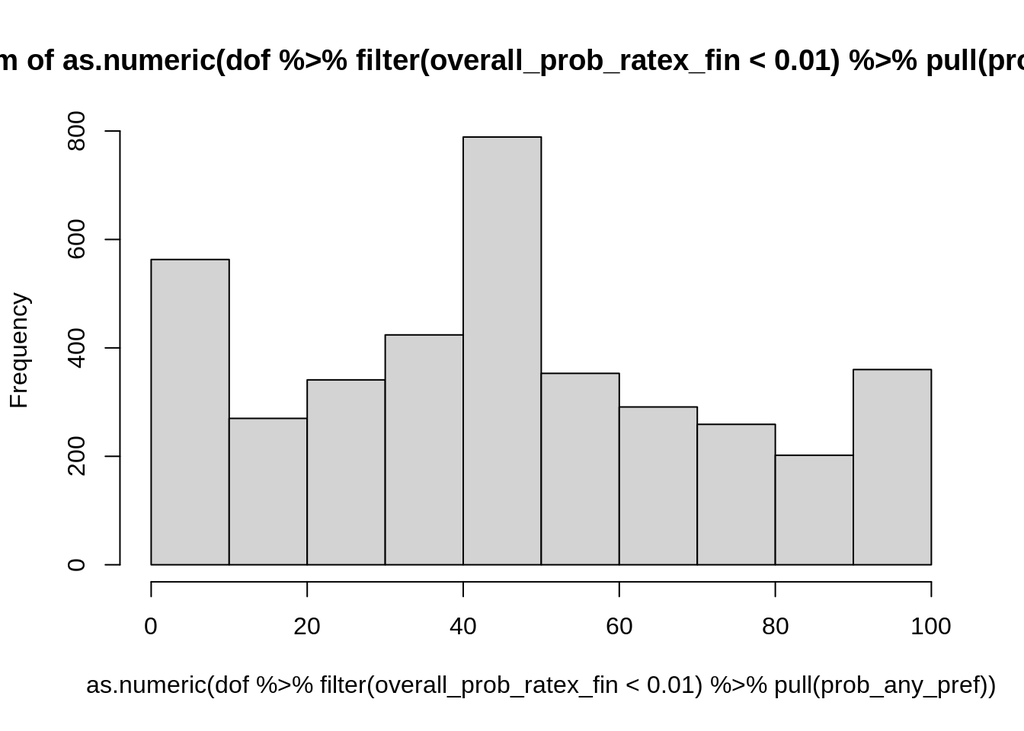

```r
#TODO: we do not find a significant effect on admisibility mistakes perse
# but we do regarding increasing valid applications






#Look into bias for risk
hist(as.numeric(dof %>% filter(overall_prob_ratex_fin < 0.01) %>% pull(prob_any_pref)))
```

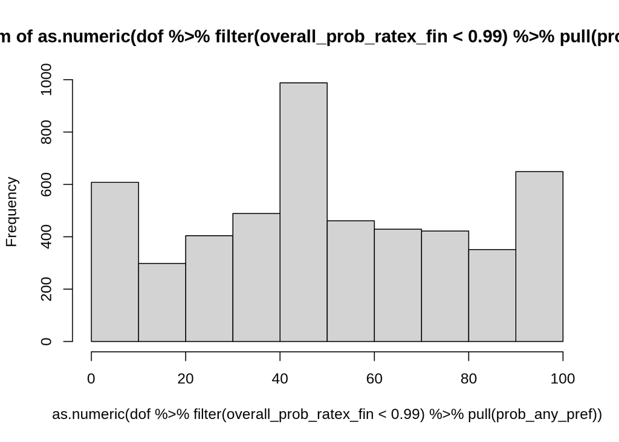

```r
hist(as.numeric(dof  %>% filter(overall_prob_ratex_fin < 0.99) %>% pull(prob_any_pref)))
```

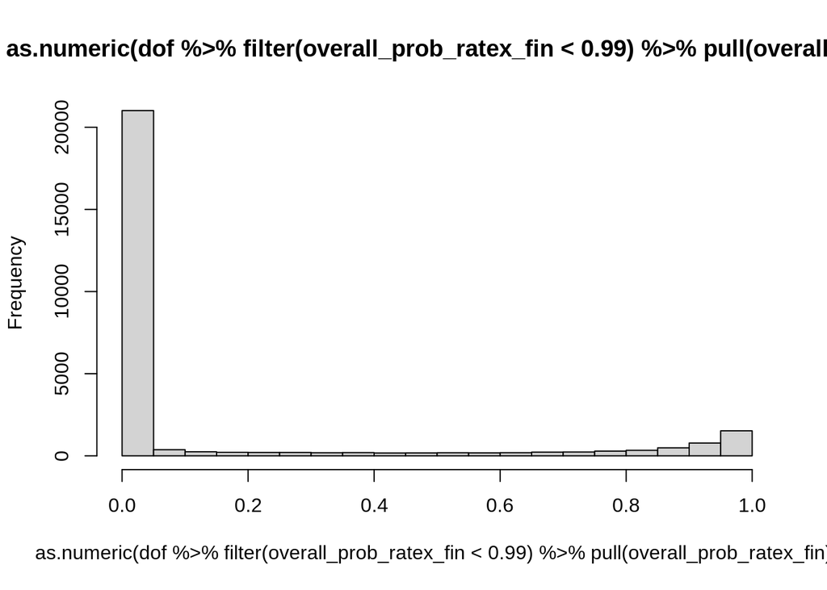

```r
hist(as.numeric(dof  %>% filter(overall_prob_ratex_fin < 0.99) %>% pull(overall_prob_ratex_fin)))
```

```r
#Regresion on reduction of bias in risk
reg_risk_bias <- lm(abs(bias_in_belief_overall_ratex) ~ factor(treatment)  + factor(strata_region) + factor(strata_sexo) + factor(strata_score) + factor(general_message) + gets_sms,
                       #family="binomial",
                      data= dof %>% subset(open==1) %>% mutate(bias_in_belief_risk_ratex_abs_high = ifelse(abs(bias_in_belief_risk_ratex) >= 100, 1, 0)) %>%
                      subset(overall_prob_ratex_fin < 1) %>%
                      filter(misfit==1 & strata_region != 4))
summary(reg_risk_bias)
```

```
##
## Call:
## lm(formula = abs(bias_in_belief_overall_ratex) ~ factor(treatment) +
##     factor(strata_region) + factor(strata_sexo) + factor(strata_score) +
##     factor(general_message) + gets_sms, data = dof %>% subset(open ==
##     1) %>% mutate(bias_in_belief_risk_ratex_abs_high = ifelse(abs(bias_in_belief_risk_ratex) >=
##     100, 1, 0)) %>% subset(overall_prob_ratex_fin < 1) %>% filter(misfit ==
##     1 & strata_region != 4))
##
## Residuals:
##     Min      1Q  Median      3Q     Max
## -52.451 -23.496  -0.618  18.039  73.418
##
## Coefficients:
##                          Estimate Std. Error t value Pr(>|t|)
## (Intercept)               10.5718    20.2057   0.523   0.6009
## factor(treatment)2         2.1672     1.7048   1.271   0.2038
## factor(treatment)3        -2.2034     1.6919  -1.302   0.1929
## factor(treatment)4         2.4599     1.6864   1.459   0.1448
## factor(strata_region)2     1.2179     1.7565   0.693   0.4881
## factor(strata_region)3    -1.5642     1.9233  -0.813   0.4161
## factor(strata_sexo)2       0.6721     1.3807   0.487   0.6264
## factor(strata_score)2      7.6155     1.4571   5.227 1.89e-07 ***
## factor(strata_score)3      4.5345     2.2102   2.052   0.0403 *
## factor(general_message)2  29.9503    20.0485   1.494   0.1353
## factor(general_message)3  15.6547    20.0508   0.781   0.4350
## gets_sms                  -1.0833     1.2359  -0.877   0.3808
## ---
## Signif. codes:  0 '***' 0.001 '**' 0.01 '*' 0.05 '.' 0.1 ' ' 1
##
## Residual standard error: 28.26 on 2237 degrees of freedom
##   (5886 observations deleted due to missingness)
## Multiple R-squared:  0.04967,    Adjusted R-squared:  0.04499
## F-statistic: 10.63 on 11 and 2237 DF,  p-value: < 2.2e-16
```

```r
#TODO: we need to redo this analysis subsetting students who have their
# partial portfolios contained in their final ones, and redo
# the analysis on the bias at the program level (using bias in cutoffs maybe)
# and only for programs in the survey that appear in both portfolios



#Creating table for mistakes
stargazer(reg_underconf, reg_overconf, keep.stat="n",
          add.lines = list(c(2,round(exp(coef(reg_underconf))[2],3), round(exp(coef(reg_overconf))[2],3)),
                           c(3,round(exp(coef(reg_underconf))[3],3), round(exp(coef(reg_overconf))[3],3)),
                           c(4,round(exp(coef(reg_underconf))[4],3), round(exp(coef(reg_overconf))[4],3))), digits=3,
                         out = paste(path_draft_tables,"regs_odds_open_strategic_mistakes.tex", sep=""))
```

```
##
## % Table created by stargazer v.5.2.3 by Marek Hlavac, Social Policy Institute. E-mail: marek.hlavac at gmail.com
## % Date and time: Wed, Jun 29, 2022 - 06:04:30 PM
## \begin{table}[!htbp] \centering
##   \caption{}
##   \label{}
## \begin{tabular}{@{\extracolsep{5pt}}lcc}
## \\[-1.8ex]\hline
## \hline \\[-1.8ex]
##  & \multicolumn{2}{c}{\textit{Dependent variable:}} \\
## \cline{2-3}
## \\[-1.8ex] & not\_applied\_to\_top\_true\_fin\_in\_top\_pref & risk\_ratex\_dec \\
## \\[-1.8ex] & (1) & (2)\\
## \hline \\[-1.8ex]
##  factor(treatment)2 & 0.025 & 0.098 \\
##   & (0.109) & (0.111) \\
##   & & \\
##  factor(treatment)3 & $-$0.260$^{**}$ & 0.226$^{**}$ \\
##   & (0.114) & (0.108) \\
##   & & \\
##  factor(treatment)4 & $-$0.042 & 0.016 \\
##   & (0.110) & (0.113) \\
##   & & \\
##  Constant & $-$1.753$^{***}$ & $-$3.816$^{***}$ \\
##   & (0.076) & (0.081) \\
##   & & \\
## \hline \\[-1.8ex]
## 2 & 1.025 & 1.103 \\
## 3 & 0.771 & 1.254 \\
## 4 & 0.959 & 1.016 \\
## Observations & 5,283 & 29,434 \\
## \hline
## \hline \\[-1.8ex]
## \textit{Note:}  & \multicolumn{2}{r}{$^{*}$p$<$0.1; $^{**}$p$<$0.05; $^{***}$p$<$0.01} \\
## \end{tabular}
## \end{table}
```

```r
#TODO: this table has to be pasted by hand in the paper. It is easy though.
```

```r
kable(dof %>% filter(valid_apps_before < apps_before) %>% group_by(treatment, open) %>% dplyr::summarise(n=n(), ent=mean(entered)*100, lef=mean(left)*100, cs=mean(changed_status_ass)*100, cp=mean(changed_program_ass)*100), digits=3)
```

| treatment | open | n | ent | lef | cs | cp |
| --- | --- | --- | --- | --- | --- | --- |
| 1 | 0 | 5605 | 0.839 | 0.946 | 1.784 | 2.409 |
| 1 | 1 | 1995 | 0.902 | 0.852 | 1.754 | 2.807 |
| 2 | 0 | 5627 | 0.800 | 0.906 | 1.706 | 2.097 |
| 2 | 1 | 2073 | 1.351 | 0.965 | 2.315 | 2.412 |
| 3 | 0 | 5535 | 0.994 | 0.903 | 1.897 | 2.674 |
| 3 | 1 | 2049 | 1.513 | 1.074 | 2.587 | 3.172 |
| 4 | 0 | 5556 | 1.044 | 1.026 | 2.070 | 2.214 |
| 4 | 1 | 2015 | 1.141 | 0.844 | 1.985 | 2.481 |

```r
kable(dof %>% filter(valid_apps_before < apps_before) %>% group_by(treatment, open) %>% dplyr::summarise(n=n(), ent=sd(entered), lef=sd(left), cs=sd(changed_status_ass), cp=sd(changed_program_ass)), digits=3)
```

| treatment | open | n | ent | lef | cs | cp |
| --- | --- | --- | --- | --- | --- | --- |
| 1 | 0 | 5605 | 0.091 | 0.097 | 0.132 | 0.153 |
| 1 | 1 | 1995 | 0.095 | 0.092 | 0.131 | 0.165 |
| 2 | 0 | 5627 | 0.089 | 0.095 | 0.130 | 0.143 |
| 2 | 1 | 2073 | 0.115 | 0.098 | 0.150 | 0.153 |
| 3 | 0 | 5535 | 0.099 | 0.095 | 0.136 | 0.161 |
| 3 | 1 | 2049 | 0.122 | 0.103 | 0.159 | 0.175 |
| 4 | 0 | 5556 | 0.102 | 0.101 | 0.142 | 0.147 |
| 4 | 1 | 2015 | 0.106 | 0.091 | 0.140 | 0.156 |

```r
#Create Latex table by hand
table_summary_stats_by_group = dof %>% filter(valid_apps_before < apps_before) %>% group_by(treatment_label, open_label) %>%
dplyr::summarise(n   = n(),
                 c   = round(mean(changed)*100,3),
                 inc = round(mean(increased_valid)*100,3),
                 dec = round(mean(decreased_valid)*100,3),
                 ent = round(mean(entered)*100,3),
                 lef = round(mean(left)*100,3),
                 cs  = round(mean(changed_status_ass)*100,3),
                 cp  = round(mean(changed_program_ass)*100,3))
table_summary_stats_by_group
```

```
## # A tibble: 8 × 10
## # Groups:   treatment_label [4]
##   treatment_label open_label     n     c   inc   dec   ent   lef    cs    cp
##   <chr>           <chr>      <int> <dbl> <dbl> <dbl> <dbl> <dbl> <dbl> <dbl>
## 1 T1              No          5605  9.35  2.94 1.12  0.839 0.946  1.78  2.41
## 2 T1              Yes         1995 12.4   4.01 1.20  0.902 0.852  1.75  2.81
## 3 T2              No          5627  9.19  2.97 0.835 0.8   0.906  1.71  2.10
## 4 T2              Yes         2073 15.0   3.96 1.50  1.35  0.965  2.32  2.41
## 5 T3              No          5535  9.90  3.50 1.16  0.994 0.903  1.90  2.67
## 6 T3              Yes         2049 13.0   4.00 1.02  1.51  1.07   2.59  3.17
## 7 T4              No          5556  9.20  2.92 1.13  1.04  1.03   2.07  2.21
## 8 T4              Yes         2015 13.2   3.77 1.54  1.14  0.844  1.98  2.48
```